# Adjunctive Vasopressor Selection Decision Model

- Show All Code
- Hide All Code
- View Source

Author

Seth Bauer

Published

2026-10-01

# 1 Overview

The objective of this work is to create a decision model to augment adjunctive vasopressor selection in adults with septic shock. Patient encounters meeting clinical criteria for septic shock, whether Centers for Disease Control and Prevention Adult Sepsis Event (CDC ASE) or Third International Consensus Definition for Sepsis and Septic Shock (Sepsis-3) criteria, were previously identified. We will first divide the cohort of patients with septic shock from the Cleveland Clinic Ohio region into sub-cohorts based on second-line adjunctive vasopressor received (such as vasopressin or epinephrine). Using these sub-cohorts, we will create and calibrate separate treatment-specific clinical prediction models for adjunctive vasopressor response, defined as achievement of a mean arterial pressure (MAP) ≥65 mm Hg and a decrease in norepinephrine-equivalent vasopressor dose at six hours after adjunct response. The models will be derived using candidate predictors of patient characteristics, treatment context factors, and shock characteristics measured at first adjunctive vasopressor initiation. We will build and optimize prediction models within each sub-cohort with regression-based and machine learning algorithms for binary categorical outcomes. The prediction model with the best performance (based on predictive discrimination, calibration, decision curve analysis, and implementation readiness) in each sub-cohort will be considered the final model and carried forward.

We will then define for each patient the decision model-recommended adjunctive vasopressor based on the medication with the highest predicted likelihood of response for a given patient. To validate the model, we will conduct a discordance analysis using patients with septic shock from the Cleveland Clinic Florida region. For each patient, the model-recommended second-line adjunctive vasopressor therapy will be compared against the observed decision made in the standard process of care. Concordance will be defined as a patient given the second-line adjunctive vasopressor consistent with the decision model recommendation. Discordance will be defined as a patient given an adjunctive vasopressor differing from the medication recommended by the decision model. Each patient will be defined as receiving concordant or discordant therapy, creating counterfactual controls for model recommendations. The global effect of discordance will be defined as the odds ratio (estimated with logistic regression) for adjunctive vasopressor response comparing discordant decisions to concordant decisions.

# 2 Load Packages and Setup

```r
knitr::opts_chunk$set(comment = NA)
options(width = 70)

library(broom); library(conflicted); library(DataExplorer); library(dcurves);
library(emmeans); library(fastshap); library(finetune); library(flextable);
library(forester); library(ggalluvial); library(GGally); library(ggdist);
library(ggh4x); library(ggrepel); library(ggsci); library(gt);
library(gtsummary); library(ivs); library(janitor); library(kableExtra);
library(naniar); library(nnet); library(officer);library(patchwork);
library(pmcalibration); library(pmsampsize); library(renv); library(report);
library(riskRegression); library(rms); library(scales); library(shapviz);
library(simputation); library(splines); library(splines2); library(survival);
library(survminer); library(vip); library(vroom); library(tidytext);
library(tidymodels); library(tidyverse)

theme_set(theme_bw())

conflict_prefer("count", "dplyr"); conflict_prefer("select", "dplyr");
conflict_prefer("filter", "dplyr"); conflict_prefer("recode", "dplyr");
conflict_prefer("summarize", "dplyr"); conflict_prefer("min", "base");
conflict_prefer("max", "base"); conflict_prefer("data.frame", "base");
conflict_prefer("sum", "base"); conflict_prefer("mean", "base");
conflict_prefer("describe", "rms"); conflict_prefer("Predict", "rms");
conflict_prefer("font", "flextable"); conflicts_prefer(vip::vi);
tidymodels_prefer()
```

# 3 Load Data

Read in the data from .Rds files created in other Quarto documents. Each source .Rds file utilized multiple input files or queries, which will not be iterated here. See [Bauer 2025](https://link.springer.com/article/10.1186/s13054-025-05749-1) and open source Quarto documents for development of [the patient cohort](https://github.com/ClevelandClinicQHS/sepsis-case-identification-workflow) and an [initial norepinephrine failure prediction model](https://github.com/ClevelandClinicQHS/septic_shock_ne_failure_model), which contain the process steps to build the patient cohorts and .Rds files. Also load a file containing a lookup table of emergency department and hospital characteristics. The data sources for this document are:

| Tibble | File (.Rds) | Source Quarto Document (.qmd) |
| --- | --- | --- |
| ne_incl | ne_failure_included | ne_failure_model |
| pressors_courses | vasopressors_courses_updated | ne_failure_model |
| dbt | vasopressors_courses_dbt | vasopressors |
| pressors_doses | vasopressors_long | vasopressors |
| map | map | cv_sofa |
| hosp_char | Hospital_characteristics.csv | none (raw file) |
| body_weight | weight | weight |
| adt | adt_wide | adt |
| abx | abx_sep3 | antimicrobials |
| surg | surgeries | surgeries |
| encounter_key | encounter_key.txt | none (raw file) |
| map | map | cv_sofa |
| scr | encounter_scr | kidney_function |
| rrt | encounter_rrt | kidney_function |
| esrd | esrd | kidney |
| platelets | plts | platelets |
| bili | bili | bilirubin |
| gcs | sofa_cns | cns_sofa |
| sed | sedatives | sedative_antipsychotic |
| antipsy | antipsychotics | sedative_antipsychotic |
| oxygenation | sofa_resp | resp_sofa-2 |
| mv | vent_all | vent |
| adv_resp_support | adv_resp_support | resp_sofa-2 |
| pH | pH | arterial_pH |
| temperature | temperature | vitals |
| heart_rate | heart_rate | vitals |
| resp_rate | resp_rate | vitals |
| lactate | lactate_all | lactate |
| fluids | fluid_bolus | fluid_bolus |
| steroids | steroids | steroids |
| lvef | lvef | echo_parameters |

Some .Rds files include all observations in the raw queries, but in this work only observations from patients with septic shock receiving norepinephrine as the first vasopressor (among other criteria) are of interest. Therefore, as applicable, the call below filters observations to those from eligible cases. This call also selects vectors (columns) of interest for this work, adjusts vector structure as needed, and drops unused levels of factor variables.

```r
ne_incl <-
  read_rds("/proj/DaltonLab/projects/sbauer/rds_files/ne_failure_included.Rds")

pressors_courses <-
  read_rds("/proj/DaltonLab/projects/sbauer/rds_files/vasopressors_courses_updated.Rds") |>
  filter(encounter_id %in% ne_incl$encounter_id) |>
  droplevels()

dbt <-
  read_rds("/proj/DaltonLab/projects/sbauer/rds_files/vasopressors_courses_dbt.Rds") |>
  filter(encounter_id %in% ne_incl$encounter_id,
         medication == "dobutamine") |>
  droplevels()

pressors_doses <- read_rds(
  "/proj/DaltonLab/projects/sbauer/rds_files/vasopressors_long.Rds"
  ) |>
  filter(encounter_id %in% ne_incl$encounter_id)

map <- read_rds("/proj/DaltonLab/projects/sbauer/rds_files/map.Rds") |>
  filter(encounter_id %in% ne_incl$encounter_id)

body_weight <-
  read_rds("/proj/DaltonLab/projects/sbauer/rds_files/weight.Rds") |>
  filter(encounter_id %in% ne_incl$encounter_id)

adt <- read_rds("/proj/DaltonLab/projects/sbauer/rds_files/adt_wide.Rds") |>
  filter(encounter_id %in% ne_incl$encounter_id) |>
  droplevels()

hosp_char <-
  vroom("/proj/DaltonLab/projects/sbauer/data_raw/full_cohort/Hospital_characteristics.csv",
        col_types = c(hospital = "f", hosp_beds = "f", hosp_beds_cat = "f",
                      hosp_teaching_status = "f", hosp_state = "f"))

abx <- read_rds("/proj/DaltonLab/projects/sbauer/rds_files/abx_sep3.Rds") |>
  filter(encounter_id %in% ne_incl$encounter_id)

surg <-read_rds("/proj/DaltonLab/projects/sbauer/rds_files/surgeries.Rds")

encounter_key <-
  vroom("/proj/DaltonLab/projects/sbauer/data_raw/full_cohort/encounter_key.txt",
        col_types = c(EncounterID = "c")) |>
  clean_names()

scr <-
  read_rds("/proj/DaltonLab/projects/sbauer/rds_files/encounter_scr.Rds") |>
  filter(encounter_id %in% ne_incl$encounter_id)

rrt <-
  read_rds("/proj/DaltonLab/projects/sbauer/rds_files/encounter_rrt.Rds") |>
  filter(encounter_id %in% ne_incl$encounter_id)

esrd <- read_rds("/proj/DaltonLab/projects/sbauer/rds_files/esrd.Rds") |>
  filter(encounter_id %in% ne_incl$encounter_id)

platelets <- read_rds("/proj/DaltonLab/projects/sbauer/rds_files/plts.Rds") |>
  filter(encounter_id %in% ne_incl$encounter_id)

bili <- read_rds("/proj/DaltonLab/projects/sbauer/rds_files/bili.Rds") |>
  filter(encounter_id %in% ne_incl$encounter_id)

gcs <- read_rds("/proj/DaltonLab/projects/sbauer/rds_files/sofa_cns.Rds") |>
  filter(encounter_id %in% ne_incl$encounter_id)

sed <- read_rds("/proj/DaltonLab/projects/sbauer/rds_files/sedatives.Rds") |>
  filter(encounter_id %in% ne_incl$encounter_id)

antipsy <- read_rds("/proj/DaltonLab/projects/sbauer/rds_files/antipsychotics.Rds") |>
  filter(encounter_id %in% ne_incl$encounter_id)

oxygenation <- read_rds("/proj/DaltonLab/projects/sbauer/rds_files/sofa_resp.Rds") |>
  filter(encounter_id %in% ne_incl$encounter_id)

adv_resp <- read_rds("/proj/DaltonLab/projects/sbauer/rds_files/adv_resp_support.Rds") |>
  filter(encounter_id %in% ne_incl$encounter_id) |>
  rename(adv_resp_time = time)

mv <- read_rds("/proj/DaltonLab/projects/sbauer/rds_files/vent_all.Rds") |>
  filter(encounter_id %in% ne_incl$encounter_id) |>
  rename(mv_time = time, mv_date = date)

pH <- read_rds("/proj/DaltonLab/projects/sbauer/rds_files/pH.Rds") |>
  filter(encounter_id %in% ne_incl$encounter_id)

temperature <- read_rds("/proj/DaltonLab/projects/sbauer/rds_files/temperature.Rds") |>
  filter(encounter_id %in% ne_incl$encounter_id)

heart_rate <- read_rds("/proj/DaltonLab/projects/sbauer/rds_files/heart_rate.Rds") |>
  filter(encounter_id %in% ne_incl$encounter_id)

resp_rate <- read_rds("/proj/DaltonLab/projects/sbauer/rds_files/resp_rate.Rds") |>
  filter(encounter_id %in% ne_incl$encounter_id)

lactate <- read_rds("/proj/DaltonLab/projects/sbauer/rds_files/lactate_all.Rds") |>
  filter(encounter_id %in% ne_incl$encounter_id)

fluids <-
  read_rds("/proj/DaltonLab/projects/sbauer/rds_files/fluid_bolus.Rds") |>
  filter(encounter_id %in% ne_incl$encounter_id)

steroids <-
  read_rds("/proj/DaltonLab/projects/sbauer/rds_files/steroids.Rds") |>
  filter(encounter_id %in% ne_incl$encounter_id)

lvef <-
  read_rds("/proj/DaltonLab/projects/sbauer/rds_files/lvef.Rds")
```

# 4 Verify Tibble Structure

Next, check the structure of the imported tibbles to ensure the vectors are in the desired format for modeling. Annotations are only included below if the structure is not in the intended format.

```r
str(ne_incl, vec.len = 0)
```

```
tibble [25,982 × 92] (S3: tbl_df/tbl/data.frame)
 $ encounter_id                     : chr [1:25982]  ...
 $ event                            : num [1:25982] NULL ...
 $ event_type                       : Factor w/ 2 levels "0-no_event","1-failure": NULL ...
 $ surv_hours                       : num [1:25982] NULL ...
 $ any_adj                          : Factor w/ 2 levels "No Adjunct","Adjunct": NULL ...
 $ hours_to_first_adj               : num [1:25982] NULL ...
 $ mort_hosp                        : chr [1:25982]  ...
 $ hours_to_death                   : num [1:25982] NULL ...
 $ pressors_range                   : iv<dttm> [1:25982] [2014-03-26 13:05:00, 2014-03-28 11:34:01...
 $ pressors_dur_hours               : num [1:25982] NULL ...
 $ admission_time                   : POSIXct[1:25982], format:  ...
 $ discharge_time                   : POSIXct[1:25982], format:  ...
 $ criteria_met                     : Factor w/ 3 levels "Both","ASE only",..: NULL ...
 $ age                              : num [1:25982] NULL ...
```

[output cut: 82 more lines]

The variables each have the intended structure, however some factor variables need re-leveled to place the intended baseline (reference) category first. This work will below in section Section 5.1.

```r
str(pressors_courses, vec.len = 0)
```

```
tibble [25,982 × 33] (S3: tbl_df/tbl/data.frame)
 $ encounter_id        : chr [1:25982]  ...
 $ pressors_range      : iv<dttm> [1:25982] [2014-03-26 13:05:00, 2014-03-28 11:34:01...
 $ pressors_dur_hours  : num [1:25982] NULL ...
 $ first_pressor       : Factor w/ 1 level "norepinephrine": NULL ...
 $ multiple_first      : chr [1:25982]  ...
 $ norepinephrine_start: POSIXct[1:25982], format:  ...
 $ vasopressin_start   : POSIXct[1:25982], format:  ...
 $ phenylephrine_start : POSIXct[1:25982], format:  ...
 $ epinephrine_start   : POSIXct[1:25982], format:  ...
 $ dopamine_start      : POSIXct[1:25982], format:  ...
 $ norepinephrine_stop : POSIXct[1:25982], format:  ...
 $ vasopressin_stop    : POSIXct[1:25982], format:  ...
 $ phenylephrine_stop  : POSIXct[1:25982], format:  ...
 $ epinephrine_stop    : POSIXct[1:25982], format:  ...
```

[output cut: 19 more lines]

```r
str(pressors_doses, vec.len = 0)
```

```
tibble [1,735,479 × 14] (S3: tbl_df/tbl/data.frame)
 $ encounter_id               : chr [1:1735479]  ...
 $ mar_taken_time             : POSIXct[1:1735479], format:  ...
 $ medication                 : Factor w/ 5 levels "dopamine","epinephrine",..: NULL ...
 $ titrate_action             : Factor w/ 3 levels "start","stop",..: NULL ...
 $ dose_mcg_min               : num [1:1735479] NULL ...
 $ dose_mcg_kg_min            : num [1:1735479] NULL ...
 $ dose_units_min             : num [1:1735479] NULL ...
 $ wt_kg                      : num [1:1735479] NULL ...
 $ nee_goradia                : num [1:1735479] NULL ...
 $ running_nee_goradia        : num [1:1735479] NULL ...
 $ nee_kotani                 : num [1:1735479] NULL ...
 $ running_nee_kotani         : num [1:1735479] NULL ...
 $ running_nee_goradia_mcg_min: num [1:1735479] NULL ...
 $ running_nee_kotani_mcg_min : num [1:1735479] NULL ...
```

```r
#str(map, vec.len = 0)
```

```r
#str(lactate, vec.len = 0)
```

```r
#str(steroids, vec.len = 0)
```

```r
#str(fluids, vec.len = 0)
```

```r
#str(scr, vec.len = 0)
```

```r
#str(rrt, vec.len = 0)
```

All tibbles have vectors in the structure desired for modeling.

Next, confirm that the `encounter_id`s are the same between `ne_incl` and `pressors_courses` as well as between `ne_incl` and `pressors_doses`.

```r
setequal(ne_incl$encounter_id, pressors_courses$encounter_id)
```

```
[1] TRUE
```

```r
setequal(ne_incl$encounter_id, pressors_doses$encounter_id)
```

```
[1] TRUE
```

# 5 Data Creation

Next, select vectors already in the tibble that will be used for modeling. Then identify and create vectors for exposure risk, covariates, and outcomes that will be used for modeling.

## 5.1 Select Vectors

Create a new tibble (`adj`) filtered to patients in the `ne_incl` tibble who received an adjunctive vasopressor. In the same call, select out columns (vectors) that will not be used for joining data between tibbles or for modeling, change the column ordering, rename one column, drop unused factor levels, and adjust the levels for some categorical variables.

```r
adj <- ne_incl |>
  filter(event_3_level_type == "1-adjunct") |>
  select(-c(event, event_type, surv_hours, any_adj, surv_obj,
            surv_hours_3_level, hours_to_death, wt_time, wt_kg, prior_abx,
            mv_before_shock, surg_service_30d_prior_to_dc, prior_surg_service,
            shock_onset_minus_6h, shock_onset_minus_12h, shock_onset_minus_24h,
            event_3_level, event_3_level_type
            )
         ) |>
  rename(sepsis_onset_tot_sofa = tot_sofa) |>
  droplevels() |>
  mutate(criteria_met = fct_relevel(criteria_met, "Both", "ASE only"),
         race_eth = fct_recode(race_eth,
                               "Other, non-Hispanic" = "Asian",
                               "Black, non-Hispanic" = "Black",
                               "Hispanic or Latino" = "Hispanic or Latino",
                               "Multiracial, non-Hispanic" = "Multiracial",
                               "Other, non-Hispanic" = "Other",
                               "White, non-Hispanic" = "White"),
         race_eth = fct_relevel(race_eth,
                               "Black, non-Hispanic",
                               "Hispanic or Latino",
                               "Multiracial, non-Hispanic",
                               "Other, non-Hispanic",
                               "White, non-Hispanic"
                               ),
         shock_onset_hosp_beds_cat =
           fct_relevel(shock_onset_hosp_beds_cat, "≥500", "200-499"),
         shock_onset_hosp_teaching_status =
           fct_relevel(shock_onset_hosp_teaching_status, "Non-teaching"),
         shock_onset_tx_unit =
           fct_relevel(shock_onset_tx_unit, "Medical/Cardiac ICU"),
         ssc_era = fct_relevel(ssc_era, "SSC 2021")
         )
```

Now check the vector names in the `adj` tibble to confirm expectations are met.

```r
names(adj)
```

[output not shown]

[output cut: 59 more lines]

The retained columns (vectors) are consistent with expectations.

## 5.2 Outcome: Adjunctive Vasopressor Response

The outcome of interest will be adjunctive vasopressor blood pressure response, defined as achieving MAP ≥65 mm Hg with a decrease from baseline in norepinephrine dosage at 6 hours after first adjunctive vasopressor initiation.

- The outcome will only be adjudicated for the first adjunctive agent (the “second-line” vasopressor).
- Patients with an unavailable (missing) MAP value at 6 hours (or within the 3 hours preceding [missing MAP in hours 3-6 after adjunct start]) will be adjudicated as not meeting response criteria. The impact of this component of the criteria will be explored.
- Because additional (“third-line”, etc.) adjunctive vasopressors may be initiated within the 6 hour window period, the norepinephrine-equivalent (NEQ) dose at 6 hours will be utilized instead of solely the norepinephrine dose. The NEQ will be based on the Kotani equivalence equation ([Kotani 2023](https://pubmed.ncbi.nlm.nih.gov/36670410/)).

The outcome adjudication will be operationalized as follows.

1. Join closest MAP (and within 3 hours) to the `pressors_doses` tibble for each dose titration. This value will be used for the adjudication of the MAP value at 6 hours after adjunct start. Joining the MAP in this way will have two added advantages: a) availability of closest MAP at adjunct start (which will be identified in a subsequent section for use as a predictor), and b) allow for calculation of the ratio of MAP to norepinephrine-equivalent dose (MAP/NEQ) for each dose, which will be added at the end of the call for potential future use.

```r
pressors_doses <- pressors_doses |>
  mutate(mar_taken_minus_3h = mar_taken_time - dhours(3)) |>
  left_join(map |>
              # Filter MAP values to plausible range for patient in shock
              filter(map >=15 & map <=120) |>
              select(encounter_id, map_time, map) |>
              # Arrange to have the higher MAP from invasive and non-invasive
              # devices that were taken at the exact same time
              arrange(encounter_id, map_time, desc(map)) |>
              distinct(encounter_id, map_time, .keep_all = TRUE),
            by = join_by(encounter_id,
                         closest(mar_taken_time >= map_time),
                         mar_taken_minus_3h <= map_time
                         ),
            relationship = "many-to-one"
            ) |>
  rename(closest_map_time = map_time,
         closest_map = map) |>
  mutate(map_neq_goradia = if_else(running_nee_kotani != 0 &
                                     !is.na(closest_map),
                                   closest_map / running_nee_goradia,
                                   NA
                                   ),
         map_neq_kotani = if_else(running_nee_kotani != 0 &
                                     !is.na(closest_map),
                                  closest_map / running_nee_kotani,
                                  NA
                                  )
         )

# Remove `map` tibble since it won't be used moving forward
rm(map)
```

2. Determine the date/time of the first adjunctive vasopressor start (`first_adj_time`) in the `pressors_courses` tibble and join this vector to the `adj` tibble.

```r
pressors_courses <- pressors_courses |>
  mutate(first_adj_time = as.POSIXct(case_when(
    first_adj == "vasopressin" ~ vasopressin_start,
    first_adj == "epinephrine" ~ epinephrine_start,
    first_adj == "phenylephrine" ~ phenylephrine_start,
    first_adj == "dopamine" ~ dopamine_start,
    first_adj == "AVP + Epi" ~ vasopressin_start,
    first_adj == "AVP + PE" ~ vasopressin_start,
    first_adj == "Epi + PE" ~ epinephrine_start,
    first_adj == "AVP + DA" ~ vasopressin_start,
    first_adj == "AVP + Epi + PE" ~ vasopressin_start,
    first_adj == "Epi + DA" ~ epinephrine_start,
    is.na(first_adj) ~ NA,
    # Create "error" date/time to ensure all options captured in coding
    .default = as.POSIXct(1900-01-01)
    )))
```

Ensure coding didn’t result in any error date/time

```r
sum(pressors_courses$first_adj_time == as.POSIXct(1900-01-01), na.rm = TRUE)
```

```
[1] 0
```

No error resulted, therefore continue with the join.

```r
adj <- adj |>
  left_join(pressors_courses |> select(encounter_id, first_adj_time),
            by = join_by(encounter_id),
            relationship = "one-to-one"
            ) |>
  relocate(c(first_adj_time, first_adj, hours_to_first_adj),
           .after = encounter_id
           )
```

3. To the `adj` tibble, join from the `pressors_doses` tibble the closest NEQ dose before the time of first adjunct start (but not before or equal to the time of first adjunct start because the NEQ at the time equal to the first adjunct start includes the initial adjunct dose). While this baseline value only includes the norepinephrine dosage, this will be called `adj_baseline_neq` for clarity. Also join the NEQ with units of mcg/min and the MAP/NEQ for completeness. These values will not be used other than for description of the cohort of included patients.

```r
adj <- adj |>
  left_join(pressors_doses |>
              select(encounter_id, mar_taken_time, running_nee_kotani,
                     running_nee_kotani_mcg_min, map_neq_kotani
                     ) |>
              distinct(),
            by = join_by(encounter_id,
                         closest(first_adj_time > mar_taken_time)
                         ),
            relationship = "one-to-one"
            ) |>
  select(-mar_taken_time) |>
  rename(adj_baseline_neq = running_nee_kotani,
         adj_baseline_neq_mcg_min = running_nee_kotani_mcg_min,
         adj_baseline_map_neq = map_neq_kotani) |>
  relocate(adj_baseline_neq, .after = hours_to_first_adj)
```

Confirm no missing values for `adj_baseline_neq`.

```r
sum(is.na(adj$adj_baseline_neq))
```

```
[1] 0
```

There are no missing values.

Review random sample of all cases to ensure expectations met (commented out for rendering).

```r
set.seed(2026)
df <- adj |>
  select(encounter_id, first_adj, first_adj_time, adj_baseline_neq) |>
  slice_sample(n=10)
#View(df |> arrange(encounter_id))
#View(pressors_doses |> filter(encounter_id %in% df$encounter_id) |>
#       select(encounter_id, mar_taken_time, medication, titrate_action,
#              running_nee_kotani
#              ) |>
#       arrange(encounter_id)
#     )
rm(df)
```

Expectations are met, therefore continue.

Assess if any values of `adj_baseline_neq` are zero (doses must be greater than zero to indicate adjunctive vasopressor use).

```r
sum(adj$adj_baseline_neq == 0)
```

```
[1] 369
```

There are 369 cases where the norepinephrine dosage documented immediately before adjunct initiation was zero. Review some of these cases to determine if there is an issue with the joining process or if they indicate true cessations of norepinephrine (commented out for rendering purposes).

```r
df <- adj |> filter(adj_baseline_neq == 0) |> head(n=10)
#View(df)
#View(pressors_doses |> filter(encounter_id %in% df$encounter_id))
rm(df)
```

In the manual review most norepinephrine doses were truly documented as zero immediately prior to first “adjunct” vasopressor initiation. These cases should be subsequently excluded because they do not represent adjunctive vasopressor usage: the start of the non-norepinephrine vasopressor represents monotherapy with that medication.

There was one case, though, in the manual review that had a norepinephrine dosage of zero immediately preceding the adjunct start but at the same time of adjunct start there was a non-zero norepinephrine dosage documented. To account for these cases join the norepinephrine dosage at the exact time of first adjunct start, then replace the `adj_baseline_neq` dose of zero with the norepinephrine dosage at the exact time of first adjunct start. Also join `adj_baseline_neq_mcg_min` and calculate `adj_baseline_map_neq` for these cases with the alternative join criteria.

```r
adj <- adj |>
  left_join(pressors_doses |>
              filter(medication == "norepinephrine") |>
              select(encounter_id, mar_taken_time, nee_kotani, closest_map,
                     dose_mcg_min) |>
              distinct(),
            by = join_by(encounter_id,
                         first_adj_time == mar_taken_time
                         ),
            relationship = "one-to-one"
            ) |>
  mutate(adj_baseline_neq = if_else(adj_baseline_neq == 0 & !is.na(nee_kotani),
                                    nee_kotani,
                                    adj_baseline_neq
                                    ),
         adj_baseline_neq_mcg_min = if_else(adj_baseline_neq == 0 &
                                              !is.na(dose_mcg_min) &
                                              dose_mcg_min != 0,
                                    dose_mcg_min,
                                    adj_baseline_neq_mcg_min
                                    ),
         adj_baseline_map_neq = if_else(is.na(adj_baseline_map_neq) &
                                          !is.na(nee_kotani) &
                                          nee_kotani != 0 &
                                          !is.na(closest_map),
                                        closest_map / nee_kotani,
                                        adj_baseline_map_neq
                                        )
         ) |>
  select(-c(nee_kotani, closest_map))

sum(adj$adj_baseline_neq == 0)
```

```
[1] 313
```

```r
sum(adj$adj_baseline_neq_mcg_min == 0, na.rm = TRUE)
```

```
[1] 268
```

```r
nrow(adj |> filter(is.na(adj_baseline_map_neq)))
```

```
[1] 686
```

4. To the `adj` tibble, join from the `pressors_doses` tibble the NEQ and MAP values from the time closest to 6 hours after first adjunct start (and also equal to or after initiation of the first adjunct). Also join the MAP/NEQ for completeness. Only joining values after initiation of the first adjunct (not equal to) was considered, but since an adjunct contributes to the NEQ, if there are no subsequent NEQ values documented then non-response should be adjudicated.

```r
adj <-
  left_join(adj |>
              mutate(first_adj_plus_6h = first_adj_time + dhours(6)),
            pressors_doses |>
              select(encounter_id, mar_taken_time,
                     running_nee_kotani, closest_map, map_neq_kotani
                     ) |>
              distinct(),
            by = join_by(encounter_id,
                         closest(first_adj_plus_6h >= mar_taken_time),
                         first_adj_time <= mar_taken_time
                         ),
            relationship = "one-to-one"
            ) |>
  select(-mar_taken_time) |>
  rename(adj_plus6h_neq = running_nee_kotani,
         adj_plus6h_map = closest_map,
         adj_plus6h_map_neq = map_neq_kotani
         ) |>
  relocate(c(adj_plus6h_neq, adj_plus6h_map), .after = adj_baseline_neq)
```

Check for missing values from the join.

```r
sum(is.na(adj$adj_plus6h_neq))
```

```
[1] 0
```

```r
paste0(round_half_up((sum(is.na(adj$adj_plus6h_neq))/nrow(adj))*100,0),"%")
```

```
[1] "0%"
```

```r
sum(is.na(adj$adj_plus6h_map))
```

```
[1] 283
```

```r
paste0(round_half_up((sum(is.na(adj$adj_plus6h_map))/nrow(adj))*100,0),"%")
```

```
[1] "3%"
```

5. Lastly, determine first adjunctive vasopressor response criteria as being met if MAP ≥65 mm hg at 6 hours after first adjunct start (`adj_plus6h_map`) **and** NEQ at 6 hours after first adjunct start (`adj_plus6h_neq`) is < baseline NEQ (`adj_baseline_neq`).
   - If `death_time` prior to baseline time plus 6 hours then adjudicate as not meeting criteria (death before 6 hours == non-response)
   - If NEQ at 6 hours is the same or higher than baseline NEQ then adjudicate as not meeting criteria. Notably, initiation of additional adjunctive vasopressors (third-line, etc.) between first adjunct start and 6 hours after first adjunct start are accounted for through the contribution of their doses to the NEQ component.
   - If MAP <65 mm Hg at 6 hours then adjudicate as not meeting criteria
   - If NEQ or MAP at 6 hours is missing then adjudicate as not meeting criteria (no evidence of lower NEQ or MAP at goal)
   - Response criteria met if MAP ≥65 mm Hg at 6 hours *and* NEQ at 6 hours is lower than baseline NEQ

```r
adj <- adj |>
  mutate(
    response_type = factor(case_when(
      !is.na(death_time) & death_time <= first_adj_plus_6h ~ "0-no_resp_death",
      adj_plus6h_neq >= adj_baseline_neq ~ "0-no_resp_neq_same_or_higher",
      adj_plus6h_map < 65 ~ "0-no_resp_map_below_65",
      is.na(adj_plus6h_neq) ~ "2-resp_unclear_neq_missing",
      is.na(adj_plus6h_map) ~ "2-resp_unclear_map_missing",
      adj_plus6h_map >= 65 & adj_plus6h_neq < adj_baseline_neq ~ "1-response",
      .default = "Error"),
      levels = c("1-response", "0-no_resp_neq_same_or_higher",
                 "0-no_resp_map_below_65", "0-no_resp_death",
                 "2-resp_unclear_neq_missing", "2-resp_unclear_map_missing"
                 )
      ),
    response = factor(if_else(response_type == "1-response",
                              "Response",
                              "No Response"),
                      # Ensure level ordering is correct for modeling
                      levels = c("No Response", "Response")
      )
    )
```

Show levels of `response_type`, which also serves as a check to ensure all scenarios are accounted for (no “Error” appears).

```r
adj |> tabyl(response_type) |> adorn_totals() |> adorn_pct_formatting()
```

```
                response_type    n percent
                   1-response 2785   31.9%
 0-no_resp_neq_same_or_higher 5097   58.4%
       0-no_resp_map_below_65  540    6.2%
              0-no_resp_death  247    2.8%
   2-resp_unclear_neq_missing    0    0.0%
   2-resp_unclear_map_missing   58    0.7%
                        Total 8727  100.0%
```

First, no “Error” appears, therefore the code worked as intended.

Second, the incidence of response (32%) is lower than in our previous work with vasopressin alone (40%) but is reasonably close. The difference is explainable because patients and criteria in the previous work were slightly different - in this work all patients received initial norepinephrine (previously all initial vasopressors were included), death between first adjunct start and 6 hours later was considered non-response (not considered in prior work), the vasopressor contribution of vasopressin (equated through the Kotani norepinephrine-equivalent dose [NEQ]) was considered in the response criteria (previously it was ignored), and the NEQ was required to be lower than baseline (not lower or equal to baseline since the vasopressin NEQ contribution was considered). Inclusion of the vasopressor contribution of vasopressin as part of the NEQ is likely the largest driver of the difference in response incidence between studies.

Third, only 58 observations (0.7%) were adjudicated as not meeting response criteria because a MAP value in the 3 to 6 hour period after first adjunct start was unavailable. If the alternative approach where missing MAP values are ignored (considered as meeting response because no evidence MAP was below goal) were to be utilized then the frequency of response would not change in a meaningful way (<1% difference). Therefore, will continue with the approach of considering missing MAP values as criteria not being met.

## 5.3 Patient Descriptors and Candidate Predictors

This sub-section will create and join case eligibility criteria and patient characteristics, some of which are candidate predictors of interest.

### 5.3.1 Biological and Context Characteristics

Some of the covariates (predictors) of interest are in the `adj` tibble already, but some additional covariates of interest need to be joined from other loaded tibbles.

#### 5.3.1.1 Body Weight

Join body weight at first adjunct start from the `body_weight` tibble.

```r
adj <- left_join(
  adj,
  body_weight |> select(encounter_id, wt_time, wt_kg) |> distinct(),
  by = join_by(encounter_id,
               closest(first_adj_time >= wt_time)
               ),
  relationship = "one-to-one"
  ) |>
  select(-wt_time) |>
  rename(first_adj_wt_kg = wt_kg)

# Remove `body_weight` tibble because it won't be used moving forward
rm(body_weight)
```

#### 5.3.1.2 Treatment Unit

Join treatment unit (department), service, and ICU type (if applicable) at first adjunct start based on admission/discharge/transfer (ADT) data in the `adt` tibble.

```r
adj <- adj |>
  left_join(adt |> select(encounter_id, in_effective_time, out_effective_time,
                first_adj_hospital = hospital,
                first_adj_department_name = department_name,
                first_adj_hospital_service = hospital_service,
                first_adj_icu_group = icu_group,
                first_adj_unit_type = unit_type),
            join_by(encounter_id,
                    closest(first_adj_time >= in_effective_time),
                    first_adj_time <= out_effective_time),
            relationship = "one-to-one") |>
            mutate(first_adj_unit_type = fct_relevel(first_adj_unit_type,
                                                     "ED", "Ward", "ICU")) |>
  select(-in_effective_time, -out_effective_time)
```

There are some observations with first adjunct start time occurring between unit-specific admission and discharge times in the `adt` tibble due to inconsistency in manual time stamps or back-dated documentation during transport between units. This results in some observations having NA for the characteristics because the join criteria are not met. The call below counts the number of observations having NA for the `first_adj_hospital` vector (as a representative example).

```r
sum(is.na(adj$first_adj_hospital))
```

```
[1] 10
```

There are 10 observations (patients) with missing `first_adj_hospital`. The call below replaces these NA values with the characteristics from the treatment unit preceding the `first_adj_time`.

```r
adj <- adj |>
  left_join(adt |>
              select(encounter_id, in_effective_time, out_effective_time,
                hospital, department_name, hospital_service, icu_group,
                unit_type),
            join_by(encounter_id,
                    closest(first_adj_time > out_effective_time)),
            relationship = "one-to-many") |>
  arrange(encounter_id, first_adj_time, desc(out_effective_time)) |>
  distinct(encounter_id, .keep_all = TRUE) |>
  mutate(first_adj_hospital =
           coalesce(first_adj_hospital, hospital),
         first_adj_department_name =
           coalesce(first_adj_department_name, department_name),
         first_adj_hospital_service =
           coalesce(first_adj_hospital_service, hospital_service),
         first_adj_icu_group = coalesce(first_adj_icu_group, icu_group),
         first_adj_unit_type = coalesce(first_adj_unit_type, unit_type)) |>
  select(-c(in_effective_time, out_effective_time, hospital, department_name,
            hospital_service, icu_group, unit_type))

# Remove `adt` tibble since it won't be used moving forward
rm(adt)
```

Join hospital characteristics.

```r
adj <- adj |>
  left_join(hosp_char |> select(hospital, hosp_beds_cat, hosp_teaching_status,
                                hosp_state),
            by = join_by(first_adj_hospital == hospital),
            relationship = "many-to-one"
  ) |>
  rename(first_adj_hosp_beds_cat = hosp_beds_cat,
         first_adj_hosp_teaching_status = hosp_teaching_status,
         first_adj_hosp_state = hosp_state
  ) |>
  relocate(c(first_adj_hosp_beds_cat, first_adj_hosp_teaching_status,
             first_adj_hosp_state
             ),
           .after = first_adj_hospital)

# Remove `hosp_char` tibble since it won't be used moving forward
rm(hosp_char)
```

The `adj` tibble now has a vector for the treatment location at the time of first adjunct start (`first_adj_unit_type`) but this is too broad of a categorization. Contrastingly, the `first_adj_icu_group` vector for ICU designations is too granular for external applicability. Therefore a new vector (`first_adj_tx_unit`) will be created that combines information from these vectors to generate categories.

```r
adj <- adj |> mutate(first_adj_tx_unit = factor(case_when(
  first_adj_unit_type == "ED" | first_adj_unit_type == "Ward" ~ "ED/Rapid Response",
  first_adj_unit_type == "ICU" &
    grepl("MICU", first_adj_icu_group) ~ "Medical ICU",
  first_adj_unit_type == "ICU" &
    grepl("CCU", first_adj_icu_group) ~ "Cardiac ICU",
  first_adj_unit_type == "ICU" &
    grepl("SICU|CVICU", first_adj_icu_group) ~ "Surgical ICU",
  first_adj_unit_type == "ICU" ~ "Mixed Med/Surg ICU",
  .default = NA
  )))
```

Now show the distribution of values to ensure expectations are met.

```r
adj |> tabyl(first_adj_tx_unit) |> adorn_pct_formatting() |>
  adorn_totals() |>
  rename("First Adjunct Start Treatment Unit" = "first_adj_tx_unit") |>
  kable(align = c('lcc')) |>
  kable_paper(full_width = FALSE)
```

| First Adjunct Start Treatment Unit | n | percent |
| --- | --- | --- |
| Cardiac ICU | 779 | 8.9% |
| ED/Rapid Response | 617 | 7.1% |
| Medical ICU | 2957 | 33.9% |
| Mixed Med/Surg ICU | 2284 | 26.2% |
| Surgical ICU | 2090 | 23.9% |
| Total | 8727 | - |

### 5.3.2 Adjunct Start Characteristics

Transform variables at the time of first adjunctive vasopressor start (baseline).

#### 5.3.2.1 Antimicrobials

Antimicrobial administration within the 24 hours prior to first adjunct start. This will be adjudicated based on the `abx_range_start` and `abx_range_end` variables in the `abx` tibble. Antibiotic start must be prior to first adjunct start and the last dose of antibiotics as part of the course must be given within 24 hours prior to first adjunct start. This will account for antibiotic courses that are “ongoing” at first adjunct start.

```r
adj <-
  left_join(
    adj |> mutate(first_adj_minus_24h = first_adj_time - dhours(24)),
    abx |> select(encounter_id, abx_range_start, abx_range_end),
    join_by(encounter_id,
            closest(first_adj_time >= abx_range_start),
            first_adj_minus_24h <= abx_range_end),
    relationship = "one-to-many") |>
  distinct(encounter_id, .keep_all = TRUE) |>
  mutate(first_adj_abx = factor(if_else(!is.na(abx_range_start),
                                     "Antibiotics", "No Antibiotics"
                                     ))) |>
  arrange(encounter_id, admission_time) |>
  select(-c(abx_range_start, abx_range_end, first_adj_minus_24h))

# Remove `abx` tibble because it won't be used moving forward
rm(abx)
```

#### 5.3.2.2 Surgery

First, join the `patient_id` identifier from the `encounter_key` tibble to the `adj` tibble.

```r
adj <- adj |>
  left_join(encounter_key |> select(episode_key, patient_id),
            join_by(encounter_id == episode_key),
            relationship = "one-to-many") |>
  distinct(encounter_id, .keep_all = TRUE)
```

Next adjudicate surgery within the 30 days prior to adjunct start.

```r
adj <-
  left_join(
    adj |> mutate(first_adj_minus_30d = first_adj_time - ddays(30)),
    surg |> select(patient_id, surgery_start_time),
    join_by(patient_id,
            first_adj_minus_30d <= surgery_start_time,
            first_adj_time >= surgery_start_time),
    relationship = "many-to-many") |>
  arrange(encounter_id, surgery_start_time) |>
  distinct(encounter_id, .keep_all = TRUE) |>
  mutate(prior_surg = factor(if_else(!is.na(surgery_start_time),
                                     "Surgery", "No Surgery"
                                     ))) |>
  arrange(encounter_id, admission_time) |>
  select(-surgery_start_time, -first_adj_minus_30d)
# Remove tibbles that won't be used moving forward
rm(surg, encounter_key)
```

#### 5.3.2.3 Acute Kidney Injury

Acute kidney injury (AKI) will be defined and staged per the [KDIGO 2012 criteria](https://kdigo.org/wp-content/uploads/2016/10/KDIGO-2012-AKI-Guideline-English.pdf). The urine output component will be omitted due to the lack of reliable data collection in hospitalized patients [Alrawashdeh 2024](https://journals.lww.com/ccmjournal/abstract/2024/09000/the_impact_of_common_variations_in_sequential.6.aspx).

AKI will be staged as follows:

- Stage 1: Serum creatinine (SCr) 1.5-1.9 times baseline OR ≥0.3 mg/dL increase from baseline
- Stage 2: SCr 2.0-2.9 times baseline
- Stage 3: SCr ≥3.0 times baseline OR increase in SCr to ≥4.0 mg/dL OR (new) initiation of renal replacement therapy

Baseline SCr will be determined as follows ([Hoste 2015](https://link.springer.com/article/10.1007/S00134-015-3934-7), [Alfieri 2023](https://doi.org/10.1371/journal.pone.0287398)):

- Median pre-morbid value from the 3 months prior to encounter/admission
- If pre-morbid SCr not available, minimum value during the encounter observed prior to first adjunct start

Patients with end-stage kidney disease (ESKD) or renal replacement therapy prior to admission will be adjudicated as **not** meeting criteria for Stage 3 AKI.

Retain only SCr values obtained prior to first adjunct start. Then determined baseline SCr value based on criteria above. The work to determine pre-morbid SCr value (`pta_scr`) in the `scr` tibble was done in the `kidney_function.qmd` Quarto document.

```r
scr <-
  left_join(scr,
            adj |> select(encounter_id, first_adj_time),
            by = join_by(encounter_id),
            relationship = "many-to-one"
            ) |>
  mutate(scr_before_adj =
           if_else(scr_taken_time <= first_adj_time, "Yes", "No")
         ) |>
  filter(scr_before_adj == "Yes") |>
  select(-scr_before_adj) |>
  group_by(encounter_id) |>
  mutate(min_scr_before_adj = min(scr_result)) |>
  ungroup() |>
  mutate(baseline_scr = case_when(
    !is.na(pta_scr) ~ pta_scr,
    !is.na(min_scr_before_adj) ~ min_scr_before_adj,
    .default = NA
    ))
```

Join pertinent values from `scr` to `adj` tibble (notably, only join the closest SCr value obtained before first adjunct start).

```r
adj <-
  left_join(adj,
            scr |> select(encounter_id, scr_taken_time, scr_result,
                          baseline_scr
                          ) |>
              distinct(encounter_id, scr_taken_time, .keep_all = TRUE),
            by = join_by(encounter_id,
                         closest(first_adj_time >= scr_taken_time)),
            relationship = "one-to-one"
            )
rm(scr) # Remove `scr` tibble because it won't be used moving forward
```

Determine renal replacement therapy (RRT) before first adjunct start. The work to determine new RRT (`new_rrt`) in the `rrt` tibble was done in the `kidney_function.qmd` Quarto document.

```r
rrt_before_adj <-
  left_join(rrt,
            adj |> select(encounter_id, first_adj_time),
            by = join_by(encounter_id),
            relationship = "many-to-one") |>
  mutate(rrt_before_adj =
           if_else(rrt_taken_time <= first_adj_time, "Yes", "No")
         ) |>
  filter(rrt_before_adj == "Yes") |>
  select(-c(rrt_before_adj))

rrt_before_adj_new <- rrt_before_adj |>
  filter(new_rrt == "Yes")
```

Create variables for RRT before adjunct (`rrt_before_adj`) and new RRT before adjunct (`new_rrt_before_adj`) within the `adj` tibble.

```r
adj <- adj |>
  mutate(rrt_before_adj = factor(
           if_else(encounter_id %in% rrt_before_adj$encounter_id,
                   "RRT Before Adjunct", "No RRT Before Adjunct"
                   )),
         new_rrt_before_adj =
           if_else(encounter_id %in% rrt_before_adj_new$encounter_id,
                   "Yes", "No"
                   )
         )
# Remove `rrt_before_adj`, `new_rrt_before_adj`, and `rrt` tibbles because
# they won't be used moving forward
rm(rrt_before_adj, rrt_before_adj_new, rrt)
```

Now that all necessary variables are available, determine AKI presence and stage in the `adj` tibble. Data for administrative coding for ESKD was managed in the `kidney.qmd` Quarto document.

```r
adj <- adj |>
  mutate(aki = factor(case_when(
    encounter_id %in% esrd$encounter_id ~ "ESKD",
    scr_result / baseline_scr >= 3 |
      scr_result >=4 |
      new_rrt_before_adj == "Yes" ~ "AKI Stage 3",
    (scr_result / baseline_scr >= 2) &
      (scr_result / baseline_scr < 3) ~ "AKI Stage 2",
    (scr_result / baseline_scr >= 1.5) &
      (scr_result / baseline_scr < 2) |
      scr_result - baseline_scr >= 0.3 ~ "AKI Stage 1",
    is.na(scr_result) ~ NA,
    .default = "No AKI"
     ))) |>
  mutate(aki = fct_relevel(aki, "No AKI")) |>
  rename(first_adj_aki = aki)
rm(esrd) # Remove `esrd` tibble because it won't be used moving forward
```

Show table of AKI staging. NA values are expected due to instances when an SCr value (`src_result`) is not available before first adjunct start.

```r
adj |> tabyl(first_adj_aki) |>
  adorn_pct_formatting() |>
  adorn_totals() |>
  rename("Acute Kidney Injury Stage" = "first_adj_aki") |>
  kable(align = c('lcc')) |>
  kable_paper(full_width = FALSE)
```

| Acute Kidney Injury Stage | n | percent | valid_percent |
| --- | --- | --- | --- |
| No AKI | 3842 | 44.0% | 44.7% |
| AKI Stage 1 | 1780 | 20.4% | 20.7% |
| AKI Stage 2 | 823 | 9.4% | 9.6% |
| AKI Stage 3 | 1621 | 18.6% | 18.8% |
| ESKD | 537 | 6.2% | 6.2% |
| NA | 124 | 1.4% | - |
| Total | 8727 | - | - |

The code worked as intended and the counts align with expectations.

Retain only SCr values collected within 24 hours of first adjunct start (SCr values collected before first adjunct start were ensured in an above step).

```r
adj <- adj |>
  mutate(first_adj_minus_24h = first_adj_time - dhours(24),
         first_adj_scr =
           if_else(scr_taken_time >= first_adj_minus_24h, scr_result, NA)
         ) |>
  # Remove variables that won't be used moving forward
  select(-c(scr_taken_time, scr_result, baseline_scr, new_rrt_before_adj))
```

#### 5.3.2.4 SOFA-2 Components and Calculation

In this section join components of and calculate the Sequential Organ Failure Assessment (SOFA)-2 score [Ranzani, JAMA 2025](https://pubmed.ncbi.nlm.nih.gov/41159833/). The SOFA-2 includes six organ systems each scored from 0 to 4 points, with a total score ranging from 0 to 24 (higher scores indicate worse organ dysfunction).

##### 5.3.2.4.1 Brain

The Brain score centers on the Glasgow Coma Scale (GCS) score but includes a clause “For sedated patients, use the last recorded GCS before sedation. If the previous GCS is unknown, score 0”. Therefore sedative medication medication administration must be considered when joining the GCS value.

Join sedative medication administration (from the `sed` tibble) within the preceding 6 hours of the GCS value to the `gcs` tibble. Sedatives included in the `sed` tibble are dexmedetomidine, diazepam, fentanyl, hydromorphone, ketamine, lorazepam, midazolam, and propofol administered via any non-epidural route. The 6 hours duration preceding the GCS value was based on an approximation of the duration of these medications (recognizing some medications have a shorter duration).

```r
gcs <- left_join(gcs |>
                  select(encounter_id, gcs_taken_time, gcs) |>
                  arrange(encounter_id, gcs_taken_time, gcs) |>
                  distinct(encounter_id, gcs_taken_time, .keep_all = TRUE) |>
                  mutate(gcs_minus_6h = gcs_taken_time - dhours(6)),
                sed |> select(encounter_id, sed_taken_time = mar_taken_time),
                by = join_by(encounter_id,
                             closest(gcs_taken_time >= sed_taken_time),
                             gcs_minus_6h <= sed_taken_time
                             ),
                relationship = "many-to-many"
                ) |>
  mutate(sed_prev_6h = if_else(!is.na(sed_taken_time), 1, 0)) |>
  arrange(encounter_id, gcs_taken_time, desc(sed_prev_6h)) |>
  distinct(encounter_id, gcs_taken_time, .keep_all = TRUE)
```

Join the closest GCS value from the `gcs` tibble that was obtained without a sedative medication administered in the preceding 6 hours, restricted to values obtained within 6 hours prior to first adjunct start.

```r
adj <-
  left_join(adj |>
              mutate(first_adj_minus_6h = first_adj_time - dhours(6)),
            gcs |>
              filter(sed_prev_6h == 0) |>
              select(encounter_id, gcs_taken_time, gcs),
            by = join_by(encounter_id,
                         closest(first_adj_time >= gcs_taken_time),
                         first_adj_minus_6h <= gcs_taken_time
                         ),
            relationship = "one-to-one") |>
  rename(first_adj_gcs_no_sed = gcs) |>
  # Remove variable that won't be used moving forward
  select(-c(gcs_taken_time))
```

The Brain score also includes a clause “If receiving drug treatment for delirium (short- or long-term), score 1 point even if GCS is 15”. Therefore, join delirium medication administration within the preceding 12 hours. The `antipsy` tibble includes the anti-psychotic medications aripiprazole, haloperidol, quetiapine, and ziprasidone, which may be used at the development site for treatment of delirium. Also join dexmedetomidine administration within the preceding 12 hours since it may be used for treatment of delirium as outlined in the 2025 Focused Update to the Clinical Practice Guidelines for the Prevention and Management of Pain, Anxiety, Agitation/Sedation, Delirium, Immobility, and Sleep Disruption in Adult Patients in the ICU [Lewis, Crit Care Med 2025](https://pubmed.ncbi.nlm.nih.gov/39982143/).

```r
adj <-
  left_join(adj |>
              mutate(first_adj_minus_12h = first_adj_time - dhours(12)),
            antipsy |>
              select(encounter_id, antipsy_taken_time = mar_taken_time) |>
              distinct(),
            by = join_by(encounter_id,
                         closest(first_adj_time >= antipsy_taken_time),
                         first_adj_minus_12h <= antipsy_taken_time
                         ),
            relationship = "one-to-one") |>
  left_join(sed |>
              filter(short_name == "dexmedetomidine") |>
              select(encounter_id, dex_taken_time = mar_taken_time) |>
              distinct(),
            by = join_by(encounter_id,
                         closest(first_adj_time >= dex_taken_time),
                         first_adj_minus_12h <= dex_taken_time
                         ),
            relationship = "one-to-one"
            ) |>
  mutate(delirium_med_prev_12h =
           if_else(!is.na(antipsy_taken_time) | !is.na(dex_taken_time), 1, 0)
         ) |>
  select(-c(antipsy_taken_time, dex_taken_time))

# Remove tibbles that won't be used moving forward
rm(gcs, sed, antipsy)
```

##### 5.3.2.4.2 Respiratory

###### 5.3.2.4.2.1 PaO<sub>2</sub>/FiO<sub>2</sub> and SpO<sub>2</sub>/FiO<sub>2</sub> Ratio

The Respiratory score centers on the PaO<sub>2</sub> to FiO<sub>2</sub> ratio (P/F ratio). The SOFA-2 document includes a clause “Use the arterial oxygen saturation (SpO<sub>2</sub>) to FIO<sub>2</sub> ratio only when the PaO<sub>2</sub>:FIO<sub>2</sub> ratio is unavailable and when the SpO<sub>2</sub> is less than 98%.” Therefore both the P/F ratio and SpO<sub>2</sub> to FIO<sub>2</sub> ratio (S/F ratio) will be joined. The PaO<sub>2</sub> is only available from an arterial blood gas, which is not commonly obtained outside of the ICU (such as in the ED or on the ward). As such, missingness is expected for this variable.

Join the ratio of P/F ratio and S/F ratio closest to first adjunct start and within 6 hours prior. Both PaO<sub>2</sub> to FiO<sub>2</sub> ratio (`p_f_ratio`) and SpO<sub>2</sub> to FiO<sub>2</sub> ratio (`s_f_ratio`) are available in the `oxygenation` tibble. Notably, the `s_f_ratio` was only calculated if the SpO<sub>2</sub> was <98%; values >=98% produced a missing value (NA) for `s_f_ratio`.

```r
adj <-
  left_join(adj,
            oxygenation |>
              filter(!is.na(p_f_ratio)) |>
              select(encounter_id, obs_time, p_f_ratio) |>
              arrange(encounter_id, obs_time, p_f_ratio) |>
              distinct(encounter_id, obs_time, .keep_all = TRUE),
            by = join_by(encounter_id,
                         closest(first_adj_time >= obs_time),
                         first_adj_minus_6h <= obs_time
                         ),
            relationship = "one-to-one") |>
  select(-obs_time) |>
  left_join(oxygenation |>
              filter(!is.na(s_f_ratio)) |>
              select(encounter_id, obs_time, s_f_ratio) |>
              arrange(encounter_id, obs_time, s_f_ratio) |>
              distinct(encounter_id, obs_time, .keep_all = TRUE),
            by = join_by(encounter_id,
                         closest(first_adj_time >= obs_time),
                         first_adj_minus_6h <= obs_time
                         ),
            relationship = "one-to-one") |>
  rename(first_adj_pf = p_f_ratio,
         first_adj_sf = s_f_ratio) |>
  select(-obs_time)

# Remove `oxygenation` tibble because it won't be used moving forward
rm(oxygenation)
```

Check for missing values in `first_adj_pf` and `first_adj_sf`. Missing values are expected due to inadequate documentation of oxygen administration (resulting in no FiO<sub>2</sub> available) or inability to calculate `s_f_ratio` from SpO<sub>2</sub> values ≥98% (which are generally considered unreliable on the basis of the sigmoidal shape of the hemoglobin-oxygen dissociation curve values).

```r
round_half_up((sum(is.na(adj$first_adj_pf)) / nrow(adj)) * 100, 0)
```

```
[1] 38
```

```r
round_half_up((sum(is.na(adj$first_adj_sf)) / nrow(adj)) * 100, 0)
```

```
[1] 16
```

The `adj` tibble has 38% of `first_adj_pf` values and 16% of `first_adj_sf` missing, which are reasonable for the reasons outlined above.

###### 5.3.2.4.2.2 Advanced Ventilatory Support

The [SOFA-2 score calculation](https://pubmed.ncbi.nlm.nih.gov/41159833/) outlines “advanced ventilatory support” as part of the respiratory sub-score, which is defined as “receipt of high-flow nasal cannula, continuous positive airflow pressure, bilevel positive airway pressure, noninvasive ventilation, invasive mechanical ventilation, or long-term home ventilation”. Join advanced respiratory (ventilatory) support documented time, if the start of advanced support (`adv_resp_start`) is prior to `first_adj_time` and the end of advanced support (`adv_resp_end`) is after `first_adj_time`. Since multiple values of `adv_resp_start` are possible then arrange by time (to put latest `adv_resp_start` as first row with `desc()`) then use `distinct()` to keep only the latest `adv_resp_start` before first adjunct start.

```r
adj <- left_join(adj,
                 adv_resp |> select(encounter_id, adv_resp_start, adv_resp_end),
                 join_by(encounter_id,
                         closest(first_adj_time >= adv_resp_start),
                         first_adj_time <= adv_resp_end),
                 relationship = "one-to-many") |>
  arrange(encounter_id, first_adj_time, desc(adv_resp_start)) |>
  distinct(encounter_id, .keep_all = TRUE) |>
  mutate(adv_resp_before_adj =
           factor(if_else(!is.na(adv_resp_start),
                          "Adv Resp Before Adjunct",
                          "No Adv Resp Before Adjunct"
                          )),
         adv_resp_before_adj =
           fct_relevel(adv_resp_before_adj, "No Adv Resp Before Adjunct")
         ) |>
  select(-c(adv_resp_start, adv_resp_end))

# Remove `adv_resp` tibble because it won't be used moving forward
rm(adv_resp)
```

##### 5.3.2.4.3 Cardiovascular

The Cardiovascular score centers on MAP, vasopressor or inotrope administration, and vasopressor dosage. The MAP is only considered in patients not receiving a vasopressor or inotrope. Because all patients in the cohort will be receiving norepinephrine the MAP does not need to be considered for this component. Because norepinephrine will be the only vasopressor administered at first adjunct start, other vasopressors do not need to be considered.

The highest Cardiovascular score (4 points) also includes mechanical support and the SOFA-2 document includes a clause “Any type of mechanical cardiovascular support: eg, venoarterial ECMO, intra-aortic balloon pump, left ventricular assist device, microaxial flow pump.” The use of these mechanical circulatory support devices is not available in the extracted data, therefore they are not able to be considered.

The medication dobutamine is considered an inotrope and not a vasopressor, therefore it may be administered in the cohort at first adjunct start. Join dobutamine administration, if the start of dobutamine (`start_time`) is prior to `first_adj_time` and the end of dobutamine administration (`stop_time`) is after `first_adj_time`. Since multiple values of `start_time` are possible then arrange by time (to put latest `start_time` as first row with `desc()`) then use `distinct()` to keep only the latest `start_time` before first adjunct start.

```r
adj <- adj |>
  left_join(dbt |> select(encounter_id, start_time, stop_time),
            join_by(encounter_id,
                    closest(first_adj_time >= start_time),
                    first_adj_time <= stop_time),
                 relationship = "one-to-many") |>
  arrange(encounter_id, first_adj_time, desc(start_time)) |>
  distinct(encounter_id, .keep_all = TRUE) |>
  mutate(dbt_before_adj =
           factor(if_else(!is.na(start_time),
                          "Dobutamine Before Adjunct",
                          "No Dobutamine Before Adjunct"
                          ))
         ) |>
  select(-c(start_time, stop_time))

# Remove `dbt` tibble because it won't be used moving forward
rm(dbt)
```

##### 5.3.2.4.4 Liver

Join the closest bilirubin laboratory value from the `bili` tibble, restricted to values obtained within 24 hours prior to first adjunct start.

```r
adj <-
  left_join(adj,
            bili |>
              select(encounter_id, bili_taken_time, bili_result) |>
              arrange(encounter_id, bili_taken_time, bili_result) |>
              distinct(encounter_id, bili_taken_time, .keep_all = TRUE),
            by = join_by(encounter_id,
                         closest(first_adj_time >= bili_taken_time),
                         first_adj_minus_24h <= bili_taken_time
                         ),
            relationship = "one-to-one") |>
  rename(first_adj_bili = bili_result) |>
  # Remove variable that won't be used moving forward
  select(-c(bili_taken_time))

# Remove `bili` tibble because it won't be used moving forward
rm(bili)
```

##### 5.3.2.4.5 Hemostasis

Join the closest platelets laboratory value from the `platelets` tibble, restricted to values obtained within 24 hours prior to first adjunct start.

```r
adj <-
  left_join(adj,
            platelets |>
              select(encounter_id, plts_taken_time, plts_result) |>
              arrange(encounter_id, plts_taken_time, plts_result) |>
              distinct(encounter_id, plts_taken_time, .keep_all = TRUE),
            by = join_by(encounter_id,
                         closest(first_adj_time >= plts_taken_time),
                         first_adj_minus_24h <= plts_taken_time
                         ),
            relationship = "one-to-one") |>
  rename(first_adj_platelets = plts_result) |>
  # Remove variable that won't be used moving forward
  select(-c(plts_taken_time))

# Remove `platelets` tibble because it won't be used moving forward
rm(platelets)
```

##### 5.3.2.4.6 SOFA-2 Calculation

Calculate the SOFA-2 score within each organ system, then sum to obtain the SOFA-2 at first adjunct start (`first_adj_sofa_2`). Because of the several clauses in the SOFA-2 document, the handling of these elements will be explicitly outlined below.

[output not shown]

First, calculate the SOFA-2 score at first adjunct start (`first_adj_sofa_2`) for reporting.

```r
adj <- adj |>
  mutate(
    sofa2_brain = case_when(
      first_adj_gcs_no_sed <= 5 ~ 4,
      first_adj_gcs_no_sed <= 8 ~ 3,
      first_adj_gcs_no_sed <= 12 ~ 2,
      first_adj_gcs_no_sed <= 14 | delirium_med_prev_12h == 1 ~ 1,
      (first_adj_gcs_no_sed == 15 & delirium_med_prev_12h == 0) |
        is.na(first_adj_gcs_no_sed) ~ 0,
      #Error code if all possibilities not accounted for
      .default = -99
      ),
    sofa2_resp = case_when(
      first_adj_pf <=75 &
        adv_resp_before_adj == "Adv Resp Before Adjunct" ~ 4,
      first_adj_pf <=150 &
        adv_resp_before_adj == "Adv Resp Before Adjunct" ~ 3,
      first_adj_pf <=225 ~ 2,
      first_adj_pf <=300 ~ 1,
      first_adj_pf >300 ~ 0,
      is.na(first_adj_pf) & first_adj_sf <=120 &
        adv_resp_before_adj == "Adv Resp Before Adjunct" ~ 4,
      is.na(first_adj_pf) & first_adj_sf <=200 &
        adv_resp_before_adj == "Adv Resp Before Adjunct" ~ 3,
      is.na(first_adj_pf) & first_adj_sf <=250 ~ 2,
      is.na(first_adj_pf) & first_adj_sf <=300 ~ 1,
      is.na(first_adj_pf) & first_adj_sf >300 ~ 0,
      is.na(first_adj_pf) & is.na(first_adj_sf) ~ 0,
      #Error code if all possibilities not accounted for
      .default = -99
      ),
    sofa2_cv = case_when(
      adj_baseline_neq >0.4 |
        (adj_baseline_neq >0.2 &
           dbt_before_adj == "Dobutamine Before Adjunct"
         ) ~ 4,
      (adj_baseline_neq >0.2 &
         dbt_before_adj == "No Dobutamine Before Adjunct") |
        (adj_baseline_neq <=0.2 &
           dbt_before_adj == "Dobutamine Before Adjunct") ~ 3,
      adj_baseline_neq <=0.2 &
           dbt_before_adj == "No Dobutamine Before Adjunct" ~ 2,
      #Error code if all possibilities not accounted for
      .default = -99
      ),
    sofa2_liver = case_when(
      first_adj_bili <= 1.2 | is.na(first_adj_bili) ~ 0,
      first_adj_bili <= 3 ~ 1,
      first_adj_bili <= 6 ~ 2,
      first_adj_bili <= 12 ~ 3,
      first_adj_bili > 12 ~ 4,
      #Error code if all possibilities not accounted for
      .default = -99
      ),
    sofa2_kidney = case_when(
      #Need to adjudicate in this order to ensure correct scoring
      rrt_before_adj == "RRT Before Adjunct" ~ 4,
      first_adj_scr >3.5 ~ 3,
      first_adj_scr <=1.2 | is.na(first_adj_scr) ~ 0,
      first_adj_scr <=2 ~ 1,
      first_adj_scr <=3.5 ~ 2,
      #Error code if all possibilities not accounted for
      .default = -99
      ),
    sofa2_hemostasis = case_when(
      #Need to adjudicate in this order to ensure correct scoring
      first_adj_platelets <=50 ~ 4,
      first_adj_platelets <=80 ~ 3,
      first_adj_platelets <=100 ~ 2,
      first_adj_platelets <=150 ~ 1,
      first_adj_platelets >150 | is.na(first_adj_platelets) ~ 0,
      #Error code if all possibilities not accounted for
      .default = -99
      )
    )
```

Show distribution of SOFA-2 score components to ensure no score was calculated with the error code (-99) and values match expectations.

```r
describe(adj |> select(sofa2_brain, sofa2_resp, sofa2_cv, sofa2_liver, sofa2_kidney, sofa2_hemostasis))
```

```
select(adj, sofa2_brain, sofa2_resp, sofa2_cv, sofa2_liver, sofa2_kidney, sofa2_hemostasis)

 6  Variables      8727  Observations
----------------------------------------------------------------------
sofa2_brain
       n  missing distinct     Info     Mean  pMedian      Gmd
    8727        0        5    0.763   0.9167      0.5    1.327

Value          0     1     2     3     4
Frequency   5367  1142   734   546   938
Proportion 0.615 0.131 0.084 0.063 0.107
----------------------------------------------------------------------
sofa2_resp
       n  missing distinct     Info     Mean  pMedian      Gmd
    8727        0        5    0.938    1.645      1.5    1.615

Value          0     1     2     3     4
Frequency   3023  1080  1680  1863  1081
Proportion 0.346 0.124 0.193 0.213 0.124
----------------------------------------------------------------------
sofa2_cv
       n  missing distinct     Info     Mean  pMedian      Gmd
    8727        0        3    0.879     2.86        3    0.866

Value          2     3     4
Frequency   3498  2953  2276
Proportion 0.401 0.338 0.261
----------------------------------------------------------------------
sofa2_liver
       n  missing distinct     Info     Mean  pMedian      Gmd
    8727        0        5    0.674    0.574      0.5   0.8932

Value          0     1     2     3     4
Frequency   5973  1500   603   301   350
Proportion 0.684 0.172 0.069 0.034 0.040
----------------------------------------------------------------------
sofa2_kidney
       n  missing distinct     Info     Mean  pMedian      Gmd
    8727        0        5    0.942    1.457      1.5    1.443

Value          0     1     2     3     4
Frequency   2651  2263  1878  1047   888
Proportion 0.304 0.259 0.215 0.120 0.102
----------------------------------------------------------------------
sofa2_hemostasis
       n  missing distinct     Info     Mean  pMedian      Gmd
    8727        0        5     0.78    0.861      0.5    1.236

Value          0     1     2     3     4
Frequency   5205  1606   508   740   668
Proportion 0.596 0.184 0.058 0.085 0.077
----------------------------------------------------------------------
```

No score component was calculated with the error code and values match expectations, including `sofa2_cv` only ranging from values 2 to 4. Move on to calculation of the SOFA-2 score (`first_adj_sofa_2`) and show the distribution of the score to ensure expectations are met.

```r
adj <- adj |>
  rowwise() |>
  mutate(first_adj_sofa_2 = sofa2_brain + sofa2_resp + sofa2_cv +
           sofa2_liver + sofa2_kidney + sofa2_hemostasis
         ) |>
  ungroup()
describe(adj$first_adj_sofa_2)
```

```
adj$first_adj_sofa_2
       n  missing distinct     Info     Mean  pMedian      Gmd
    8727        0       21    0.991    8.313        8      3.7
     .05      .10      .25      .50      .75      .90      .95
       3        4        6        8       10       13       14

lowest :  2  3  4  5  6, highest: 18 19 20 21 22
```

The minimum value of the score is 2 points, which matches expectations because the minimum value for the Cardiovascular component is 2 in this cohort. It is not unexpected to have a maximum value of 22 (instead of 24) at first adjunct start since this time point may be relatively early in a patient’s septic shock disease progression.

Finally, calculate the SOFA-2 score without the cardiovascular component at first adjunct start (`first_adj_sofa_2_no_cv`) for use in modeling. This variable is needed because of the intent to incorporate norepinephrine dose at first adjunct start (`adj_baseline_neq`) as a variable in the model (to avoid collinearity between the two variables). Then show the distribution of `first_adj_sofa_2_no_cv`.

```r
adj <- adj |>
  rowwise() |>
  mutate(first_adj_sofa_2_no_cv = sofa2_brain + sofa2_resp + sofa2_liver +
           sofa2_kidney + sofa2_hemostasis
         ) |>
  ungroup()
describe(adj$first_adj_sofa_2_no_cv)
```

```
adj$first_adj_sofa_2_no_cv
       n  missing distinct     Info     Mean  pMedian      Gmd
    8727        0       20     0.99    5.453      5.5    3.493
     .05      .10      .25      .50      .75      .90      .95
       1        2        3        5        7       10       11

0 (283, 0.032), 1 (465, 0.053), 2 (730, 0.084), 3 (1014, 0.116), 4
(1257, 0.144), 5 (1132, 0.130), 6 (948, 0.109), 7 (795, 0.091), 8
(679, 0.078), 9 (470, 0.054), 10 (361, 0.041), 11 (210, 0.024), 12
(150, 0.017), 13 (91, 0.010), 14 (68, 0.008), 15 (37, 0.004), 16 (24,
0.003), 17 (11, 0.001), 18 (1, 0.000), 19 (1, 0.000)
```

The distribution of `first_adj_sofa_2_no_cv`, with 0 as the lowest value and 19 as the maximum (since 20 would be the maximum possible value without the Cardiovascular component).

#### 5.3.2.5 Mechanical Ventilation

Join mechanical ventilation documented time, if the start of mechanical ventilation (`mv_start`) is prior to `first_adj_time` and the end of mechanical ventilation (`mv_end`) is after `first_adj_time`. Since multiple values of `mv_start` are possible then arrange by time (to put latest `mv_start` as first row with desc()) then use distinct() to keep only the latest `mv_start` before first adjunct start.

```r
adj <- left_join(adj,
                mv |> select(encounter_id, mv_start, mv_end),
                join_by(encounter_id,
                        closest(first_adj_time >= mv_start),
                        first_adj_time <= mv_end),
                relationship = "one-to-many") |>
  arrange(encounter_id, first_adj_time, desc(mv_start)) |>
  distinct(encounter_id, .keep_all = TRUE) |>
  mutate(mv_before_adj =
           factor(if_else(!is.na(mv_start),
                          "MV Before Adjunct", "No MV Before Adjunct")),
         mv_before_adj =
           fct_relevel(mv_before_adj, "No MV Before Adjunct")
         ) |>
  select(-c(mv_start, mv_end))

# Remove `mv` tibble because it won't be used moving forward
rm(mv)
```

#### 5.3.2.6 Arterial pH

Join arterial pH values closest to first adjunct start and within 6 hours prior. Measured pH values from an arterial blood gas will be used preferentially. However, arterial pH values are commonly unavailable in patients outside of the intensive care unit and venous pH is used as a reasonable clinical surrogate when a correction factor is applied [Byrne 2014](https://pubmed.ncbi.nlm.nih.gov/24383789/). Therefore, when a measured arterial pH value is unavailable, use a calculated arterial pH value from a venous sample.

Both measured arterial pH (`pH_result`) and calculated arterial pH from a venous sample (`pH_result_calc`) are available in the `pH` tibble. In the call below, join both the closest value for `pH_result` and `pH_result_calc` at first adjunct start, then populate the `first_adj_pH` variable with `pH_result` when available, if not `pH_result_calc` when available.

```r
adj <-
  left_join(adj,
            pH |>
              select(encounter_id, pH_taken_time, pH_result) |>
              arrange(encounter_id, pH_taken_time, pH_result) |>
              distinct(encounter_id, pH_taken_time, .keep_all = TRUE),
            by = join_by(encounter_id,
                         closest(first_adj_time >= pH_taken_time),
                         first_adj_minus_6h <= pH_taken_time
                         ),
            relationship = "one-to-one") |>
  select(-pH_taken_time) |>
  left_join(pH |>
              select(encounter_id, pH_taken_time, pH_result_calc) |>
              arrange(encounter_id, pH_taken_time, pH_result_calc) |>
              distinct(encounter_id, pH_taken_time, .keep_all = TRUE),
            by = join_by(encounter_id,
                         closest(first_adj_time >= pH_taken_time),
                         first_adj_minus_6h <= pH_taken_time
                         ),
            relationship = "one-to-one") |>
  mutate(first_adj_pH = coalesce(pH_result, pH_result_calc)) |>
  # Remove variables that won't be used moving forward
  select(-c(pH_taken_time, pH_result, pH_result_calc))

# Remove `pH` tibble because it won't be used moving forward
rm(pH)
```

#### 5.3.2.7 Temperature

Join the closest temperature value (`temp_c`) from the `temperature` tibble, restricted to values obtained within 6 hours prior to first adjunct start.

```r
adj <-
  left_join(adj,
            temperature |>
              select(encounter_id, temp_time, temp_c) |>
              arrange(encounter_id, temp_time, temp_c) |>
              distinct(encounter_id, temp_time, .keep_all = TRUE),
            by = join_by(encounter_id,
                         closest(first_adj_time >= temp_time),
                         first_adj_minus_6h <= temp_time
                         ),
            relationship = "one-to-one") |>
  rename(first_adj_temp_c = temp_c) |>
  # Remove variable that won't be used moving forward
  select(-c(temp_time))

# Remove `temperature` tibble because it won't be used moving forward
rm(temperature)
```

#### 5.3.2.8 Heart Rate

Join the closest heart rate value (`hr`) from the `heart_rate` tibble, restricted to values obtained within 6 hours prior to first adjunct start. Since all patients had a perfusing heart rhythm at the time of first adjunct start, filter out `hr` values <20 bpm or >200 bpm prior to joining the data since these values are likely erroneous (confirmed on random review of values).

```r
adj <-
  left_join(adj,
            heart_rate |>
              filter(hr >=20 & hr <=200) |>
              select(encounter_id, hr_time, hr) |>
              arrange(encounter_id, hr_time, hr) |>
              distinct(encounter_id, hr_time, .keep_all = TRUE),
            by = join_by(encounter_id,
                         closest(first_adj_time >= hr_time),
                         first_adj_minus_6h <= hr_time
                         ),
            relationship = "one-to-one") |>
  rename(first_adj_heart_rate = hr) |>
  # Remove variable that won't be used moving forward
  select(-c(hr_time))

# Remove `heart_rate` tibble because it won't be used moving forward
rm(heart_rate)
```

#### 5.3.2.9 Respiratory Rate

Join the closest respiratory rate value (`rr`) from the `resp_rate` tibble, restricted to values obtained within 6 hours prior to first adjunct start. Since all patients had a perfusing heart rhythm at the time of first adjunct start, filter out `rr` values <10 breaths per minute or >70 breaths per minute prior to joining the data since these values are likely erroneous (confirmed on random review of values).

```r
adj <-
  left_join(adj,
            resp_rate |>
              filter(rr >=10 & rr <=70) |>
              select(encounter_id, rr_time, rr) |>
              arrange(encounter_id, rr_time, rr) |>
              distinct(encounter_id, rr_time, .keep_all = TRUE),
            by = join_by(encounter_id,
                         closest(first_adj_time >= rr_time),
                         first_adj_minus_6h <= rr_time
                         ),
            relationship = "one-to-one") |>
  rename(first_adj_resp_rate = rr) |>
  # Remove variable that won't be used moving forward
  select(-c(rr_time))

# Remove `resp_rate` tibble because it won't be used moving forward
rm(resp_rate)
```

#### 5.3.2.10 Mean Arterial Pressure (MAP)

Join the closest MAP value (`closest_map`) at first adjunct start, which was already adjudicated for each vasopressor dose above in the `pressors_doses` tibble. Note that this is the closest MAP value within 3 hours of first adjunct start.

```r
adj <-
  left_join(adj,
            pressors_doses |>
              select(encounter_id, mar_taken_time, closest_map),
            by = join_by(encounter_id,
                         first_adj_time == mar_taken_time),
            relationship = "one-to-many"
            ) |>
  distinct(encounter_id, .keep_all = TRUE) |>
  rename(first_adj_map = closest_map)
```

#### 5.3.2.11 Lactate

Join the closest lactate lab value (`lactate_result`) from the `lactate` tibble, restricted to values obtained within 12 hours prior to first adjunct start. The rationale for selecting a window of 12 hours before first adjunct start (instead of a shorter window such as 6 hours used with other variables) is because relatively low values may not be followed serially resulting in sparse sampling.

```r
adj <-
  left_join(adj |>
              mutate(first_adj_minus_12h = first_adj_time - dhours(12)),
            lactate |>
              select(encounter_id, lactate_taken_time, lactate_result) |>
              arrange(encounter_id, lactate_taken_time, lactate_result) |>
              distinct(encounter_id, lactate_taken_time, .keep_all = TRUE),
            by = join_by(encounter_id,
                         closest(first_adj_time >= lactate_taken_time),
                         first_adj_minus_12h <= lactate_taken_time
                         ),
            relationship = "one-to-one") |>
  rename(first_adj_lactate = lactate_result) |>
  # Remove variable that won't be used moving forward
  select(-c(lactate_taken_time))

# Remove `lactate` tibble because it won't be used moving forward
rm(lactate)
```

#### 5.3.2.12 Fluid Boluses

Determine the cumulative volume of fluid boluses administered within the 12 hours prior to first adjunct start. First, join the `first_adj_time` and `first_adj_minus_12h` vectors from the `adj` tibble to the `fluids` tibble. Since this relationship is expected to have a “many-to-one” relationship, specify it in the call. Then, determine if the fluid administration date/time (`mar_taken_time`) was within the outlined time range. Lastly, only retain observations meeting these criteria and remove vectors that will not be used moving forward.

```r
fluids_adj <- fluids |>
  left_join(adj |> select(encounter_id, first_adj_time, first_adj_minus_12h),
            join_by(encounter_id),
            relationship = "many-to-one"
            ) |>
  mutate(within_prior_12h =
           if_else(mar_taken_time >= first_adj_minus_12h &
                     mar_taken_time <= first_adj_time, "Yes", "No")
         ) |>
  filter(within_prior_12h == "Yes")
```

Next, calculate the cumulative sum of the fluid bolus volume administered (`vol_mL`) per `encounter_id` in a new vector (`fluid_mL_12h_prior_adj`).

```r
fluids_adj  <- fluids_adj  |>
  group_by(encounter_id) |>
  mutate(fluid_mL_12h_prior_adj = cumsum(vol_mL)) |>
  ungroup()
```

Lastly, join the largest value of the `fluid_mL_12h_prior_adj` vector per observation (representing the cumulative volume of fluid administered within the 12 hours prior to first adjunct start) to the `adj` tibble. Some patients (`encounter_id`s) were not present in the `fluids_adj` tibble because they did not have fluid boluses administered within the 12 hours prior to vasopressor start. In these cases the `fluid_mL_12h_prior_adj` vector will have a value of “NA” after the join. Replace these “NA” values with zero as part of the call.

```r
adj <- left_join(adj,
                fluids_adj  |>
                  arrange(encounter_id, desc(fluid_mL_12h_prior_adj)) |>
                  select(encounter_id, fluid_mL_12h_prior_adj) |>
                  distinct(encounter_id, .keep_all = TRUE),
                join_by(encounter_id),
                relationship = "one-to-one"
                ) |>
  mutate(fluid_mL_12h_prior_adj = replace_na(fluid_mL_12h_prior_adj, 0),
         fluid_mL_kg_12h_prior_adj = fluid_mL_12h_prior_adj / first_adj_wt_kg
         ) |>
  rename(first_adj_fluid_mL = fluid_mL_12h_prior_adj,
         first_adj_fluid_mL_kg = fluid_mL_kg_12h_prior_adj
         )
# Remove fluids tibbles since they won't be used moving forward
rm(fluids, fluids_adj)
```

#### 5.3.2.13 Steroids

Determine the presence of at least one parenteral or enteral dose of any glucocorticoid medication administered within the 24 hour period prior to first adjunct start. All observations in the `steroids` tibble represent parenteral or enteral administration of a glucocorticoid medication (also known as a “corticosteroid”, or, simply “steroid”).

First, join the `first_adj_time` and `first_adj_minus_24h` variables from the `adj` tibble to the `steroids` tibble.

```r
steroids <- left_join(steroids,
                      adj |> select(encounter_id, first_adj_time,
                                      first_adj_minus_24h
                                    ) |>
                        distinct(),
                      join_by(encounter_id),
                      relationship = "many-to-one")
```

Next, assess steroid administration within the outlined time period (between 24 hours prior to first adjunct start and first adjunct start) based on the steroid MAR taken time.

```r
steroids <- steroids |>
  mutate(during_window = if_else(mar_taken_time >= first_adj_minus_24h &
                                   mar_taken_time <= first_adj_time,
                                 "Yes", "No")) |>
  filter(during_window == "Yes")
```

Lastly, create a vector within the `adj` tibble for steroid administration during the outlined time period (`first_adj_steroid`) and remove the `steroid` tibble because it won’t be used moving forward.

```r
adj <- adj |>
  mutate(first_adj_steroid =
           factor(if_else(encounter_id %in% steroids$encounter_id,
                          "Steroids", "No Steroids"
                          ))
         )
rm(steroids)
```

#### 5.3.2.14 LVEF

Join left ventricular ejection fraction (LVEF) within the 30 days prior to adjunct start. Ideally only the LVEF after norepinephrine initiation (and prior to adjunct start) would be used, but if this approach were to be used the missingness percentage would be unreasonable for an imputation model (85%, data not shown).

```r
adj <-
  left_join(
    adj |> mutate(first_adj_minus_30d = first_adj_time - ddays(30)),
    lvef |> select(patient_id, observation_date, lvef),
    join_by(patient_id,
            closest(first_adj_time >= observation_date),
            first_adj_minus_30d <= observation_date),
    relationship = "one-to-many") |>
  arrange(encounter_id, desc(observation_date)) |>
  distinct(encounter_id, .keep_all = TRUE) |>
  arrange(encounter_id, admission_time) |>
  select(-first_adj_minus_30d, observation_date) |>
  rename(first_adj_lvef = lvef)

# Remove the `lvef` tibble since it won't be used moving forward
rm(lvef)
```

Show missignness percentage in the `first_adj_lvef` column.

```r
round_half_up((sum(is.na(adj$first_adj_lvef))/nrow(adj))*100,0)
```

```
[1] 61
```

In all patients who received an adjunctive vasopressor regimen, 61% were missing an LVEF measurement within 30 days prior to adjunct start. This missingness percentage is not ideal, but at a reasonable level to move forward.

# 6 Sample Size Calculation

The prevalence of positive response to adjunctive vasopressors is unclear. Previous data using similar criteria ranged from 40-45% for vasopressin ([Sacha 2018](https://www.sciencedirect.com/science/article/pii/S2110582025008039?via%3Dihub), [Sacha 2022](https://pubmed.ncbi.nlm.nih.gov/34582425/)) and was 25% for epinephrine in one study ([Ammar 2019](https://pubmed.ncbi.nlm.nih.gov/31202160/)). Yet, no studies exist for response to phenylephrine. Because phenylephrine and epinephrine are catecholamine analogs that activate the adrenergic alpha-1 receptor similar to norepinephrine, their adjunctive use may lead to less frequent blood pressure response. Therefore, for the sample size calculation will use a lower response prevalence estimate (30%).

For a binary categorical outcome (`response`), assuming outcome prevalence 0.3, expected C-statistic 0.75, shrinkage 0.9, and 15 candidate predictor parameters, calculate the minimum sample size using `pmsampsize()` from the `{pmsampsize}` package.

```r
pmsampsize(type = "b",
           parameters = 15,
           prevalence = 0.3,
           cstatistic = 0.75
           )
```

```
Given input C-statistic = 0.75  & prevalence = 0.3
Cox-Snell R-sq = 0.1593

NB: Assuming 0.05 acceptable difference in apparent & adjusted R-squared
NB: Assuming 0.05 margin of error in estimation of intercept
NB: Events per Predictor Parameter (EPP) assumes prevalence = 0.3

           Samp_size Shrinkage Parameter CS_Rsq Max_Rsq Nag_Rsq   EPP
Criteria 1       771     0.900        15 0.1593   0.705   0.226 15.42
Criteria 2       383     0.819        15 0.1593   0.705   0.226  7.66
Criteria 3       323     0.900        15 0.1593   0.705   0.226  6.46
Final            771     0.900        15 0.1593   0.705   0.226 15.42

 Minimum sample size required for new model development based on user inputs = 771,
 with 232 events (assuming an outcome prevalence = 0.3) and an EPP = 15.42
```

Each derivation (first adjunctive vasopressor use) cohort will need at least 771 included patients to have adequate power to estimate a clinical prediction model (with the above assumptions).

# 7 Eligibility Criteria

The goal of this work is to predict second-line (first adjunctive) vasopressor response in patients with septic shock receiving norepinephrine. Eligibility criteria will be outlined below and subsequently applied in a code chunk.

In the call below, adjudicate and tabulate eligibility criteria.

```r
ne_incl <- ne_incl |>
  left_join(adj |> select(encounter_id, adj_baseline_neq),
            by = join_by(encounter_id),
            relationship = "one-to-one") |>
  mutate(elig = case_when(
    event_3_level_type != "1-adjunct" ~ "exclude-1_no_adjunct",
    first_adj %notin% c("vasopressin", "epinephrine", "phenylephrine") ~
      "exclude-2_adjunct_regimen_not_of_interest",
    adj_baseline_neq == 0 ~ "exclude-3_not_adjunctive;baseline_neq_zero",
    .default = "include"
    )) |>
  select(-adj_baseline_neq)

ne_incl |>
  tabyl(elig, shock_onset_hosp_state) |>
  adorn_totals(where = c("row", "col")) |>
  adorn_percentages(denominator = "col")|>
  adorn_pct_formatting() |>
  adorn_ns(position = "front") |>
  adorn_title(placement = "combined") |>
  kable(align = c('lcc'),
        caption = "Eligibility Adjudication"
        ) |>
  kable_paper(full_width = FALSE)
```

Eligibility Adjudication

| elig/shock_onset_hosp_state | Ohio | Florida | Total |
| --- | --- | --- | --- |
| exclude-1_no_adjunct | 15,382 (67.2%) | 1,873 (60.8%) | 17,255 (66.4%) |
| exclude-2_adjunct_regimen_not_of_interest | 333 (1.5%) | 48 (1.6%) | 381 (1.5%) |
| exclude-3_not_adjunctive;baseline_neq_zero | 254 (1.1%) | 30 (1.0%) | 284 (1.1%) |
| include | 6,934 (30.3%) | 1,128 (36.6%) | 8,062 (31.0%) |
| Total | 22,903 (100.0%) | 3,079 (100.0%) | 25,982 (100.0%) |

Variables of interest were transformed or joined to the `adj` tibble, which only includes patients who received adjunctive vasopressors. Use this tibble and apply the other eligibility criterion to create analytic tibble (`incl`). Then show the number of observations in the `incl` tibble to ensure the numbers align with above.

```r
incl <- adj |>
  filter(first_adj %in% c("vasopressin", "epinephrine", "phenylephrine") &
           adj_baseline_neq != 0
           ) |>
  droplevels()

count(incl, .by = shock_onset_hosp_state) |>
  rename("State" = .by) |>
  kable(align = c('lc'),
        caption = "Included Count"
        ) |>
  kable_paper(full_width = FALSE)
```

Included Count

| State | n |
| --- | --- |
| Ohio | 6934 |
| Florida | 1128 |

The counts match, therefore continue with the analysis.

Show the first adjunctive vasopressor received in included patients by cohort.

```r
incl |>
  tabyl(first_adj, shock_onset_hosp_state) |>
  adorn_totals() |>
  rename("First Adjunct" = first_adj) |>
  kable(align = c('lcc'),
        caption = "First Adjunctive Vasopressor"
        ) |>
  kable_paper(full_width = FALSE)
```

First Adjunctive Vasopressor

| First Adjunct | Ohio | Florida |
| --- | --- | --- |
| vasopressin | 5289 | 976 |
| epinephrine | 775 | 95 |
| phenylephrine | 870 | 57 |
| Total | 6934 | 1128 |

# 8 Setting Characteristics

Count the number of distinct healthcare locations (settings) from which the data were derived, by state.

```r
incl |>
  summarise(
    n_settings = n_distinct(first_adj_hospital),
    .by = first_adj_hosp_state
  ) |>
  rename("State" = first_adj_hosp_state,
         "Treatment Locations (n)" = n_settings) |>
  kable(align = c('lc'),
        caption = "Count of Locations by State"
        ) |>
  kable_paper(full_width = FALSE)
```

Count of Locations by State

| State | Treatment Locations (n) |
| --- | --- |
| Florida | 5 |
| Ohio | 18 |

Included patients were treated in 18 distinct locations in Ohio (comprising the model derivation cohorts) and 5 distinct locations in Florida (comprising the validation cohorts).

# 9 Outcome Measure Assessment

Describe outcome measure components by first adjunctive vasopressor by state.

```r
incl |>
  tabyl(response_type, first_adj, first_adj_hosp_state) |>
  adorn_totals(where = c("row", "col")) |>
  adorn_percentages(denominator = "col")|>
  adorn_pct_formatting() |>
  adorn_ns(position = "front")
```

```
$Ohio
                response_type    vasopressin  epinephrine
                   1-response 1,833  (34.7%) 222  (28.6%)
 0-no_resp_neq_same_or_higher 2,930  (55.4%) 452  (58.3%)
       0-no_resp_map_below_65   356   (6.7%)  52   (6.7%)
              0-no_resp_death   144   (2.7%)  36   (4.6%)
   2-resp_unclear_map_missing    26   (0.5%)  13   (1.7%)
                        Total 5,289 (100.0%) 775 (100.0%)
 phenylephrine          Total
  319  (36.7%) 2,374  (34.2%)
  445  (51.1%) 3,827  (55.2%)
   75   (8.6%)   483   (7.0%)
   23   (2.6%)   203   (2.9%)
    8   (0.9%)    47   (0.7%)
  870 (100.0%) 6,934 (100.0%)

$Florida
                response_type  vasopressin epinephrine phenylephrine
                   1-response 274  (28.1%) 21  (22.1%)   20  (35.1%)
 0-no_resp_neq_same_or_higher 648  (66.4%) 71  (74.7%)   37  (64.9%)
       0-no_resp_map_below_65  35   (3.6%)  1   (1.1%)    0   (0.0%)
              0-no_resp_death  17   (1.7%)  2   (2.1%)    0   (0.0%)
   2-resp_unclear_map_missing   2   (0.2%)  0   (0.0%)    0   (0.0%)
                        Total 976 (100.0%) 95 (100.0%)   57 (100.0%)
          Total
   315  (27.9%)
   756  (67.0%)
    36   (3.2%)
    19   (1.7%)
     2   (0.2%)
 1,128 (100.0%)
```

As noted in Section 5.2, the 49 observations (47 and 2 observations in the Ohio and Florida cohorts, respectively) with missing MAP data were considered as not meeting criteria for response. Show the outcomes with this response type collapsed with the “0-no_resp_map_below_65” category.

```r
(out_by_cohort <- incl |>
   select(response_type, first_adj, first_adj_hosp_state) |>
   mutate(response_type = case_when(
     response_type == "2-resp_unclear_map_missing" ~
       "0-no_resp_map_below_65_or_missing",
     response_type == "0-no_resp_map_below_65" ~
       "0-no_resp_map_below_65_or_missing",
     .default = response_type
     ),
     response_type = fct_relevel(response_type, "1-response",
                                 "0-no_resp_neq_same_or_higher",
                                 "0-no_resp_map_below_65_or_missing",
                                 "0-no_resp_death"
                                 )
     ) |>
   tbl_strata(
     strata = first_adj_hosp_state,
     .tbl_fun =
       ~ .x |>
       tbl_summary(by = first_adj, missing = "no",
                   statistic = all_categorical() ~ "{n} ({p}%)",
                   digits = all_categorical() ~ c(0, 1)
                   ) |>
       add_overall()
    ) |>
    modify_fmt_fun(
     all_stat_cols() ~ function(x) gsub("%", "", x)
     ))
```

| **Characteristic** | **Ohio** **Overall** N = 6,934<sup>1</sup> | **Ohio** **vasopressin** N = 5,289<sup>1</sup> | **Ohio** **epinephrine** N = 775<sup>1</sup> | **Ohio** **phenylephrine** N = 870<sup>1</sup> | **Florida** **Overall** N = 1,128<sup>1</sup> | **Florida** **vasopressin** N = 976<sup>1</sup> | **Florida** **epinephrine** N = 95<sup>1</sup> | **Florida** **phenylephrine** N = 57<sup>1</sup> |
| --- | --- | --- | --- | --- | --- | --- | --- | --- |
| response_type |  |  |  |  |  |  |  |  |
| 1-response | 2,374 (34.2) | 1,833 (34.7) | 222 (28.6) | 319 (36.7) | 315 (27.9) | 274 (28.1) | 21 (22.1) | 20 (35.1) |
| 0-no_resp_neq_same_or_higher | 3,827 (55.2) | 2,930 (55.4) | 452 (58.3) | 445 (51.1) | 756 (67.0) | 648 (66.4) | 71 (74.7) | 37 (64.9) |
| 0-no_resp_map_below_65_or_missing | 530 (7.6) | 382 (7.2) | 65 (8.4) | 83 (9.5) | 38 (3.4) | 37 (3.8) | 1 (1.1) | 0 (0.0) |
| 0-no_resp_death | 203 (2.9) | 144 (2.7) | 36 (4.6) | 23 (2.6) | 19 (1.7) | 17 (1.7) | 2 (2.1) | 0 (0.0) |

<sup>1</sup> n (%)

As noted in Section 5.2, the incidence of response after vasopressin initiation (34% and 28%, respectively, in the Derivation and Validation cohorts) is lower than in previous work from our research team with vasopressin (40%), but is reasonably close. The difference is explainable because patients and criteria in the previous work were slightly different - in this work all patients received initial norepinephrine (previously all initial vasopressors were included), death between first adjunct start and 6 hours later was considered non-response (not considered in prior work), the vasopressor contribution of vasopressin (equated through the Kotani norepinephrine-equivalent dose [NEQ]) was considered in the response criteria (previously it was ignored), and the NEQ was required to be lower than baseline (not lower or equal to baseline since the vasopressin NEQ contribution was considered). Inclusion of the vasopressor contribution of vasopressin as part of the NEQ is likely the largest driver of the difference in response incidence between studies.

Export to Word

```r
as_flex_table(out_by_cohort) |>
  autofit() |>
  set_table_properties(layout = "autofit") |>
  font(fontname = "Arial", part = "all") |>
  fontsize(size = 10, part = "all") |>
  line_spacing(space = 1, part = "all") |>
  padding(padding.top = 0, padding.bottom = 0, part = "all") |>
  save_as_docx(
    path = "outcome_components_by_cohort.docx",
    pr_section = prop_section(
      page_size = page_size(orient = "landscape", width = 11, height = 8.5),
      page_margins = page_mar(top = 0.5, bottom = 0.5, left = 0.5, right = 0.5)
      )
    )
```

Compare response frequency by first adjunctive vasopressor in the derivation (Ohio) cohort.

```r
incl |>
  filter(first_adj_hosp_state == "Ohio") |>
  tabyl(first_adj, response) |>
  janitor::chisq.test()
```

```
    Pearson's Chi-squared test

data:  tabyl(filter(incl, first_adj_hosp_state == "Ohio"), first_adj,     response)
X-squared = 13.458, df = 2, p-value = 0.001196
```

```r
glm(response ~ first_adj,
    data = incl |> filter(first_adj_hosp_state == "Ohio"),
    family = binomial(link = "logit")
    ) |>
  tidy(exponentiate = TRUE, conf.int = TRUE) |>
  select(term, estimate, conf.low, conf.high, p.value) |>
  mutate(term = sub("^first_adj", "", term)) |>
  kable(align = c('lcccc'), digits = 2) |>
  kable_paper(full_width = FALSE)
```

| term | estimate | conf.low | conf.high | p.value |
| --- | --- | --- | --- | --- |
| (Intercept) | 0.53 | 0.50 | 0.56 | 0.00 |
| epinephrine | 0.76 | 0.64 | 0.89 | 0.00 |
| phenylephrine | 1.09 | 0.94 | 1.27 | 0.25 |

Determine the association of adjunctive vasopressor response with hospital mortality in the derivation and validation cohorts.

```r
incl |>
  filter(first_adj_hosp_state == "Ohio") |>
  mutate(response = fct_relevel(response, "Response")) |>
  with(table(response, mort_hosp)) |>
  Epi::twoby2()
```

```
2 by 2 table analysis:
------------------------------------------------------
Outcome   : Died
Comparing : Response vs. No Response

            Died Survived    P(Died) 95% conf. interval
Response    1051     1318     0.4436    0.4237   0.4637
No Response 2555     1999     0.5610    0.5466   0.5754

                                    95% conf. interval
             Relative Risk:  0.7908    0.7508   0.8329
         Sample Odds Ratio:  0.6239    0.5645   0.6895
Conditional MLE Odds Ratio:  0.6240    0.5638   0.6904
    Probability difference: -0.1174   -0.1419  -0.0927

             Exact P-value: 0.0000
        Asymptotic P-value: 0.0000
------------------------------------------------------
```

```r
incl |>
  filter(first_adj_hosp_state == "Florida") |>
  mutate(response = fct_relevel(response, "Response")) |>
  with(table(response, mort_hosp)) |>
  Epi::twoby2()
```

```
2 by 2 table analysis:
------------------------------------------------------
Outcome   : Died
Comparing : Response vs. No Response

            Died Survived    P(Died) 95% conf. interval
Response     117      197     0.3726    0.3209   0.4274
No Response  371      437     0.4592    0.4250   0.4937

                                    95% conf. interval
             Relative Risk:  0.8115    0.6902   0.9541
         Sample Odds Ratio:  0.6996    0.5354   0.9140
Conditional MLE Odds Ratio:  0.6998    0.5301   0.9214
    Probability difference: -0.0865   -0.1486  -0.0221

             Exact P-value: 0.0089
        Asymptotic P-value: 0.0088
------------------------------------------------------
```

Use a simple logistic regression model to determine risk-adjusted odds ratio for mortality with adjunctive vasopressor response. In these models, use the complete SOFA-2 score for risk adjustment.

```r
glm(mort_hosp == "Died" ~ response + age + elixhauser_index + first_adj_sofa_2,
    data = incl |> filter(first_adj_hosp_state == "Ohio"),
    family = binomial(link = "logit")
    ) |>
  tidy(exponentiate = TRUE, conf.int = TRUE) |>
  select(term, estimate, conf.low, conf.high) |>
  rename(OR = estimate) |>
  mutate(term = sub("^response", "", term))
```

```
# A tibble: 5 × 4
  term                 OR conf.low conf.high
  <chr>             <dbl>    <dbl>     <dbl>
1 (Intercept)      0.0661   0.0494    0.0880
2 Response         0.626    0.563     0.696
3 age              1.02     1.01      1.02
4 elixhauser_index 1.00     1.00      1.01
5 first_adj_sofa_2 1.24     1.22      1.26
```

```r
glm(mort_hosp == "Died" ~ response + age + elixhauser_index + first_adj_sofa_2,
    data = incl |> filter(first_adj_hosp_state == "Florida"),
    family = binomial(link = "logit")
    ) |>
  tidy(exponentiate = TRUE, conf.int = TRUE) |>
  select(term, estimate, conf.low, conf.high) |>
  rename(OR = estimate) |>
  mutate(term = sub("^response", "", term))
```

```
# A tibble: 5 × 4
  term                 OR conf.low conf.high
  <chr>             <dbl>    <dbl>     <dbl>
1 (Intercept)      0.0721   0.0350     0.146
2 Response         0.701    0.529      0.927
3 age              1.01     1.01       1.02
4 elixhauser_index 1.00     0.992      1.01
5 first_adj_sofa_2 1.20     1.16       1.26
```

# 10 Patient Characteristics

Describe the characteristics of included patients in the derivation (Ohio) and external validation (Florida) cohorts by cohort (by state).

```r
(char_by_cohort <- incl |>
   droplevels() |>
   mutate(first_adj_hosp_beds_cat =
            fct_relevel(first_adj_hosp_beds_cat, "<200", "200-499"),
          ssc_era = fct_relevel(ssc_era, "SSC 2008", "SSC 2012", "SSC 2016"),
          adv_resp_before_adj =
            fct_relevel(adv_resp_before_adj, "Adv Resp Before Adjunct"),
          mv_before_adj = fct_relevel(mv_before_adj, "MV Before Adjunct"),
          response = fct_relevel(response, "Response")
          ) |>
  select(age, sex, first_adj_wt_kg, race_eth, elixhauser_index,
         cerebrovascular_disease, hypertension, heart_failure,
         valvular_disease, chronic_pulmonary_disease,
         pulmonary_circulation_disease, liver_disease, kidney_disease,
         malignancy, diabetes, obesity, alcohol_abuse, first_adj_lvef,
         first_adj_hosp_beds_cat, first_adj_hosp_teaching_status,
         first_adj_tx_unit, ssc_era,  criteria_met, comm_onset, prior_surg,
         first_adj_abx, first_adj_sofa_2, first_adj_gcs_no_sed,
         adv_resp_before_adj, mv_before_adj, first_adj_pf, first_adj_pH,
         first_adj_scr, first_adj_aki, rrt_before_adj, first_adj_platelets,
         first_adj_bili, first_adj_temp_c, first_adj_heart_rate,
         first_adj_resp_rate, first_adj_map, first_adj_lactate,
         first_adj_fluid_mL, first_adj_fluid_mL_kg, adj_baseline_neq,
         adj_baseline_neq_mcg_min, hours_to_first_adj, dbt_before_adj,
         first_adj_steroid, first_adj, pressors_dur_hours, abx_days, mort_hosp,
         first_adj_hosp_state
         ) |>
  tbl_summary(
    by = first_adj_hosp_state,
    digits = list(
      all_categorical() ~ c(0, 1),
      first_adj_gcs_no_sed ~ 0,
      first_adj_sofa_2 ~ 0,
      first_adj_temp_c ~ 1
      ),
    label = list(response = "Adjunct Response",
                 age = "Age",
                 sex = "Sex",
                 race_eth = "Race/Ethnicity",
                 prior_surg = "Prior surgery",
                 elixhauser_index = "Elixhauser comorbidity index",
                 ssc_era = "Surviving Sepsis Campaign guideline treatment era",
                 wt_kg = "Weight (kg)",
                 first_adj_hosp_beds_cat = "Hospital beds",
                 first_adj_hosp_teaching_status = "Teaching status",
                 first_adj_tx_unit = "Treatment unit",
                 criteria_met = "Clinical criteria met",
                 first_adj_lvef = "LVEF (%)",
                 first_adj_sofa_2 = "SOFA-2",
                 adv_resp_before_adj = "Advanced respiratory support",
                 mv_before_adj = "Mechanical ventilation",
                 rrt_before_adj = "Kidney replacement therapy",
                 first_adj_fluid_mL = "Fluid bolus volume administered (mL)",
                 first_adj_fluid_mL_kg = "Fluid bolus volume administered (mL/kg)",
                 first_adj_steroid = "Corticosteroid administration",
                 adj_baseline_neq = "Norepinephrine dosage (mcg/kg/min)",
                 adj_baseline_neq_mcg_min = "Norepinephrine dosage (mcg/min)",
                 pressors_dur_hours = "Vasopressor duration (hours)",
                 abx_days = "Antibiotic duration (days)",
                 mort_hosp = "In-Hospital mortality",
                 first_adj = "First Adjunctive Vasopressor"
                 ),
   missing = "no"
    ) |>
   modify_fmt_fun(
     all_stat_cols() ~ function(x) gsub("%", "", x)
  ) |>
  modify_caption("**Patient Characteristics by Cohort**")
 )
```

**Patient Characteristics by Cohort**

| **Characteristic** | **Ohio** N = 6,934<sup>1</sup> | **Florida** N = 1,128<sup>1</sup> |
| --- | --- | --- |
| Age | 67 (57, 76) | 69 (59, 77) |
| Sex |  |  |
| Female | 3,042 (43.9) | 471 (41.8) |
| Male | 3,891 (56.1) | 657 (58.2) |
| first_adj_wt_kg | 84 (69, 102) | 80 (67, 96) |
| Race/Ethnicity |  |  |
| Black, non-Hispanic | 1,371 (21.1) | 150 (13.5) |
| Hispanic or Latino | 114 (1.8) | 200 (18.0) |
| Multiracial, non-Hispanic | 59 (0.9) | 19 (1.7) |
| Other, non-Hispanic | 69 (1.1) | 21 (1.9) |
| White, non-Hispanic | 4,883 (75.2) | 721 (64.9) |
| Elixhauser comorbidity index | 8 (0, 21) | 5 (0, 17) |
| cerebrovascular_disease | 696 (10.0) | 71 (6.3) |
| hypertension | 2,966 (42.8) | 355 (31.5) |
| heart_failure | 1,309 (18.9) | 175 (15.5) |
| valvular_disease | 770 (11.1) | 104 (9.2) |
| chronic_pulmonary_disease | 1,136 (16.4) | 111 (9.8) |
| pulmonary_circulation_disease | 414 (6.0) | 66 (5.9) |
| liver_disease | 817 (11.8) | 117 (10.4) |
| kidney_disease | 1,073 (15.5) | 160 (14.2) |
| malignancy | 1,495 (21.6) | 231 (20.5) |
| diabetes | 1,652 (23.8) | 166 (14.7) |
| obesity | 1,437 (20.7) | 162 (14.4) |
| alcohol_abuse | 344 (5.0) | 35 (3.1) |
| LVEF (%) | 56 (45, 65) | 56 (40, 64) |
| Hospital beds |  |  |
| <200 | 622 (9.0) | 92 (8.2) |
| 200-499 | 1,702 (24.5) | 1,036 (91.8) |
| ≥500 | 4,610 (66.5) | 0 (0.0) |
| Teaching status |  |  |

[output cut: 73 more lines]

<sup>1</sup> Median (Q1, Q3); n (%)

Export to Word

```r
as_flex_table(char_by_cohort) |>
  autofit() |>
  set_table_properties(layout = "autofit") |>
  font(fontname = "Arial", part = "all") |>
  fontsize(size = 10, part = "all") |>
  line_spacing(space = 1, part = "all") |>
  padding(padding.top = 0, padding.bottom = 0, part = "all") |>
  save_as_docx(
    path = "characteristics_by_cohort.docx",
    pr_section = prop_section(
      page_size = page_size(orient = "landscape", width = 11, height = 8.5),
      page_margins = page_mar(top = 0.5, bottom = 0.5, left = 0.5, right = 0.5)
      )
    )
```

Develop and export missingness count in the above characteristics table.

```r
(miss_char_by_cohort <- incl |>
  select(
    age, sex, first_adj_wt_kg, race_eth, elixhauser_index,
    cerebrovascular_disease, hypertension, heart_failure,
    valvular_disease, chronic_pulmonary_disease,
    pulmonary_circulation_disease, liver_disease, kidney_disease,
    malignancy, diabetes, obesity, alcohol_abuse, first_adj_lvef,
    first_adj_hosp_beds_cat, first_adj_hosp_teaching_status,
    first_adj_tx_unit, ssc_era, criteria_met, comm_onset, prior_surg,
    first_adj_abx, first_adj_sofa_2, first_adj_gcs_no_sed,
    adv_resp_before_adj, mv_before_adj, first_adj_pf, first_adj_pH,
    first_adj_scr, first_adj_aki, rrt_before_adj, first_adj_platelets,
    first_adj_bili, first_adj_temp_c, first_adj_heart_rate,
    first_adj_resp_rate, first_adj_map, first_adj_lactate,
    first_adj_fluid_mL, first_adj_fluid_mL_kg, adj_baseline_neq,
    adj_baseline_neq_mcg_min, hours_to_first_adj, dbt_before_adj,
    first_adj_steroid, first_adj, pressors_dur_hours, abx_days,
    mort_hosp, first_adj_hosp_state
  ) |>
  group_by(first_adj_hosp_state) |>
  summarise(
    across(
      everything(),
      ~ sprintf(
        "%d (%.1f)",
        sum(is.na(.)),
        100 * mean(is.na(.))
      )
    ),
    .groups = "drop"
  ) |>
  pivot_longer(
    -first_adj_hosp_state,
    names_to = "variable",
    values_to = "missing"
  ) |>
  pivot_wider(
    names_from = first_adj_hosp_state,
    values_from = missing
  ))
```

```
# A tibble: 53 × 3
   variable                  Ohio      Florida
   <chr>                     <chr>     <chr>
 1 age                       0 (0.0)   0 (0.0)
 2 sex                       1 (0.0)   0 (0.0)
 3 first_adj_wt_kg           177 (2.6) 13 (1.2)
 4 race_eth                  438 (6.3) 17 (1.5)
 5 elixhauser_index          0 (0.0)   0 (0.0)
 6 cerebrovascular_disease   0 (0.0)   0 (0.0)
 7 hypertension              0 (0.0)   0 (0.0)
 8 heart_failure             0 (0.0)   0 (0.0)
 9 valvular_disease          0 (0.0)   0 (0.0)
10 chronic_pulmonary_disease 0 (0.0)   0 (0.0)
# ℹ 43 more rows
```

```r
miss_char_by_cohort |>
  flextable() |>
  autofit() |>
  set_table_properties(layout = "autofit") |>
  font(fontname = "Arial", part = "all") |>
  fontsize(size = 10, part = "all") |>
  line_spacing(space = 1, part = "all") |>
  padding(padding.top = 0, padding.bottom = 0, part = "all") |>
  save_as_docx(
    path = "characteristics_by_cohort_missingness.docx",
    pr_section = prop_section(
      page_size = page_size(orient = "portrait", width = 8.5, height = 11),
      page_margins = page_mar(top = 0.5, bottom = 0.5, left = 0.5, right = 0.5)
      )
    )
```

Describe the characteristics of included patients in the derivation (Ohio) cohort by adjunctive vasopressor agent. Notably, the below table includes characteristics that will not be used as model variables (predictors), such as race/ethnicity. Further, because antimicrobials are components of the clinical criteria (CDC ASE and Sepsis-3) used to identify patients with septic shock, each included patient received antimicrobials as part of their sepsis treatment course.

```r
(der_char_by_adj <- incl |>
   filter(first_adj_hosp_state == "Ohio") |>
   droplevels() |>
   mutate(first_adj_hosp_beds_cat =
            fct_relevel(first_adj_hosp_beds_cat, "<200", "200-499"),
          ssc_era = fct_relevel(ssc_era, "SSC 2008", "SSC 2012", "SSC 2016"),
          adv_resp_before_adj =
            fct_relevel(adv_resp_before_adj, "Adv Resp Before Adjunct"),
          mv_before_adj = fct_relevel(mv_before_adj, "MV Before Adjunct"),
          response = fct_relevel(response, "Response"),
          first_adj = fct_recode(first_adj, "Vasopressin" = "vasopressin",
                                 "Epinephrine" = "epinephrine",
                                 "Phenylephrine" = "phenylephrine"
                                 )
          ) |>
  select(age, sex, first_adj_wt_kg, race_eth, elixhauser_index,
         cerebrovascular_disease, hypertension, heart_failure,
         valvular_disease, chronic_pulmonary_disease,
         pulmonary_circulation_disease, liver_disease, kidney_disease,
         malignancy, diabetes, obesity, alcohol_abuse, first_adj_lvef,
         first_adj_hosp_beds_cat, first_adj_hosp_teaching_status,
         first_adj_tx_unit, ssc_era,  criteria_met, comm_onset, prior_surg,
         first_adj_abx, first_adj_sofa_2, first_adj_gcs_no_sed,
         adv_resp_before_adj, mv_before_adj, first_adj_pf, first_adj_pH,
         first_adj_scr, first_adj_aki, rrt_before_adj, first_adj_platelets,
         first_adj_bili, first_adj_temp_c, first_adj_heart_rate,
         first_adj_resp_rate, first_adj_map, first_adj_lactate,
         first_adj_fluid_mL, first_adj_fluid_mL_kg, adj_baseline_neq,
         adj_baseline_neq_mcg_min, hours_to_first_adj, dbt_before_adj,
         first_adj_steroid, pressors_dur_hours, abx_days, mort_hosp, first_adj
         ) |>
  tbl_summary(
    by = first_adj,
    digits = list(
      all_categorical() ~ c(0, 1),
      first_adj_gcs_no_sed ~ 0,
      first_adj_sofa_2 ~ 0,
      first_adj_temp_c ~ 1
      ),
    label = list(response = "Adjunct Response",
                 age = "Age",
                 sex = "Sex",
                 race_eth = "Race/Ethnicity",
                 prior_surg = "Prior surgery",
                 elixhauser_index = "Elixhauser comorbidity index",
                 ssc_era = "Surviving Sepsis Campaign guideline treatment era",
                 wt_kg = "Weight (kg)",
                 first_adj_hosp_beds_cat = "Hospital beds",
                 first_adj_hosp_teaching_status = "Teaching status",
                 first_adj_tx_unit = "Treatment unit",
                 criteria_met = "Clinical criteria met",
                 first_adj_lvef = "LVEF (%)",
                 first_adj_sofa_2 = "SOFA-2",
                 adv_resp_before_adj = "Advanced respiratory support",
                 mv_before_adj = "Mechanical ventilation",
                 rrt_before_adj = "Kidney replacement therapy",
                 first_adj_fluid_mL = "Fluid bolus volume administered (mL)",
                 first_adj_fluid_mL_kg = "Fluid bolus volume administered (mL/kg)",
                 first_adj_steroid = "Corticosteroid administration",
                 adj_baseline_neq = "NE dosage (mcg/kg/min)",
                 adj_baseline_neq_mcg_min = "NE dosage (mcg/min)",
                 pressors_dur_hours = "Vasopressor duration (hours)",
                 abx_days = "Antibiotic duration (days)",
                 mort_hosp = "In-Hospital mortality",
                 first_adj = "First Adjunctive Vasopressor",
                 dbt_before_adj = "Dobutamine administration"
                 ),
   missing = "ifany"
    ) |>
   add_overall() |>
   modify_fmt_fun(
     all_stat_cols() ~ function(x) gsub("%", "", x)
  ) |>
  modify_caption("**Patient Characteristics in Derivation (Ohio) Dataset by Adjunct**")
 )
```

**Patient Characteristics in Derivation (Ohio) Dataset by Adjunct**

| **Characteristic** | **Overall** N = 6,934<sup>1</sup> | **Vasopressin** N = 5,289<sup>1</sup> | **Epinephrine** N = 775<sup>1</sup> | **Phenylephrine** N = 870<sup>1</sup> |
| --- | --- | --- | --- | --- |
| Age | 67 (57, 76) | 67 (56, 76) | 65 (56, 74) | 69 (58, 77) |
| Sex |  |  |  |  |
| Female | 3,042 (43.9) | 2,320 (43.9) | 298 (38.5) | 424 (48.7) |
| Male | 3,891 (56.1) | 2,968 (56.1) | 477 (61.5) | 446 (51.3) |
| Unknown | 1 | 1 | 0 | 0 |
| first_adj_wt_kg | 84 (69, 102) | 84 (69, 103) | 83 (70, 100) | 82 (68, 100) |
| Unknown | 177 | 128 | 41 | 8 |
| Race/Ethnicity |  |  |  |  |
| Black, non-Hispanic | 1,371 (21.1) | 1,039 (21.0) | 161 (22.2) | 171 (20.9) |
| Hispanic or Latino | 114 (1.8) | 86 (1.7) | 16 (2.2) | 12 (1.5) |
| Multiracial, non-Hispanic | 59 (0.9) | 47 (0.9) | 7 (1.0) | 5 (0.6) |
| Other, non-Hispanic | 69 (1.1) | 54 (1.1) | 10 (1.4) | 5 (0.6) |
| White, non-Hispanic | 4,883 (75.2) | 3,726 (75.2) | 530 (73.2) | 627 (76.5) |
| Unknown | 438 | 337 | 51 | 50 |
| Elixhauser comorbidity index | 8 (0, 21) | 7 (0, 22) | 8 (0, 20) | 9 (0, 21) |
| cerebrovascular_disease | 696 (10.0) | 513 (9.7) | 77 (9.9) | 106 (12.2) |
| hypertension | 2,966 (42.8) | 2,212 (41.8) | 356 (45.9) | 398 (45.7) |
| heart_failure | 1,309 (18.9) | 879 (16.6) | 262 (33.8) | 168 (19.3) |
| valvular_disease | 770 (11.1) | 482 (9.1) | 175 (22.6) | 113 (13.0) |
| chronic_pulmonary_disease | 1,136 (16.4) | 849 (16.1) | 140 (18.1) | 147 (16.9) |
| pulmonary_circulation_disease | 414 (6.0) | 315 (6.0) | 58 (7.5) | 41 (4.7) |
| liver_disease | 817 (11.8) | 690 (13.0) | 58 (7.5) | 69 (7.9) |
| kidney_disease | 1,073 (15.5) | 778 (14.7) | 146 (18.8) | 149 (17.1) |
| malignancy | 1,495 (21.6) | 1,169 (22.1) | 117 (15.1) | 209 (24.0) |
| diabetes | 1,652 (23.8) | 1,248 (23.6) | 187 (24.1) | 217 (24.9) |
| obesity | 1,437 (20.7) | 1,125 (21.3) | 154 (19.9) | 158 (18.2) |
| alcohol_abuse | 344 (5.0) | 275 (5.2) | 34 (4.4) | 35 (4.0) |
| LVEF (%) | 56 (45, 65) | 57 (46, 65) | 52 (30, 60) | 59 (50, 65) |
| Unknown | 4,220 | 3,369 | 378 | 473 |
| Hospital beds |  |  |  |  |

[output cut: 88 more lines]

<sup>1</sup> Median (Q1, Q3); n (%)

Export to Word

```r
as_flex_table(der_char_by_adj) |>
  autofit() |>
  set_table_properties(layout = "autofit") |>
  font(fontname = "Arial", part = "all") |>
  fontsize(size = 10, part = "all") |>
  line_spacing(space = 1, part = "all") |>
  padding(padding.top = 0, padding.bottom = 0, part = "all") |>
  save_as_docx(
    path = "der_characteristics_by_adjunct.docx",
    pr_section = prop_section(
      page_size = page_size(orient = "landscape", width = 11, height = 8.5),
      page_margins = page_mar(top = 0.5, bottom = 0.5, left = 0.5, right = 0.5)
      )
    )
```

# 11 Codebook and Data Description

## 11.1 Create Derivation and Validation Datasets

Included cases will be divided into a derivation cohort from Ohio (`oh`) and an external validation cohort from Florida (`fl`).

```r
oh <- incl |> filter(first_adj_hosp_state == "Ohio")

fl <- incl |> filter(first_adj_hosp_state == "Florida")
```

Verify number of observations in each tibble matches expectations.

```r
nrow(oh)
```

```
[1] 6934
```

```r
nrow(fl)
```

```
[1] 1128
```

The number of observations is correct (6,934 in the derivation [`oh`] dataset and 1,128 in the validation [`fl`] dataset).

## 11.2 Selecting Model Variables

Here, create an analytic tibble with only the variables that will be used for model derivation. In this process, vector names will also be adjusted for ease moving forward. The `race_eth` vector will be included for future use as a part of fairness checks for the final model, but the variable **will not** be included as a predictor in the models.

Each candidate predictor was selected based on clinical knowledge and biological plausibility for influencing the outcome (adjunctive vasopressor response) based on input from investigators, who are domain experts. Further, predictor variables were assimilated based on a review of the literature ([Sacha 2018](https://www.sciencedirect.com/science/article/pii/S2110582025008039?via%3Dihub), [Bauer 2022](https://doi.org/10.1097/CCE.0000000000000634), [Dugar 2023](https://doi.org/10.1016/j.jcrc.2023.154298), [Sacha 2023](https://doi.org/10.1016/j.chest.2023.07.009)). Left ventricular ejection fraction (LVEF; `lvef`) was considered as a candidate predictor based on [Dugar 2023](https://doi.org/10.1016/j.jcrc.2023.154298). Considering the limitations of the variable outlined in Section 5.3.2.14 (timing of within 30 days prior to adjunct instead of after norepinephrine initiation and relatively high missingness), this variable was omitted. As surrogates for LVEF, history of heart failure (`heart_failure`) and treatment unit (`tx_unit`) with preservation of “Cardiac ICU” as a category level (due to frequent treatment of patients with low LVEF in that unit type) were utilized.

```r
incl_mod_var <- oh |>
  select(response, first_adj, age, sex, race_eth, heart_failure,
         tx_unit = first_adj_tx_unit, ssc_era, criteria_met,
         sofa2_no_cv = first_adj_sofa_2_no_cv,
         pH = first_adj_pH, neq = adj_baseline_neq,
         shock_dur_h = hours_to_first_adj, map = first_adj_map,
         lactate = first_adj_lactate
         )
```

Next, verify variable structure.

```r
str(incl_mod_var, vec.len = 0)
```

```
tibble [6,934 × 15] (S3: tbl_df/tbl/data.frame)
 $ response     : Factor w/ 2 levels "No Response",..: NULL ...
 $ first_adj    : Factor w/ 3 levels "vasopressin",..: NULL ...
 $ age          : num [1:6934] NULL ...
 $ sex          : Factor w/ 2 levels "Female","Male": NULL ...
 $ race_eth     : Factor w/ 5 levels "Black, non-Hispanic",..: NULL ...
 $ heart_failure: Factor w/ 2 levels "No","Yes": NULL ...
 $ tx_unit      : Factor w/ 5 levels "Cardiac ICU",..: NULL ...
 $ ssc_era      : Factor w/ 4 levels "SSC 2021","SSC 2008",..: NULL ...
 $ criteria_met : Factor w/ 3 levels "Both","ASE only",..: NULL ...
 $ sofa2_no_cv  : num [1:6934] NULL ...
 $ pH           : num [1:6934] NULL ...
 $ neq          : num [1:6934] NULL ...
 $ shock_dur_h  : num [1:6934] NULL ...
 $ map          : num [1:6934] NULL ...
 $ lactate      : num [1:6934] NULL ...
```

The variables each have the intended structure, however some factor variables need re-leveled to place the intended baseline (reference) category first. Also, collapse the levels for some categorical variables.

```r
incl_mod_var <- incl_mod_var |>
  mutate(response = fct_relevel(response, "Response", "No Response"),
         tx_unit = factor(if_else(tx_unit == "Surgical ICU" |
                                    tx_unit == "Mixed Med/Surg ICU",
                                  "Surgical or Mixed Med/Surg ICU",
                                  tx_unit
                                  ),
                          levels = c("Medical ICU", "Cardiac ICU",
                                     "ED/Rapid Response",
                                     "Surgical or Mixed Med/Surg ICU"
                                     )),
         ssc_era = factor(if_else(ssc_era == "SSC 2021",
                                  "SSC 2021",
                                  "Before SSC 2021"
                                  ),
                          levels = c("Before SSC 2021", "SSC 2021")
                          ),
         criteria_met = factor(if_else(criteria_met == "ASE only",
                                       "ASE only",
                                       "Both or Sepsis-3 only"
                                       ),
                               levels = c("ASE only", "Both or Sepsis-3 only")
                               )
         )
```

Verify variable structure after changes.

```r
str(incl_mod_var, vec.len = 0)
```

```
tibble [6,934 × 15] (S3: tbl_df/tbl/data.frame)
 $ response     : Factor w/ 2 levels "Response","No Response": NULL ...
 $ first_adj    : Factor w/ 3 levels "vasopressin",..: NULL ...
 $ age          : num [1:6934] NULL ...
 $ sex          : Factor w/ 2 levels "Female","Male": NULL ...
 $ race_eth     : Factor w/ 5 levels "Black, non-Hispanic",..: NULL ...
 $ heart_failure: Factor w/ 2 levels "No","Yes": NULL ...
 $ tx_unit      : Factor w/ 4 levels "Medical ICU",..: NULL ...
 $ ssc_era      : Factor w/ 2 levels "Before SSC 2021",..: NULL ...
 $ criteria_met : Factor w/ 2 levels "ASE only","Both or Sepsis-3 only": NULL ...
 $ sofa2_no_cv  : num [1:6934] NULL ...
 $ pH           : num [1:6934] NULL ...
 $ neq          : num [1:6934] NULL ...
 $ shock_dur_h  : num [1:6934] NULL ...
 $ map          : num [1:6934] NULL ...
 $ lactate      : num [1:6934] NULL ...
```

## 11.3 Codebook

The codebook below outlines variables that will be used for prediction model derivation and validation. The baseline (reference) category for categorical predictors is listed first. All predictor (independent) variables were available at the time of first adjunctive vasopressor initiation. Missing values are outlined in Section 11.5 and Section 14.2 and managed within the model building steps. Note that `age`, `sex`, and `race_eth` are included in the `incl_mod_var` tibble for subsequent fairness checks, but will **not** be utilized as a predictor (rather, they will be in a “bystander” role in the models).

[output not shown]

## 11.4 Numerical Description

### 11.4.1 Derivation Dataset Overall and Outcome

Show date of final follow-up (maximum hospital discharge date).

```r
max(incl$discharge_time[incl$first_adj_hosp_state == "Ohio"])
```

```
[1] "2025-01-12 06:10:00 UTC"
```

Show response frequency by first adjunctive vasopressor.

```r
incl_mod_var |>
  tabyl(response, first_adj) |>
  adorn_totals(where = c("row", "col")) |>
  adorn_percentages(denominator = "col")|>
  adorn_pct_formatting() |>
  adorn_ns(position = "front") |>
  adorn_title(placement = "combined") |>
  kable(align = c('lcc'),
        caption = "Response by First Adjunctive Vasopressor (Derivation Cohort)"
        ) |>
  kable_paper(full_width = FALSE)
```

Response by First Adjunctive Vasopressor (Derivation Cohort)

| response/first_adj | vasopressin | epinephrine | phenylephrine | Total |
| --- | --- | --- | --- | --- |
| Response | 1,833 (34.7%) | 222 (28.6%) | 319 (36.7%) | 2,374 (34.2%) |
| No Response | 3,456 (65.3%) | 553 (71.4%) | 551 (63.3%) | 4,560 (65.8%) |
| Total | 5,289 (100.0%) | 775 (100.0%) | 870 (100.0%) | 6,934 (100.0%) |

There are 5,289 included patients who received vasopressin as the first adjunctive vasopressor, 775 who received epinephrine, and 870 who received phenylephrine. Adjunctive vasopressor response was observed in 1,833 (34.7%) patients receiving vasopressin, 222 (28.6%) receiving epinephrine, and 319 (36.7%) receiving phenylephrine.

### 11.4.2 Predictors

Show a numerical description of all predictors in the model derivation tibble (dataset).

```r
(der_predictors_by_adjunct <- incl_mod_var |>
  select(-c(response, age, sex, race_eth)) |>
  droplevels() |>
  mutate(first_adj = fct_recode(first_adj, "Vasopressin" = "vasopressin",
                                "Epinephrine" = "epinephrine",
                                "Phenylephrine" = "phenylephrine"
                                )
         ) |>
  tbl_summary(
    by = first_adj,
    digits = list(
      all_categorical() ~ c(0, 1),
      sofa2_no_cv ~ 0
      ),
    label = list(heart_failure = "History of heart failure",
                 tx_unit = "Treatment unit",
                 sex = "Sex",
                 ssc_era = "Surviving Sepsis Campaign guideline treatment era",
                 criteria_met = "Clinical criteria met",
                 sofa2_no_cv = "SOFA-2 (without cardiovascular score)",
                 pH = "Arterial pH",
                 neq = "Norepinephrine dosage (mcg/kg/min)",
                 shock_dur_h = "Shock duration (hours)",
                 map = "MAP (mm Hg)",
                 lactate = "Lactate (mmol/L)"
                 ),
   missing = "no"
    ) |>
   add_overall() |>
   modify_fmt_fun(
     all_stat_cols() ~ function(x) gsub("%", "", x)
  ) |>
  modify_caption("**Predictor Values in Derivation (Ohio) Dataset**"))
```

**Predictor Values in Derivation (Ohio) Dataset**

| **Characteristic** | **Overall** N = 6,934<sup>1</sup> | **Vasopressin** N = 5,289<sup>1</sup> | **Epinephrine** N = 775<sup>1</sup> | **Phenylephrine** N = 870<sup>1</sup> |
| --- | --- | --- | --- | --- |
| History of heart failure | 1,309 (18.9) | 879 (16.6) | 262 (33.8) | 168 (19.3) |
| Treatment unit |  |  |  |  |
| Medical ICU | 2,265 (32.7) | 1,849 (35.0) | 140 (18.1) | 276 (31.7) |
| Cardiac ICU | 701 (10.1) | 507 (9.6) | 129 (16.6) | 65 (7.5) |
| ED/Rapid Response | 416 (6.0) | 281 (5.3) | 105 (13.5) | 30 (3.4) |
| Surgical or Mixed Med/Surg ICU | 3,552 (51.2) | 2,652 (50.1) | 401 (51.7) | 499 (57.4) |
| Surviving Sepsis Campaign guideline treatment era |  |  |  |  |
| Before SSC 2021 | 4,383 (63.2) | 3,185 (60.2) | 490 (63.2) | 708 (81.4) |
| SSC 2021 | 2,551 (36.8) | 2,104 (39.8) | 285 (36.8) | 162 (18.6) |
| Clinical criteria met |  |  |  |  |
| ASE only | 2,385 (34.4) | 1,748 (33.0) | 252 (32.5) | 385 (44.3) |
| Both or Sepsis-3 only | 4,549 (65.6) | 3,541 (67.0) | 523 (67.5) | 485 (55.7) |
| SOFA-2 (without cardiovascular score) | 5 (3, 7) | 5 (3, 8) | 5 (3, 7) | 5 (3, 7) |
| Arterial pH | 7.31 (7.22, 7.39) | 7.31 (7.22, 7.38) | 7.31 (7.21, 7.38) | 7.33 (7.25, 7.41) |
| Norepinephrine dosage (mcg/kg/min) | 0.27 (0.15, 0.43) | 0.29 (0.18, 0.45) | 0.16 (0.07, 0.36) | 0.17 (0.08, 0.33) |
| Shock duration (hours) | 6 (2, 16) | 6 (2, 15) | 3 (1, 10) | 8 (3, 26) |
| MAP (mm Hg) | 68 (61, 76) | 67 (61, 76) | 69 (62, 78) | 69 (62, 78) |
| Lactate (mmol/L) | 3.3 (1.9, 6.3) | 3.3 (2.0, 6.3) | 4.4 (2.3, 8.0) | 2.4 (1.4, 5.0) |

<sup>1</sup> n (%); Median (Q1, Q3)

Export to Word

```r
as_flex_table(der_predictors_by_adjunct) |>
  autofit() |>
  set_table_properties(layout = "autofit") |>
  font(fontname = "Arial", part = "all") |>
  fontsize(size = 10, part = "all") |>
  line_spacing(space = 1, part = "all") |>
  padding(padding.top = 0, padding.bottom = 0, part = "all") |>
  save_as_docx(
    path = "der_predictors_by_adjunct.docx",
    pr_section = prop_section(
      page_size = page_size(orient = "landscape", width = 11, height = 8.5),
      page_margins = page_mar(top = 0.5, bottom = 0.5, left = 0.5, right = 0.5)
      )
    )
```

## 11.5 Missing Values

Missing values will be outlined here. An *a priori* threshold for allowable missingness will not be utilized. Based on the TRIPOD+AI guidelines [Collins 2024](https://www.bmj.com/content/385/bmj-2023-078378.long), the number of missing values per variable will be described and the details of the imputation method reported.

First, evaluate for missing data in the outcome variable.

```r
incl_mod_var |> select(response) |>
  miss_var_summary() |> mutate(pct_miss = as.numeric(pct_miss)) |>
  kable(digits = 3,
        caption = "Missingness in Outcome in Derivation (Ohio) Data"
        ) |>
  kable_paper(full_width = FALSE)
```

Missingness in Outcome in Derivation (Ohio) Data

| variable | n_miss | pct_miss |
| --- | --- | --- |
| response | 0 | 0 |

There are no missing values in the outcome variable.

Next, evaluate for missing data in the predictors of interest by first adjunctive vasopressor medication. Notably, since race/ethnicity (`race_eth`) will not be a predictor in models it will be omitted from this assessment.

```r
incl_mod_var |>
  select(-c(response, age, sex, race_eth)) |>
  group_by(first_adj) |>
  miss_var_summary() |>
  mutate(pct_miss = as.numeric(pct_miss)) |>
  kable(digits = 1,
        caption = "Missingness in Predictors in Derivation (Ohio) Data"
        ) |>
  kable_paper(full_width = FALSE)
```

Missingness in Predictors in Derivation (Ohio) Data

| first_adj | variable | n_miss | pct_miss |
| --- | --- | --- | --- |
| vasopressin | pH | 1265 | 23.9 |
| vasopressin | lactate | 568 | 10.7 |
| vasopressin | map | 170 | 3.2 |
| vasopressin | heart_failure | 0 | 0.0 |
| vasopressin | tx_unit | 0 | 0.0 |
| vasopressin | ssc_era | 0 | 0.0 |
| vasopressin | criteria_met | 0 | 0.0 |
| vasopressin | sofa2_no_cv | 0 | 0.0 |
| vasopressin | neq | 0 | 0.0 |
| vasopressin | shock_dur_h | 0 | 0.0 |
| epinephrine | pH | 118 | 15.2 |
| epinephrine | lactate | 61 | 7.9 |
| epinephrine | map | 55 | 7.1 |
| epinephrine | heart_failure | 0 | 0.0 |
| epinephrine | tx_unit | 0 | 0.0 |
| epinephrine | ssc_era | 0 | 0.0 |
| epinephrine | criteria_met | 0 | 0.0 |
| epinephrine | sofa2_no_cv | 0 | 0.0 |
| epinephrine | neq | 0 | 0.0 |
| epinephrine | shock_dur_h | 0 | 0.0 |
| phenylephrine | pH | 341 | 39.2 |
| phenylephrine | lactate | 214 | 24.6 |
| phenylephrine | map | 26 | 3.0 |
| phenylephrine | heart_failure | 0 | 0.0 |
| phenylephrine | tx_unit | 0 | 0.0 |
| phenylephrine | ssc_era | 0 | 0.0 |
| phenylephrine | criteria_met | 0 | 0.0 |
| phenylephrine | sofa2_no_cv | 0 | 0.0 |
| phenylephrine | neq | 0 | 0.0 |
| phenylephrine | shock_dur_h | 0 | 0.0 |

There are missing data in the `pH`, `lactate`, and `map` variables for each first adjunctive vasopressor, which need to be managed. Missing data will be imputed with regression (single) imputation instead of multiple imputation to mimic model deployment in an electronic health record where model derivation data are inaccessible. [Sisk 2023](https://journals.sagepub.com/doi/10.1177/09622802231165001). Missing data will be imputed under a missing-at-random assumption and the outcome will not be utilized as a variable in the imputation model. Since each of the variables with missing data is continuous (numeric), these predictors will be imputed with linear regression. Because the measurement of predictors is likely to vary across settings (locations) and over time (and therefore the missingness mechanism is not stable), a missing indicator will not be incorporated, as recommended by [van Smeden 2020](https://pubmed.ncbi.nlm.nih.gov/32565213/) and [Sisk 2023](https://journals.sagepub.com/doi/10.1177/09622802231165001). Missing data will be imputed sing the {tidymodels} `recipe::step_impute_linear()` function within each first adjunctive vasopressor cohort in order to avoid data leakage between cohorts.

Assess missingness patterns.

```r
incl_mod_var |>
  count(
    pH_missing = is.na(pH),
    lactate_missing = is.na(lactate),
    map_missing = is.na(map)
    )
```

```
# A tibble: 8 × 4
  pH_missing lactate_missing map_missing     n
  <lgl>      <lgl>           <lgl>       <int>
1 FALSE      FALSE           FALSE        4786
2 FALSE      FALSE           TRUE          207
3 FALSE      TRUE            FALSE         206
4 FALSE      TRUE            TRUE           11
5 TRUE       FALSE           FALSE        1081
6 TRUE       FALSE           TRUE           17
7 TRUE       TRUE            FALSE         610
8 TRUE       TRUE            TRUE           16
```

Since there is some overlap in missingness (particularly for `pH` and `lactate`), imputation will be done sequentially to maximize available information.

# 12 Prediction Model Building and Evaluation

Clinical prediction models will be developed and evaluated using the `{tidymodels}` meta-package (with the `{bonsai}` extension package, as needed).

## 12.1 Split Data

Within the derivation (Ohio) dataset, create separate cohorts for building models based on the first adjunctive vasopressor (`first_adj`), whether vasopressin (`avp`), epinephrine (`epi`), or phenylephrine (`pe`). Then confirm that the observation count in the `oh` tibble matches the sum of the count in the individual tibbles.

```r
avp <- incl_mod_var |> filter(first_adj == "vasopressin") |> select(-first_adj)
epi <- incl_mod_var |> filter(first_adj == "epinephrine") |> select(-first_adj)
pe <- incl_mod_var |> filter(first_adj == "phenylephrine") |> select(-first_adj)

nrow(incl_mod_var) == (nrow(avp) + nrow(epi) + nrow(pe))
```

```
[1] TRUE
```

## 12.2 Vasopressin

This section will build and evaluate prediction models for response after initiation of vasopressin as the first adjunctive vasopressor.

### 12.2.1 Logistic Regression

Here, use logistic regression to generate prediction models using two approaches: 1) main effects (additive) only, and 2) non-linear effects of predictors.

#### 12.2.1.1 Main Effects

Create the model specifications using the {parsnip} package here.

```r
lr_spec <-
  logistic_reg() |>
  set_engine("glm")
```

Create a basic (main effects) {parsnip} `recipe()` object for the model. Include a step for imputation of missing predictors (`map`, `lactate`, and `pH` in that sequence due to their missingness levels and patterns).

```r
avp_m1_lr_rec_main <-
  recipe(response ~ ., data = avp) |>
  # Declare age, sex, and race_eth in a bystander role to keep it in the
  # resampling dataset for future use in fairness checks
  update_role(age, sex, race_eth, new_role = "bystander") |>
  # Single (linear regression) imputation for missing quantitatitve predictors
  step_impute_linear(
    map,
    impute_with = vars(heart_failure, tx_unit, ssc_era, criteria_met,
                       sofa2_no_cv, neq, shock_dur_h
                       )
                     ) |>
  step_impute_linear(
    lactate,
    impute_with = vars(heart_failure, tx_unit, ssc_era, criteria_met,
                       sofa2_no_cv, neq, shock_dur_h, map
                       )
    ) |>
  step_impute_linear(
    pH,
    impute_with = vars(heart_failure, tx_unit, ssc_era, criteria_met,
                       sofa2_no_cv, neq, shock_dur_h, map, lactate
                       )
    )
```

Now set workflow by adding the model specification and formula.

```r
avp_m1_lr_main_wflow <- workflow() |>
  add_recipe(avp_m1_lr_rec_main) |>
  add_model(lr_spec)
```

Fit model.

```r
avp_m1_lr_main_fit <-
  fit(avp_m1_lr_main_wflow, data = avp)
```

Check the number of parameters in this fitted model.

```r
avp_m1_fit_obj <- extract_fit_engine(avp_m1_lr_main_fit)

avp_m1_fit_obj$rank - 1 # Subtract 1 to remove the intercept from the count
```

```
[1] 12
```

```r
rm(avp_m1_fit_obj)
```

There are 12 predictor parameters (degrees of freedom) in this model with only main effects, therefore non-linear terms can be explored.

The metrics for this model will be generated and assessed in the next section.

#### 12.2.1.2 Transformations of Predictors

Here consider transformations of the predictors to discern if non-linear terms for the predictors will improve the fit of the model.

Generate a plot of Spearman’s $\rho^2$ rank correlation to show variables with highest potential ability to improve the model predictive performance through introduction of a non-linear term as described by Harrell in [*Regression Modeling Strategies, 2nd edition*](https://hbiostat.org/rmsc/psmcase).

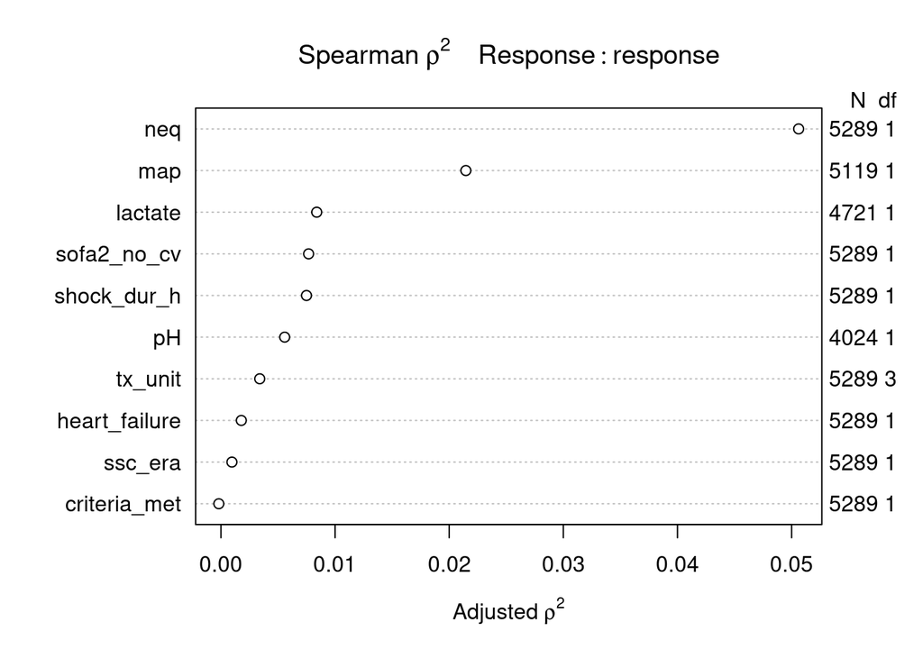

```r
plot(spearman2(response ~ ., data = avp |> select(-c(age, sex, race_eth))))
```

```r
invisible(pdf("avp_spearman.pdf"))
plot(spearman2(response ~ ., data = avp |> select(-c(age, sex, race_eth))),
     main = ""
     )
title(main = expression("Vasopressin Spearman " * rho^2))
invisible(dev.off())
```

The Spearman’s $\rho^2$ rank correlation plot shows that `neq` has the highest $\rho^2$, indicating `neq` has the highest potential ability to improve the model predictive performance through introduction of a non-linear term. Since `neq` is quantitative variable, introduce non-linearity with a natural spline with 3 knots (4 degrees of freedom). This approach will add three degrees of freedom to the main effects model (which had 12 parameter degrees of freedom) for a total of 15 parameter degrees of freedom (our budget amount based on the sample size calculation).

In the call below add the natural spline term to determine if it improve model fit. For this work, use a `workflow_set()` for the within-model comparisons.

```r
avp_m1_lr_rec_ns <-
  recipe(response ~ ., data = avp) |>
  # Declare age, sex, and race_eth in a bystander role to keep it in the
  # resampling dataset for future use in fairness checks
  update_role(age, sex, race_eth, new_role = "bystander") |>
  # Single (linear regression) imputation for missing quantitatitve predictors
  step_impute_linear(
    map,
    impute_with = vars(heart_failure, tx_unit, ssc_era, criteria_met,
                       sofa2_no_cv, neq, shock_dur_h,
                       )
                     ) |>
  step_impute_linear(
    lactate,
    impute_with = vars(heart_failure, tx_unit, ssc_era, criteria_met,
                       sofa2_no_cv, neq, shock_dur_h, map,
                       )
    ) |>
  step_impute_linear(
    pH,
    impute_with = vars(heart_failure, tx_unit, ssc_era, criteria_met,
                       sofa2_no_cv, neq, shock_dur_h, map, lactate,
                       )
    ) |>
  # Add natural spline with 3 knots (4 df) for neq
  step_spline_natural(neq, deg_free = 4)

avp_m1_lr_preproc <- list(
  avp_m1_main = avp_m1_lr_rec_main,
  avp_m1_ns = avp_m1_lr_rec_ns
  )

avp_m1_lr_models <-
  workflow_set(avp_m1_lr_preproc,
               list(logistic = logistic_reg(engine = "glm")),
               cross = FALSE)
```

Determine performance metrics (AUCROC and Brier score) using cross-validation resampling. These metrics were selected based on recommendations in [Van Calster 2025](https://doi.org/10.1016/j.landig.2025.100916), First, declare the survival metrics. Second, establish the cross-validation folds. Will use 10-fold cross-validation with 5 repeats, stratified by event. Third, save the predictions in order to visualize the model fit and residuals. Fourth, fit the model to the resampled dataset. Lastly, collect the predictions.

Resample each model in the workflow set (`avp_m1_lr_models`).

```r
set.seed(2026)
train_cv <- vfold_cv(avp, v = 10, repeats = 5, strata = response)
class_metrics <- metric_set(roc_auc, brier_class)
keep_pred <- control_resamples(save_pred = TRUE, save_workflow = FALSE)

avp_m1_lr_models_fit <-
  avp_m1_lr_models |>
  workflow_map("fit_resamples", seed = 2026, verbose = TRUE,
               resamples = train_cv, metrics = class_metrics,
               control = keep_pred
               )
```

```
i 1 of 2 resampling: avp_m1_main_logistic
```

```
✔ 1 of 2 resampling: avp_m1_main_logistic (19.5s)
```

```
i 2 of 2 resampling: avp_m1_ns_logistic
```

```
✔ 2 of 2 resampling: avp_m1_ns_logistic (25.8s)
```

```r
avp_m1_lr_preds <-
  collect_predictions(avp_m1_lr_models_fit, summarize = FALSE)
```

Collect then show the metrics (summarized over all cross-validation folds).

```r
avp_m1_lr_mets <-
  collect_metrics(avp_m1_lr_models_fit) |>
  # Compute 95% Wald CIs across the 50 resamples
  mutate(
    conf.low.95 = mean - qt(0.975, df = 10*5-1) * std_err,
    conf.high.95 = mean + qt(0.975, df = 10*5-1) * std_err,
    mean_ci = sprintf("%.3f (%.3f, %.3f)", mean, conf.low.95, conf.high.95)
  ) |>
  select(wflow_id, .metric, mean, conf.low.95, conf.high.95, mean_ci) |>
  pivot_wider(
    names_from = .metric,
    values_from = c(mean_ci, mean, conf.low.95, conf.high.95)
    )

avp_m1_lr_mets |>
  select(wflow_id, mean_ci_roc_auc, mean_ci_brier_class) |>
  gt() |>
  tab_header(
    title = "Vasopressin m1 (Logistic Regression) Metric Comparison",
    subtitle = "Using 10-fold Cross-Validation (5 repeats). Presented as mean (95% CI)."
    ) |>
  cols_label(
    wflow_id = "Model",
    mean_ci_roc_auc = "AUROC",
    mean_ci_brier_class = "Brier Score",
    ) |>
  cols_align(
    align = "left",
    columns = c(wflow_id)
    ) |>
  cols_align(
    align = "center",
    columns = c(mean_ci_roc_auc, mean_ci_brier_class)
    )
```

Vasopressin m1 (Logistic Regression) Metric Comparison

Using 10-fold Cross-Validation (5 repeats). Presented as mean (95% CI).

| Model | AUROC | Brier Score |
| --- | --- | --- |
| avp_m1_main_logistic | 0.684 (0.678, 0.690) | 0.207 (0.206, 0.209) |
| avp_m1_ns_logistic | 0.700 (0.695, 0.706) | 0.202 (0.201, 0.203) |

The model with non-linear terms (`avp_m1_ns_logistic`) had better than the main effects model (`avp_m1_main_logistic`).

Show a non-stylized plot (autoplot) of the AUROC comparison.

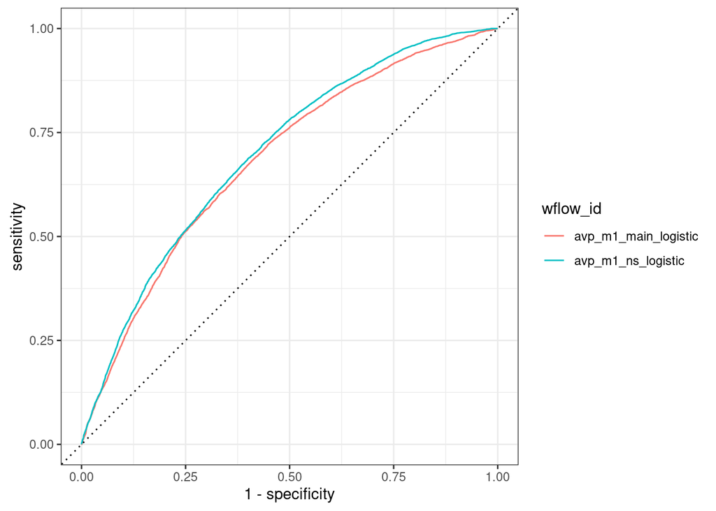

```r
avp_m1_lr_preds |>
  group_by(wflow_id) |>
  roc_curve(response, .pred_Response) |>
  autoplot()
```

The plot shows the ROC curve is consistently higher with the model incorporating the spline term compared with the model with main effects only.

### 12.2.2 Machine Learning

#### 12.2.2.1 Regularized (Elastic Net)

Fit regularized (elastic net) models. Use essentially the same recipes as for the logistic regression models (main effects and spline term for `neq`) except dummy code nominal predictors and normalize (center and scale) continuous predictors (normalization is done automatically by `glmnet` but this makes the step explicit).

```r
avp_m2_rec_main <- avp_m1_lr_rec_main |>
  step_dummy(all_nominal_predictors()) |>
  step_normalize(all_numeric_predictors())

avp_m2_rec_ns <- avp_m1_lr_rec_ns |>
  step_dummy(all_nominal_predictors()) |>
  step_normalize(all_numeric_predictors())

avp_m2_glmnet_preproc <- list(
  avp_m2_main = avp_m2_rec_main,
  avp_m2_ns = avp_m2_rec_ns
  )

avp_m2_glmnet_models <-
  workflow_set(avp_m2_glmnet_preproc,
               list(glmnet = logistic_reg(
                 engine = "glmnet",
                 mode = "classification",
                 penalty = tune(),     # lambda
                 mixture = tune()      # alpha
                 )),
               cross = TRUE
               )

set.seed(2026)
train_cv <- vfold_cv(avp, v = 10, repeats = 5, strata = response)
class_metrics <- metric_set(roc_auc, brier_class)
keep_pred <- control_resamples(save_pred = TRUE, save_workflow = FALSE)

pen_grid <- grid_space_filling(
  penalty(range = c(-5, 0)), # log10 scale, reasonable range for elastic net
  mixture(range = c(0, 1)),  # default
  size = 30
  )

avp_m2_glmnet_models_fit <-
  avp_m2_glmnet_models |>
  workflow_map("tune_grid", seed = 2026, verbose = TRUE,
               resamples = train_cv, grid = pen_grid,
               metrics = class_metrics, control = keep_pred
               )
```

```
i 1 of 2 tuning:     avp_m2_main_glmnet
```

```
✔ 1 of 2 tuning:     avp_m2_main_glmnet (2m 20.9s)
```

```
i 2 of 2 tuning:     avp_m2_ns_glmnet
```

```
✔ 2 of 2 tuning:     avp_m2_ns_glmnet (3m 11.9s)
```

```r
workflow_ids <- avp_m2_glmnet_models_fit$wflow_id

# Loop over workflows to finalize, fit, and collect results
avp_m2_glmnet_final_fit <- map(workflow_ids, function(wf_id) {

  # Extract tuning results for this workflow
  wf_result <- extract_workflow_set_result(avp_m2_glmnet_models_fit, id = wf_id)

  # Get best parameters by AUROC
  best_params <- select_best(wf_result, metric = "roc_auc")

  # Extract the workflow object itself
  wf <- extract_workflow(avp_m2_glmnet_models_fit, id = wf_id)

  # Finalize the workflow with best hyperparameters
  final_wf <- finalize_workflow(
    wf,
    best_params
  )

  # Fit the final workflow to the training set
  final_fit <- fit(final_wf, data = avp)

  # Collect resampling metrics for this workflow from tuning
  cv_metrics <- collect_metrics(wf_result) |>
    filter(penalty == best_params$penalty,
           mixture == best_params$mixture)

  # Collect predictions for the best parameters
  cv_preds <- collect_predictions(wf_result, summarize = TRUE) |>
    filter(penalty == best_params$penalty,
           mixture == best_params$mixture)

  # Return as a list
  list(
    workflow_id = wf_id,
    best_params = best_params,
    final_workflow = final_wf,
    final_fit = final_fit,
    cv_metrics = cv_metrics,
    cv_predictions = cv_preds
  )
})

# Name the list elements by workflow
names(avp_m2_glmnet_final_fit) <- workflow_ids
rm(workflow_ids)
```

Show elastic net hyperparameters resulting in the best fit.

```r
imap_dfr(avp_m2_glmnet_final_fit,
         ~ .x$best_params |> mutate(wflow_id = .y)
         ) |>
  select(wflow_id, penalty, mixture) |>
  gt() |>
  tab_header(
    title = "Vasopressin m2 Elastic Net Best Hyperparameters",
    subtitle = "Using 10-fold Cross-Validation (5 repeats)"
    ) |>
  cols_label(
    wflow_id = "Model",
    penalty = "Penalty (lambda [λ])",
    mixture = "Mixture (alpha [α])"
    ) |>
  fmt_number(decimals = 4) |>
  cols_align(
    align = "left",
    columns = c(wflow_id)
    ) |>
  cols_align(
    align = "center",
    columns = c(penalty, mixture)
    )
```

Vasopressin m2 Elastic Net Best Hyperparameters

Using 10-fold Cross-Validation (5 repeats)

| Model | Penalty (lambda [λ]) | Mixture (alpha [α]) |
| --- | --- | --- |
| avp_m2_main_glmnet | 0.0085 | 0.8966 |
| avp_m2_ns_glmnet | 0.0004 | 0.0345 |

These parameters suggest that applying a small penalty term (lambda) to the main effects model helps a little and it is essentially a LASSO situation with mixture 0.9. For the spline model there is no meaningful penalty and the elastic net model is very close to the unpenalized logistic regression model.

Collect metrics and display table (comparing to the logistic regression model fits).

```r
avp_m2_glmnet_mets <-
 avp_m2_glmnet_final_fit |> map(function(x) {
    x$cv_metrics |>
    mutate(wflow_id = x$workflow_id)
  }) |>
  list_rbind() |>
  mutate(
    conf.low.95 = mean - qt(0.975, df = 10*5-1) * std_err,
    conf.high.95 = mean + qt(0.975, df = 10*5-1) * std_err,
    mean_ci = sprintf("%.3f (%.3f, %.3f)", mean, conf.low.95, conf.high.95)
  ) |>
  select(wflow_id, .metric, mean, conf.low.95, conf.high.95, mean_ci) |>
  pivot_wider(
    names_from = .metric,
    values_from = c(mean_ci, mean, conf.low.95, conf.high.95)
    )

bind_rows(avp_m1_lr_mets, avp_m2_glmnet_mets)  |>
  select(wflow_id, mean_ci_roc_auc, mean_ci_brier_class) |>
  gt() |>
  tab_header(
    title = "Vasopressin m2 (Elastic Net) Metric Comparison",
    subtitle = "Using 10-fold Cross-Validation (5 repeats). Presented as mean (95% CI)."
    ) |>
  cols_label(
    wflow_id = "Model",
    mean_ci_roc_auc = "AUROC",
    mean_ci_brier_class = "Brier Score",
    ) |>
  cols_align(
    align = "left",
    columns = c(wflow_id)
    ) |>
  cols_align(
    align = "center",
    columns = c(mean_ci_roc_auc, mean_ci_brier_class)
    )
```

Vasopressin m2 (Elastic Net) Metric Comparison

Using 10-fold Cross-Validation (5 repeats). Presented as mean (95% CI).

| Model | AUROC | Brier Score |
| --- | --- | --- |
| avp_m1_main_logistic | 0.684 (0.678, 0.690) | 0.207 (0.206, 0.209) |
| avp_m1_ns_logistic | 0.700 (0.695, 0.706) | 0.202 (0.201, 0.203) |
| avp_m2_main_glmnet | 0.685 (0.680, 0.691) | 0.208 (0.207, 0.209) |
| avp_m2_ns_glmnet | 0.700 (0.695, 0.706) | 0.202 (0.200, 0.203) |

The metrics are essentially the same without and with regularization. This suggests that the model is not materially overfit. And in both models the spline term for `neq` improves fit.

#### 12.2.2.2 Random Forest

Fit a random forest model with the “ranger” engine.

```r
avp_m3_rf_rec <-
  recipe(response ~ ., data = avp) |>
  # Declare age, sex, and race_eth in a bystander role to keep it in the
  # resampling dataset for future use in fairness checks
  update_role(age, sex, race_eth, new_role = "bystander") |>
  # Single (linear regression) imputation for missing quantitative predictors
  step_impute_linear(
    map,
    impute_with = vars(heart_failure, tx_unit, ssc_era, criteria_met,
                       sofa2_no_cv, neq, shock_dur_h
                       )
                     ) |>
  step_impute_linear(
    lactate,
    impute_with = vars(heart_failure, tx_unit, ssc_era, criteria_met,
                       sofa2_no_cv, neq, shock_dur_h, map
                       )
    ) |>
  step_impute_linear(
    pH,
    impute_with = vars(heart_failure, tx_unit, ssc_era, criteria_met,
                       sofa2_no_cv, neq, shock_dur_h, map, lactate
                       )
    )

avp_m3_rf_preproc <- list(avp_m3_rf = avp_m3_rf_rec)

avp_m3_rf_models <-
  workflow_set(avp_m3_rf_preproc,
               list(ranger = rand_forest(
                 engine = "ranger",
                 mode = "classification",
                 trees = 1000,      # Default is 500, 1000 is better
                 mtry = tune(),     # Number of randomly selected predictors
                 min_n = tune()     # Minimum node size
                 )),
               cross = TRUE
               )

set.seed(2026)
train_cv <- vfold_cv(avp, v = 10, repeats = 5, strata = response)
class_metrics <- metric_set(roc_auc, brier_class)
keep_pred <- control_resamples(save_pred = TRUE, save_workflow = FALSE)

# Prep recipe and determine predictor count
avp_m3_rf_rec_prep <- prep(avp_m3_rf_rec)

x_train <- bake(avp_m3_rf_rec_prep, new_data = NULL) |>
  select(-c(response, age, sex, race_eth))

p <- ncol(x_train) # p == 10

rf_param_set <- parameters(
  mtry(range = c(1L, 10L)), #sqrt(p) ~= 3, (p / 2) == 5, which is too narrow
  min_n(range = c(2L, 50L))
)

initial_candidates <- grid_space_filling(
  rf_param_set,
  size = 30
)

race_ctrl <- control_race(
  save_pred = TRUE,
  save_workflow = TRUE,
  parallel_over = "resamples",
  verbose = FALSE
)

avp_m3_rf_model_fit <-
  avp_m3_rf_models |>
  workflow_map(
    "tune_race_anova", seed = 2026, resamples = train_cv,
    grid = initial_candidates, metrics = class_metrics, control = race_ctrl
  )

# Get workflow IDs
workflow_ids <- avp_m3_rf_model_fit$wflow_id

# Finalize, fit, and collect results for the workflow
avp_m3_rf_final_fit <- map(workflow_ids, function(wf_id) {
  # Extract tuning (race) results for this workflow
  wf_result <- extract_workflow_set_result(
    avp_m3_rf_model_fit,
    id = wf_id
    )
  # Select best hyperparameters by AUROC
  best_params <- select_best(wf_result, metric = "roc_auc")
  # Extract the workflow itself
  wf <- extract_workflow(avp_m3_rf_model_fit, id = wf_id)
  # Finalize workflow with best hyperparameters
  final_wf <- finalize_workflow(wf, best_params)
  # Fit finalized workflow to derivation data
  final_fit <- fit(final_wf, data = avp)
  # Collect CV metrics for the selected configuration
  cv_metrics <- collect_metrics(wf_result) |>
    filter(.config == best_params$.config)
  # Collect CV predictions for the selected configuration
  cv_predictions <- collect_predictions(wf_result) |>
    filter(.config == best_params$.config)
  # Return results
  list(
    workflow_id     = wf_id,
    best_params     = best_params,
    final_workflow  = final_wf,
    final_fit       = final_fit,
    cv_metrics      = cv_metrics,
    cv_predictions  = cv_predictions
    )
})

names(avp_m3_rf_final_fit) <- map_chr(avp_m3_rf_final_fit, "workflow_id")
```

Show hyperparameters resulting in the best fit.

```r
imap_dfr(avp_m3_rf_final_fit,
         ~ .x$best_params |> mutate(workflow_id = .y)
         ) |>
  select(workflow_id, mtry, min_n) |>
  gt() |>
  tab_header(
    title = "Random Forest Best Hyperparameters",
    subtitle = "Using 10-fold Cross-Validation (5 repeats)"
    ) |>
  cols_label(
    workflow_id = "Model",
    mtry = "Random Variables at Split (mtry)",
    min_n = "Min Terminal Node Size (min_n)"
    ) |>
  fmt_number(decimals = 0) |>
  cols_align(
    align = "left",
    columns = c(workflow_id)
    ) |>
  cols_align(
    align = "center",
    columns = c(mtry, min_n)
    )
```

Random Forest Best Hyperparameters

Using 10-fold Cross-Validation (5 repeats)

| Model | Random Variables at Split (mtry) | Min Terminal Node Size (min_n) |
| --- | --- | --- |
| avp_m3_rf_ranger | 1 | 25 |

These parameters show that in the best performing model at each split the forest considers only one randomly chosen predictor. This is “maximum decorrelation” among trees. Because CV chose mtry == 1, it suggest no single predictor is substantially dominant and that the ensemble benefits from forcing trees to explore different predictors. The selection of min_n = 25 indicates that the forest prefers a moderate amount of smoothing to represent non-linear effects, but following small local patterns (with lower min_n) is not useful.

Collect and display metrics for model.

```r
avp_m3_rf_mets <-
 avp_m3_rf_final_fit |> map(function(x) {
    x$cv_metrics |>
    mutate(wflow_id = x$workflow_id)
  }) |>
  list_rbind() |>
  mutate(
    conf.low.95 = mean - qt(0.975, df = 10*5-1) * std_err,
    conf.high.95 = mean + qt(0.975, df = 10*5-1) * std_err,
    mean_ci = sprintf("%.3f (%.3f, %.3f)", mean, conf.low.95, conf.high.95)
  ) |>
  select(wflow_id, .metric, mean, conf.low.95, conf.high.95, mean_ci) |>
  pivot_wider(
    names_from = .metric,
    values_from = c(mean_ci, mean, conf.low.95, conf.high.95)
    )

bind_rows(avp_m1_lr_mets,
          avp_m2_glmnet_mets,
          avp_m3_rf_mets)  |>
  select(wflow_id, mean_ci_roc_auc, mean_ci_brier_class) |>
  gt() |>
  tab_header(
    title = "Vasopressin m3 (Random Forest) Metric Comparison",
    subtitle = "Using 10-fold Cross-Validation (5 repeats). Presented as mean (95% CI)."
    ) |>
  cols_label(
    wflow_id = "Model",
    mean_ci_roc_auc = "AUROC",
    mean_ci_brier_class = "Brier Score",
    ) |>
  cols_align(
    align = "left",
    columns = c(wflow_id)
    ) |>
  cols_align(
    align = "center",
    columns = c(mean_ci_roc_auc, mean_ci_brier_class)
    )
```

Vasopressin m3 (Random Forest) Metric Comparison

Using 10-fold Cross-Validation (5 repeats). Presented as mean (95% CI).

| Model | AUROC | Brier Score |
| --- | --- | --- |
| avp_m1_main_logistic | 0.684 (0.678, 0.690) | 0.207 (0.206, 0.209) |
| avp_m1_ns_logistic | 0.700 (0.695, 0.706) | 0.202 (0.201, 0.203) |
| avp_m2_main_glmnet | 0.685 (0.680, 0.691) | 0.208 (0.207, 0.209) |
| avp_m2_ns_glmnet | 0.700 (0.695, 0.706) | 0.202 (0.200, 0.203) |
| avp_m3_rf_ranger | 0.703 (0.698, 0.708) | 0.207 (0.207, 0.208) |

The random forest model marginally improves discrimination (higher AUROC) at the expense of slightly worse overall performance (higher Brier).

#### 12.2.2.3 Boosted Trees

Generate a boosted tree model with the “xgboost” engine in {tidymodels}.

```r
avp_m4_xgb_rec <-
  recipe(response ~ ., data = avp) |>
  update_role(age, sex, race_eth, new_role = "bystander") |>
  step_impute_linear(
    map,
    impute_with = vars(
      heart_failure, tx_unit, ssc_era,
      criteria_met, sofa2_no_cv,
      neq, shock_dur_h
    )
  ) |>
  step_impute_linear(
    lactate,
    impute_with = vars(
      heart_failure, tx_unit, ssc_era,
      criteria_met, sofa2_no_cv,
      neq, shock_dur_h, map
    )
  ) |>
  step_impute_linear(
    pH,
    impute_with = vars(
      heart_failure, tx_unit, ssc_era,
      criteria_met, sofa2_no_cv,
      neq, shock_dur_h, map, lactate
    )
  ) |>
  # Dummy code nominal predictors
  step_dummy(all_nominal_predictors())

avp_m4_xgb_preproc <- list(avp_m4_boost = avp_m4_xgb_rec)

avp_m4_xgb_model <-
  workflow_set(avp_m4_xgb_preproc,
               list(xgboost = boost_tree(
                 trees = 1000,              # Number of trees
                 tree_depth = tune(),       # Tree depth: # of "interactions"
                 min_n = tune(),            # Minimum node size
                 loss_reduction = tune(),   # Reduction in the loss function required to split further
                 sample_size = tune(),      # Proportion of data exposed to fitting routine
                 mtry = tune(),             # Random predictors at each split
                 learn_rate = tune()        # Rate at which the boosting algorithm adapts
                 ) |>
                   set_engine("xgboost") |>
                   set_mode("classification")
                 ),
               cross = FALSE
               )

set.seed(2026)
train_cv <- vfold_cv(avp, v = 10, repeats = 5, strata = response)
class_metrics <- metric_set(roc_auc, brier_class)
keep_pred <- control_resamples(save_pred = TRUE, save_workflow = FALSE)

# Prep recipe and determine post-dummy predictor count
avp_m4_xgb_rec_prep <- prep(avp_m4_xgb_rec)

x_train <- bake(avp_m4_xgb_rec_prep, new_data = NULL) |>
  select(-c(response, age, sex, race_eth))

p <- ncol(x_train) # p == 10

# Select parameters (particularly depth) based p==10 and RF optimal parameters
xgb_params <- parameters(
  tree_depth(range = c(1L, 6L)),
  min_n(range = c(2L, 50L)),
  learn_rate(range = c(-3, -0.5)),
  loss_reduction(),
  sample_prop(range = c(0.5, 1.0)),
  finalize(mtry(), x_train)
  )

initial_candidates <- grid_space_filling(
  xgb_params,
  size = 30
  )

race_ctrl <- control_race(
  save_pred = TRUE,
  save_workflow = TRUE,
  parallel_over = "resamples",
  verbose = FALSE
  )

avp_m4_xgb_model_fit <-
  avp_m4_xgb_model |>
  workflow_map(
    "tune_race_anova",
    seed = 2026,
    resamples = train_cv,
    grid = initial_candidates,
    metrics = class_metrics,
    control = race_ctrl
    )

workflow_ids <- avp_m4_xgb_model_fit$wflow_id

# Finalize, fit, and collect results the workflow
avp_m4_xgb_final_fit <- map(workflow_ids, function(wf_id) {
  # Extract tuning (race) results for this workflow
  wf_result <- extract_workflow_set_result(
    avp_m4_xgb_model_fit,
    id = wf_id
    )
  # Select best hyperparameters by AUROC
  best_params <- select_best(wf_result, metric = "roc_auc")
  # Extract the workflow itself
  wf <- extract_workflow(avp_m4_xgb_model_fit, id = wf_id)
  # Finalize workflow with best hyperparameters
  final_wf <- finalize_workflow(wf, best_params)
  # Fit finalized workflow to derivation data
  final_fit <- fit(final_wf, data = avp)
  # Collect CV metrics for the selected configuration
  cv_metrics <- collect_metrics(wf_result) |>
    filter(.config == best_params$.config)
  # Collect CV predictions for the selected configuration
  cv_predictions <- collect_predictions(wf_result) |>
    filter(.config == best_params$.config)
  # Return results
  list(
    workflow_id     = wf_id,
    best_params     = best_params,
    final_workflow  = final_wf,
    final_fit       = final_fit,
    cv_metrics      = cv_metrics,
    cv_predictions  = cv_predictions
    )
})

names(avp_m4_xgb_final_fit) <- map_chr(avp_m4_xgb_final_fit, "workflow_id")
```

Show hyperparameters resulting in the best fit.

```r
imap_dfr(avp_m4_xgb_final_fit,
         ~ .x$best_params |> mutate(wflow_id = .y)
         ) |>
  mutate(trees = 1000) |>
  select(wflow_id, trees, tree_depth, min_n, learn_rate, loss_reduction,
         sample_size, mtry
         ) |>
  gt() |>
  fmt_number(columns = learn_rate, decimals = 4) |>
  fmt_number(columns = loss_reduction, decimals = 3) |>
  tab_header(
    title = "Gradient Boosted Model Best Hyperparameters",
    subtitle = "Using 10-fold Cross-Validation (5 repeats)"
    ) |>
  cols_label(
    wflow_id = "Model",
    trees = "Trees",
    tree_depth = "Tree Depth",
    min_n = "Node Size",
    learn_rate = "Learn Rate",
    loss_reduction = "Min Loss Reduction",
    sample_size = "Proportion of data exposed",
    mtry = "Predictors at Splits",
    ) |>
  cols_align(
    align = "left",
    columns = c(wflow_id)
    ) |>
  cols_align(
    align = "center",
    columns = c(trees, tree_depth, min_n, learn_rate, loss_reduction,
                sample_size, mtry
                )
    )
```

Gradient Boosted Model Best Hyperparameters

Using 10-fold Cross-Validation (5 repeats)

| Model | Trees | Tree Depth | Node Size | Learn Rate | Min Loss Reduction | Proportion of data exposed | Predictors at Splits |
| --- | --- | --- | --- | --- | --- | --- | --- |
| avp_m4_boost_xgboost | 1000 | 2 | 18 | 0.0196 | 0.329 | 0.5 | 2 |

Collect and display metrics for model.

```r
avp_m4_xgb_mets <-
 avp_m4_xgb_final_fit |> map(function(x) {
    x$cv_metrics |>
    mutate(wflow_id = x$workflow_id)
  }) |>
  list_rbind() |>
  mutate(
    conf.low.95 = mean - qt(0.975, df = 10*5-1) * std_err,
    conf.high.95 = mean + qt(0.975, df = 10*5-1) * std_err,
    mean_ci = sprintf("%.3f (%.3f, %.3f)", mean, conf.low.95, conf.high.95)
  ) |>
  select(wflow_id, .metric, mean, conf.low.95, conf.high.95, mean_ci) |>
  pivot_wider(
    names_from = .metric,
    values_from = c(mean_ci, mean, conf.low.95, conf.high.95)
    )

bind_rows(avp_m1_lr_mets,
          avp_m2_glmnet_mets,
          avp_m3_rf_mets,
          avp_m4_xgb_mets
          )  |>
  select(wflow_id, mean_ci_roc_auc, mean_ci_brier_class) |>
  gt() |>
  tab_header(
    title = "Vasopressin m4 (XGBoost) Metric Comparison",
    subtitle = "Using 10-fold Cross-Validation (5 repeats). Presented as mean (95% CI)."
    ) |>
  cols_label(
    wflow_id = "Model",
    mean_ci_roc_auc = "AUROC",
    mean_ci_brier_class = "Brier Score",
    ) |>
  cols_align(
    align = "left",
    columns = c(wflow_id)
    ) |>
  cols_align(
    align = "center",
    columns = c(mean_ci_roc_auc, mean_ci_brier_class)
    )
```

Vasopressin m4 (XGBoost) Metric Comparison

Using 10-fold Cross-Validation (5 repeats). Presented as mean (95% CI).

| Model | AUROC | Brier Score |
| --- | --- | --- |
| avp_m1_main_logistic | 0.684 (0.678, 0.690) | 0.207 (0.206, 0.209) |
| avp_m1_ns_logistic | 0.700 (0.695, 0.706) | 0.202 (0.201, 0.203) |
| avp_m2_main_glmnet | 0.685 (0.680, 0.691) | 0.208 (0.207, 0.209) |
| avp_m2_ns_glmnet | 0.700 (0.695, 0.706) | 0.202 (0.200, 0.203) |
| avp_m3_rf_ranger | 0.703 (0.698, 0.708) | 0.207 (0.207, 0.208) |
| avp_m4_boost_xgboost | 0.703 (0.697, 0.708) | 0.201 (0.200, 0.202) |

The boosted model has the best discrimination and accuracy metrics among all models evaluated, but the difference is marginal.

### 12.2.3 Discrimination/Accuracy Comparison

Now, show the discrimination and accuracy metrics for all models.

```r
(avp_disc_perf_mets <- bind_rows(avp_m1_lr_mets,
          avp_m2_glmnet_mets,
          avp_m3_rf_mets,
          avp_m4_xgb_mets
          )  |>
  select(wflow_id, mean_ci_roc_auc, mean_ci_brier_class) |>
  gt() |>
  tab_header(
    title = "Vasopressin Models Discrimination/Overall Performance Metric Comparison",
    subtitle = "Using 10-fold Cross-Validation (5 repeats). Presented as mean (95% CI)."
    ) |>
  cols_label(
    wflow_id = "Model",
    mean_ci_roc_auc = "AUROC",
    mean_ci_brier_class = "Brier Score",
    ) |>
  cols_align(
    align = "left",
    columns = c(wflow_id)
    ) |>
  cols_align(
    align = "center",
    columns = c(mean_ci_roc_auc, mean_ci_brier_class)
    ))
```

Vasopressin Models Discrimination/Overall Performance Metric Comparison

Using 10-fold Cross-Validation (5 repeats). Presented as mean (95% CI).

| Model | AUROC | Brier Score |
| --- | --- | --- |
| avp_m1_main_logistic | 0.684 (0.678, 0.690) | 0.207 (0.206, 0.209) |
| avp_m1_ns_logistic | 0.700 (0.695, 0.706) | 0.202 (0.201, 0.203) |
| avp_m2_main_glmnet | 0.685 (0.680, 0.691) | 0.208 (0.207, 0.209) |
| avp_m2_ns_glmnet | 0.700 (0.695, 0.706) | 0.202 (0.200, 0.203) |
| avp_m3_rf_ranger | 0.703 (0.698, 0.708) | 0.207 (0.207, 0.208) |
| avp_m4_boost_xgboost | 0.703 (0.697, 0.708) | 0.201 (0.200, 0.202) |

The largest performance gain came from modeling `neq` with a natural spline (`avp_m1_ns_logistic`) instead of main effects alone (`avp_m1_main_logistic`). The differences between the spline logistic regression model and machine learning models are very minor (<=0.01 difference for each metric point estimate) and they generally have similarly modest performance.

Considering the goal of future model implementation in the electronic medical record and explainability to clinicians, a logistic regression model (`avp_m1_ns_logistic`) is preferred. The XGBoost model (`avp_m4_boost_xgboost`) had marginally better performance, though. These two models will be carried forward for calibration assessment prior to final model selection.

Export comparison table to Word

```r
gtsave(
  data = avp_disc_perf_mets,
  filename = "avp_disc_perf_metrics.docx"
)
```

### 12.2.4 Calibration

#### 12.2.4.1 Logistic Regression Model

Compare the observed outcomes from the original derivation dataset with the predicted probabilities for the outcome generated in the out-of-fold predictions from the repeated cross-validation process (averaging the out-of-fold predictions for each patient).

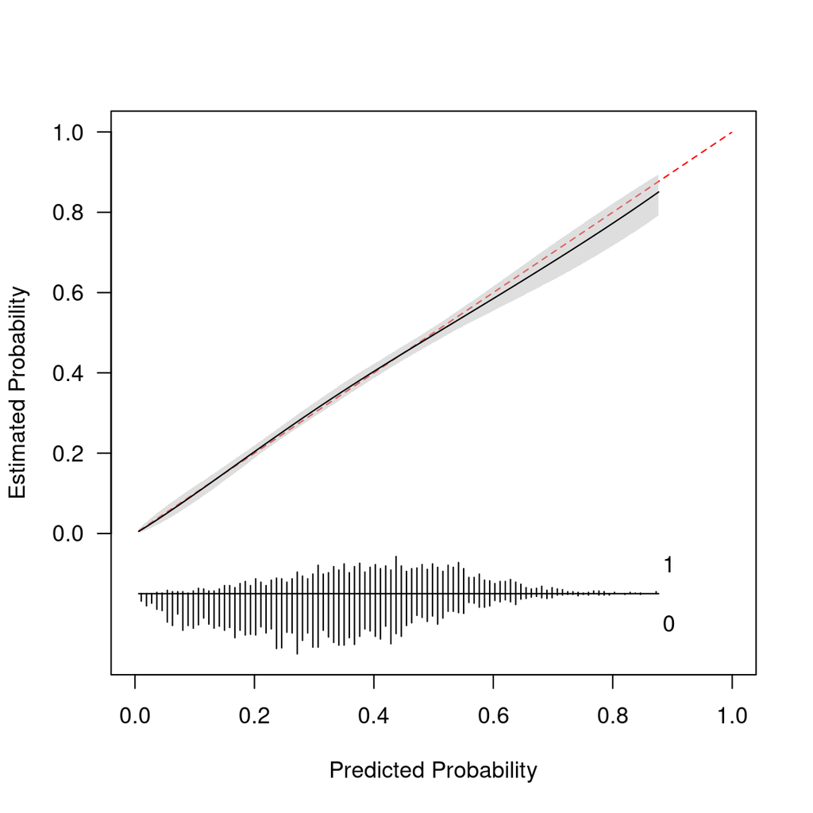

```r
avp_m1_lr_preds_cv <- avp_m1_lr_preds |>
  filter(wflow_id == "avp_m1_ns_logistic") |>
  group_by(.row) |>
  summarise(
    response = first(response),
    .pred_Response = mean(.pred_Response),
    .groups = "drop"
  ) |>
  mutate(
    response_num = if_else(response == "Response", 1, 0)
  )

set.seed(2026)
avp_lr_cal <-
  pmcalibration(
    y = avp_m1_lr_preds_cv$response_num,
    p = avp_m1_lr_preds_cv$.pred_Response,
    ci = "boot", # n = 1000 replicates is the default
    smooth = "rcs",
    nk = 3 # 5 knots is default, 3 has less bias
    )
```

```r
invisible(pdf("avp_logistic_calibration.pdf"))
par(mfrow = c(1, 1),
    cex.axis = 1.4, cex.lab = 1.8, cex.main = 2,
    mar = c(5.1, 5.5, 1.4, 1.6), # bottom, left, top, right
    mgp = c(3.5, 1, 0)
    )
plot(avp_lr_cal)
invisible(dev.off())
```

The cross-validated predictions from the logistic regression model with a natural spline term for `neq` are very well calibrated relative to the observed outcomes in the derivation cohort.

Although the discrimination (AUROC) for the logistic regression model (with a spline term) was only modest, the calibration is very good. This means the probabilities the model produces are very trustworthy.

#### 12.2.4.2 XGBoost Model

Use the same calibration assessment workflow for the boosted trees (XGBoost) model.

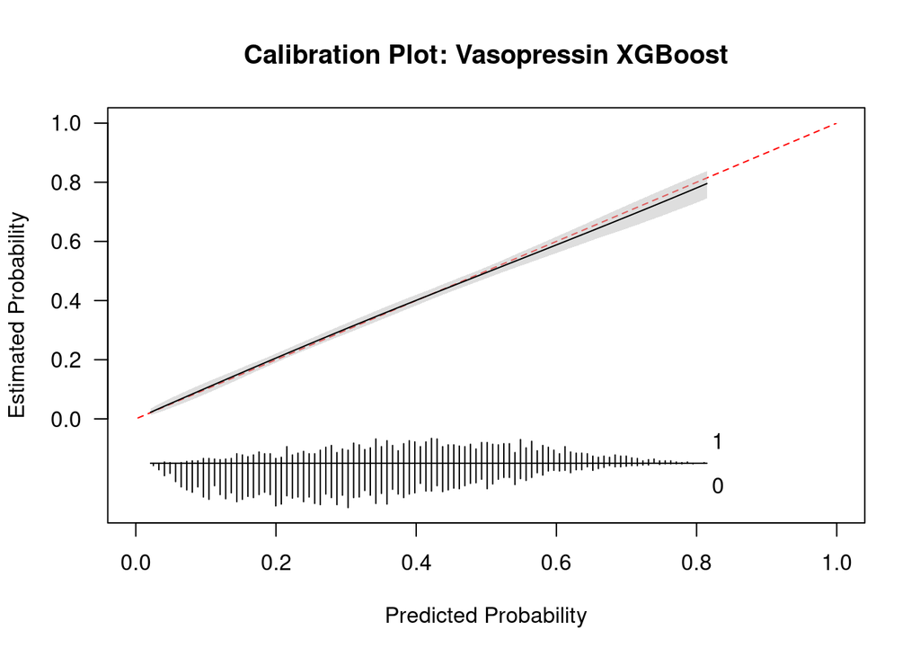

```r
avp_m4_xgb_preds <- avp_m4_xgb_final_fit[[1]]$cv_predictions

avp_m4_xgb_preds_cv <- avp_m4_xgb_preds |>
  group_by(.row) |>
  summarise(
    response = first(response),
    .pred_Response = mean(.pred_Response),
    .groups = "drop"
  ) |>
  mutate(
    response_num = if_else(response == "Response", 1, 0)
  )

set.seed(2026)
avp_xgb_cal <- pmcalibration(
  y = avp_m4_xgb_preds_cv$response_num,
  p = avp_m4_xgb_preds_cv$.pred_Response,
  ci = "boot", # n = 1000 replicates is the default
  smooth = "rcs",
  nk = 3 # 5 knots is default, 3 has less bias
  )
plot(avp_xgb_cal)
title("Calibration Plot: Vasopressin XGBoost")
```

```r
invisible(dev.copy(pdf, "avp_xgboost_calibration.pdf"))
invisible(dev.off())
```

Save the two vasopressin calibration plots as a panel figure.

```r
invisible(ragg::agg_tiff("avp_calibration_panel.tiff",
                         width = 11, height = 5, units = "in",
                         res = 600, compression = "lzw"
                         ))

par(mfrow = c(1, 2), pty = "s")

plot(avp_lr_cal)
title("Vasopressin Logistic Regression (Non-Linear)")

plot(avp_xgb_cal)
title("Vasopressin XGBoost")

par(mfrow = c(1, 1))
invisible(dev.off())
```

#### 12.2.4.3 Quantitative metrics

Generate and display metrics for the two models. The “Eavg” is the same as “integrated calibration index” (ICI), therefore will make this clarification in the output. The “ECI” is the average squared difference between predicted and observed probabilities (multiplied by 100). For each of the calibration metrics outlined, lower values are better.

```r
# Display the table
(avp_cal_metrics_tbl <-
  bind_rows(
    as_tibble(avp_lr_cal$metrics, rownames = "metric") |>
      mutate(model = "Logistic (spline)"),
    as_tibble(avp_xgb_cal$metrics, rownames = "metric") |>
      mutate(model = "XGBoost")
  ) |>
  select(model, metric, value) |>
  pivot_wider(
    names_from = metric,
    values_from = value
  ) |>
  rename(
    Model = model,
    `Eavg (ICI)` = Eavg
  ) |>
  gt() |>
  tab_header(
    title = "Vasopressin Model Calibration Metrics"
  ) |>
  fmt_number(
    columns = c(`Eavg (ICI)`, E50, E90, Emax, ECI),
    decimals = 4
  ) |>
  cols_align(
    align = "center"
  ))
```

Vasopressin Model Calibration Metrics

| Model | Eavg (ICI) | E50 | E90 | Emax | ECI |
| --- | --- | --- | --- | --- | --- |
| Logistic (spline) | 0.0056 | 0.0051 | 0.0104 | 0.0276 | 0.0053 |
| XGBoost | 0.0053 | 0.0049 | 0.0101 | 0.0192 | 0.0040 |

Both models are extremely well calibrated. The XGBoost model has consistently better quantitative calibration metrics, but the differences between models are very small.

Export comparison table to Word

```r
gtsave(
  data = avp_cal_metrics_tbl,
  filename = "avp_cal_metric_comparison.docx"
)
```

### 12.2.5 Decision Curve Analysis

To assess if there may be clinical utility with the two vasopressin response prediction models under consideration, perform a decision curve analysis (DCA). To correct for overfitting, use the out-of-fold predictions for each model.

First, extract predictions from the logistic regression and XGBoost models, and combine.

```r
# Extract the out-of-fold predictions for each model
# Then average predictions across the 5 CV repeats using .row
# Logistic model
avp_lr_dca <- avp_m1_lr_preds |>
  filter(wflow_id == "avp_m1_ns_logistic") |>
  group_by(.row) |>
  summarise(
    response = first(response),
    p_logistic = mean(.pred_Response),
    .groups = "drop"
  )

# XGBoost model
avp_xgb_dca <- avp_m4_xgb_final_fit[[1]]$cv_predictions |>
  group_by(.row) |>
  summarise(
    p_xgb = mean(.pred_Response),
    .groups = "drop"
  )

# Combine
avp_dca_data <- avp_lr_dca |>
  left_join(avp_xgb_dca, by = ".row")
```

Then run DCA and plot.

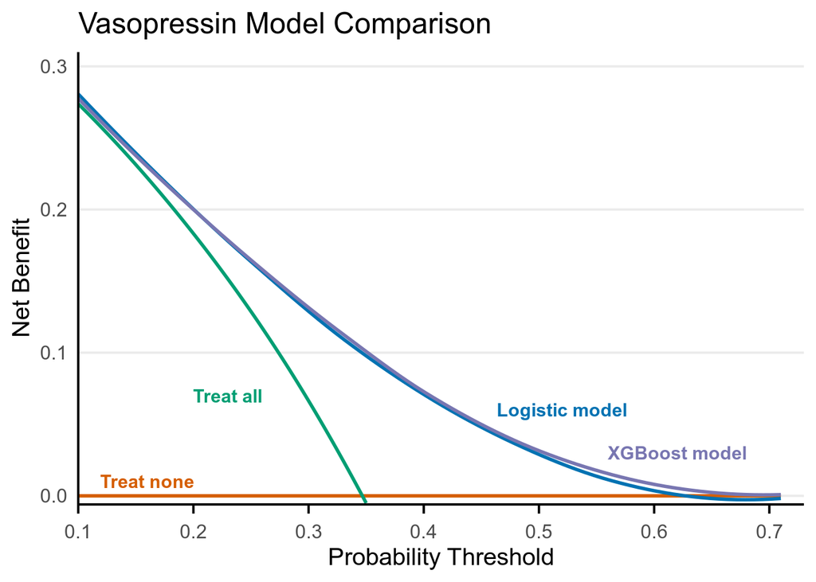

```r
avp_dca <- dca(
  response == "Response" ~ p_logistic + p_xgb,
  data = avp_dca_data
  )

(avp_dca_plot <-
  ggplot(as_tibble(avp_dca) |>
           filter(net_benefit >= -0.006 &
                    net_benefit <= 0.31 &
                    threshold <=0.71
                  ) |>
           mutate(label = fct_relevel(label, "Treat None", "Treat All",
                                     "p_logistic", "p_xgb"
                                     )),
         aes(x = threshold,
             y = net_benefit,
             color = label,
             group = label)) +
    geom_smooth(method = loess, formula = y ~ x,
                linewidth = 1, se = FALSE) +
    scale_color_manual(values = c(
      "p_logistic" = "#0072B2",
      "p_xgb" = "#7876B1FF",
      "Treat All" = "#009E73",
      "Treat None" = "#D55E00"
      ),
      labels = c(
        "p_logistic" = "Logistic regression",
        "p_xgb" = "XGBoost",
        "Treat All" = "Treat all",
        "Treat None" = "Treat none"
      )) +
    scale_y_continuous(
      limits = c(-0.006, 0.31),
      expand = expansion(add = c(0, 0))
      ) +
    scale_x_continuous(
      limits = c(0.1, 0.71),
      breaks = seq(0, 0.7, by = 0.1),
      expand = expansion(add = c(0, 0.02))
      ) +
    labs(
      title = "Vasopressin Model Comparison",
      x = "Probability Threshold",
      y = "Net Benefit",
      color = NULL
      ) +
    annotate("text", x = 0.52, y = 0.06, label = "Logistic model",
             color = "#0072B2", family = "Arial", fontface = "bold",
             size = 4
             ) +
    annotate("text", x = 0.62, y = 0.03, label = "XGBoost model",
             color = "#7876B1FF", family = "Arial", fontface = "bold",
             size = 4
             ) +
    annotate("text", x = 0.23, y = 0.07, label = "Treat all",
             color = "#009E73", family = "Arial", fontface = "bold",
             size = 4
             ) +
    annotate("text", x = 0.16, y = 0.01, label = "Treat none",
             color = "#D55E00", family = "Arial", fontface = "bold",
             size = 4
             ) +
    theme_minimal(base_size = 15) +
    theme(
      text = element_text(family = "Arial"),
      legend.position = "none",
      panel.grid.minor = element_blank(),
      panel.grid.major.x = element_blank(),
      axis.line.x = element_line(),
      axis.line.y = element_line(),
      axis.ticks.x = element_line(),
      axis.ticks.length = unit(0.2, "cm")
    ))
```

Both models are better than “Treat none” and “Treat all” from probability thresholds about 0.1 to about 0.6. The two models have essentially the same net benefit at probability thresholds below 0.5, with the XGBoost model having slightly higher net benefit at probability thresholds from 0.5 to 0.65.

Obtain exact threshold values for positive net benefit with logistic regression and XGBoost models. To improve matching with visualization in the figure, use a practical tolerance value of 0.001 for the thresholds.

```r
as_tibble(avp_dca) |>
  select(threshold, label, net_benefit) |>
  pivot_wider(names_from = label, values_from = net_benefit) |>
  filter(!is.na(p_logistic), !is.na(p_xgb),
         !is.na(`Treat All`), !is.na(`Treat None`)
         ) |>
  summarise(
    min_prob_thresh_lr = min(threshold[p_logistic > `Treat All` + 0.001 &
                                         p_logistic > `Treat None` + 0.001]
                             ),
    max_prob_thresh_lr = max(threshold[p_logistic > `Treat All` + 0.001 &
                                         p_logistic > `Treat None` + 0.001]
                             ),
    min_prob_thresh_xgb = min(threshold[p_xgb > `Treat All` + 0.001 &
                                         p_xgb > `Treat None` + 0.001]
                             ),
    max_prob_thresh_xgb = max(threshold[p_xgb > `Treat All` + 0.001 &
                                         p_xgb > `Treat None` + 0.001]
                             )
  )
```

```
# A tibble: 1 × 4
  min_prob_thresh_lr max_prob_thresh_lr min_prob_thresh_xgb
               <dbl>              <dbl>               <dbl>
1               0.08               0.61                0.08
# ℹ 1 more variable: max_prob_thresh_xgb <dbl>
```

The vasopressin response logistic regression model had higher net benefit than the “Treat all” and “Treat none” curves at threshold probabilities from 0.08 to 0.61. The vasopressin response XGBoost model had higher net benefit than the “Treat all” and “Treat none” curves at threshold probabilities from 0.08 to 0.68.

Save DCA plot

```r
ggsave(
  "avp_dca_compare.tiff",
  plot = avp_dca_plot,
  device = ragg::agg_tiff,
  width = dev.size("in")[1],
  height = dev.size("in")[2],
  units = "in",
  dpi = 600,
  compression = "lzw"
)
```

### 12.2.6 Model Selection

Overall, compared with the logistic regression model with a spline term for `neq`, the XGBoost model demonstrated slightly better discrimination, overall performance, calibration, and net benefit on decision curve analysis. However, the magnitude of improvement was very small. Considering overall performance similarity but higher interpretability and implementation readiness for a logistic regression model, the logistic regression model with a spline term for norepinephrine dose (`avp_m1_ns_logistic`) was selected as the final model for vasopressin.

#### 12.2.6.1 Refit to Whole Derivation Dataset

Refit the final model (`avp_m1_ns_logistic`) in the whole vasopressin derivation dataset (`avp`).

```r
set.seed(2026)
avp_mod_final_wf <- extract_workflow(
  avp_m1_lr_models,
  id = "avp_m1_ns_logistic"
  )
avp_mod_final_fit_dev <- fit(avp_mod_final_wf, avp)
```

Extract engine data and estimate apparent performance on derivation data.

```r
avp_lr_fit <- extract_fit_engine(avp_mod_final_fit_dev)
avp_apparent_performance <- glance(avp_lr_fit) |>
  transmute(
    nobs,
    n_parameters = length(coef(avp_lr_fit)) - 1,
    r2_nag = performance::r2_nagelkerke(avp_lr_fit)
  )

## Prepare data
avp_rec_trained <- extract_recipe(avp_mod_final_fit_dev)

avp_baked_dev <- bake(
  avp_rec_trained,
  new_data = avp,
  all_predictors()
)

avp_dev_score_data <- bind_cols(
  avp |> select(response),
  avp_baked_dev
)

# Generate metrics
avp_dev_score <-
  Score(
    object = list(avp_lr_fit),
    formula = response ~ 1,
    data = avp_dev_score_data,
    metrics = c("auc", "brier")
    )

# Extract and format results
auc_ci <-
  avp_dev_score$AUC$score |>
  as_tibble() |>
  transmute(
    auc = as.numeric(AUC),
    auc_lower = as.numeric(lower),
    auc_upper = as.numeric(upper)
  )

brier_ci <-
  avp_dev_score$Brier$score |>
  as_tibble() |>
  filter(model == "glm") |>
  transmute(
    brier = as.numeric(Brier),
    brier_lower = as.numeric(lower),
    brier_upper = as.numeric(upper)
  )

avp_dev_mets <- cbind(auc_ci, brier_ci) |>
  mutate(
    AUROC = sprintf("%.3f (%.3f, %.3f)", auc, auc_lower, auc_upper),
    Brier = sprintf("%.3f (%.3f, %.3f)", brier, brier_lower, brier_upper)
  )
rm(auc_ci, brier_ci)

cbind(avp_apparent_performance,
      avp_dev_mets |> select(AUROC, Brier)) |>
  gt() |>
  fmt_number(columns = c(r2_nag),
             decimals = 3
             ) |>
  tab_header(title = "Vasopressin Logistic Regression Model Fit and Apparent Performance Parameters",
             subtitle = "In Derivation (Ohio) Dataset") |>
  cols_label(
    nobs = "N",
    n_parameters =  "Parameters (n)",
    r2_nag = "R2 (Nagelkerke)",
    Brier = "Brier Score"
    ) |>
  cols_align(align = "center")
```

Vasopressin Logistic Regression Model Fit and Apparent Performance Parameters

In Derivation (Ohio) Dataset

| N | Parameters (n) | R2 (Nagelkerke) | AUROC | Brier Score |
| --- | --- | --- | --- | --- |
| 5289 | 15 | 0.160 | 0.704 (0.690, 0.719) | 0.201 (0.196, 0.205) |

Show model parameters.

```r
(avp_lr_param_estimates <-
   tidy(avp_lr_fit,
        conf.int = TRUE
        ) |>
   # Since the model predicts the second factor level ("No Response") for
   # yardstick() ease, invert the coefficients to express ORs for "Response"
   # Use a higher number of reported digits for some parameters
   mutate(estimate_ci = case_when(
     term == "(Intercept)" ~ sprintf("%.9f (%.9f, %.9f)",
                                    exp(-estimate),
                                    exp(-conf.high),
                                    exp(-conf.low)
                                    ),
     term == "shock_dur_h" ~ sprintf("%.4f (%.4f, %.4f)",
                                    exp(-estimate),
                                    exp(-conf.high),
                                    exp(-conf.low)
                                    ),
     term == "map" ~ sprintf("%.3f (%.3f, %.3f)",
                                    exp(-estimate),
                                    exp(-conf.high),
                                    exp(-conf.low)
                                    ),
     .default = sprintf("%.2f (%.2f, %.2f)",
                        exp(-estimate),
                        exp(-conf.high),
                        exp(-conf.low)
                        )
     )) |>
   select(term, estimate_ci)  |>
   gt() |>
   tab_header(title = "Vasopressin Logistic Regression Model Parameter Estimates") |>
   cols_label(
     term = "Variable",
     estimate_ci = "Response Odds Ratio (95% CI)"
     ) |>
   cols_align(align = "left", columns = term) |>
   cols_align(align = "center", columns = estimate_ci))
```

Vasopressin Logistic Regression Model Parameter Estimates

| Variable | Response Odds Ratio (95% CI) |
| --- | --- |
| (Intercept) | 0.000000731 (0.000000007, 0.000069388) |
| heart_failureYes | 0.78 (0.66, 0.93) |
| tx_unitCardiac ICU | 0.73 (0.58, 0.93) |
| tx_unitED/Rapid Response | 0.78 (0.58, 1.05) |
| tx_unitSurgical or Mixed Med/Surg ICU | 0.99 (0.87, 1.14) |
| ssc_eraSSC 2021 | 1.15 (1.02, 1.31) |
| criteria_metBoth or Sepsis-3 only | 0.93 (0.82, 1.06) |
| sofa2_no_cv | 0.94 (0.92, 0.96) |
| pH | 3.66 (1.99, 6.76) |
| shock_dur_h | 1.0021 (1.0002, 1.0040) |
| map | 1.028 (1.022, 1.033) |
| lactate | 0.95 (0.93, 0.97) |
| neq_1 | 32.20 (13.16, 82.46) |
| neq_2 | 19.28 (12.03, 31.85) |
| neq_3 | 26.38 (0.50, 3255.22) |
| neq_4 | 2051.41 (0.45, 2146530.76) |

Export table to Word

```r
gtsave(
  data = avp_lr_param_estimates,
  filename = "avp_lr_parameter_estimates.docx"
)
```

To show additional plots of interest, first fit the model with `lrm()` from `{rms}`.

```r
avp_rms <- avp |>
  impute_lm(
    map ~ heart_failure + tx_unit + ssc_era +
      criteria_met + sofa2_no_cv + neq + shock_dur_h
  ) |>
  impute_lm(
    lactate ~ heart_failure + tx_unit + ssc_era +
      criteria_met + sofa2_no_cv + neq + shock_dur_h + map
  ) |>
  impute_lm(
    pH ~ heart_failure + tx_unit + ssc_era +
      criteria_met + sofa2_no_cv + neq + shock_dur_h +
      map + lactate
  )

dd <- datadist(avp_rms)
options(datadist = "dd")

avp_fit_rms <- lrm(
  response == "Response" ~ heart_failure + tx_unit + ssc_era + criteria_met +
    sofa2_no_cv + rcs(neq, 5) + shock_dur_h + map + lactate + pH,
  data = avp_rms, x = TRUE, y = TRUE
  )
```

Parameter effects plot.

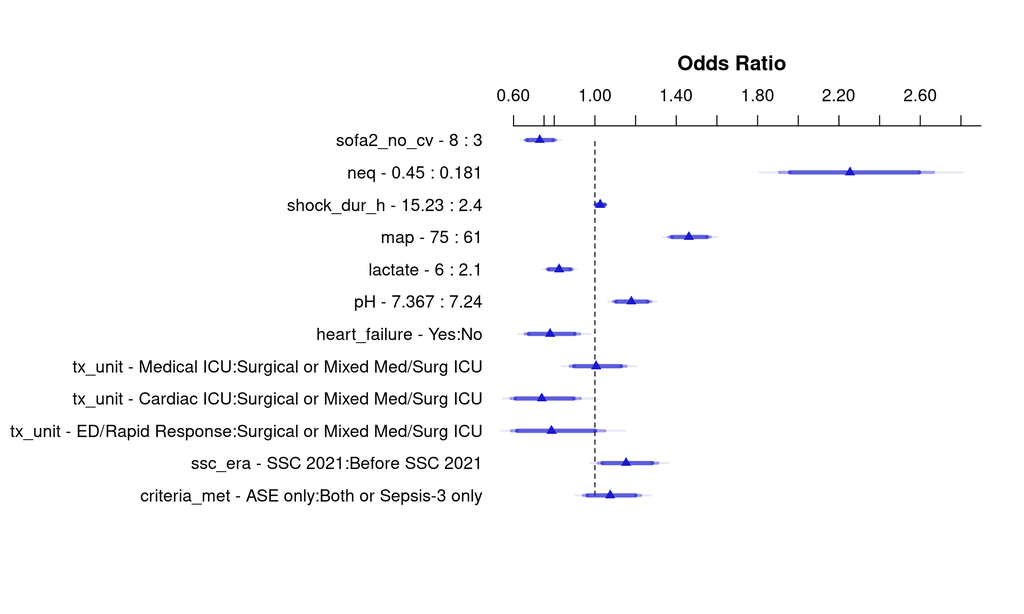

```r
plot(summary(avp_fit_rms))
```

Prediction plot.

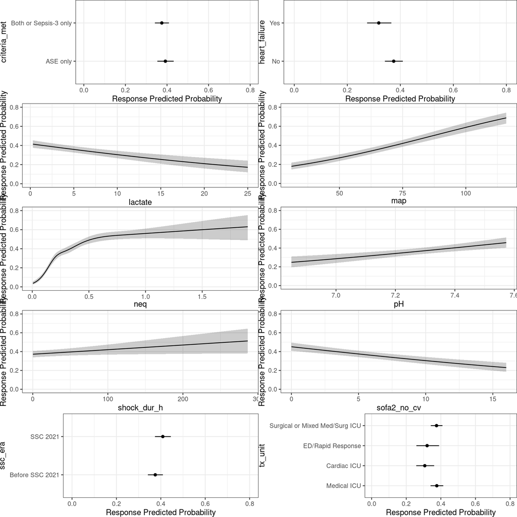

```r
ggplot(Predict(avp_fit_rms, fun = plogis),
       ylab = "Response Predicted Probability",
       layout = c(5,2)
       )
```

Variable importance plot.

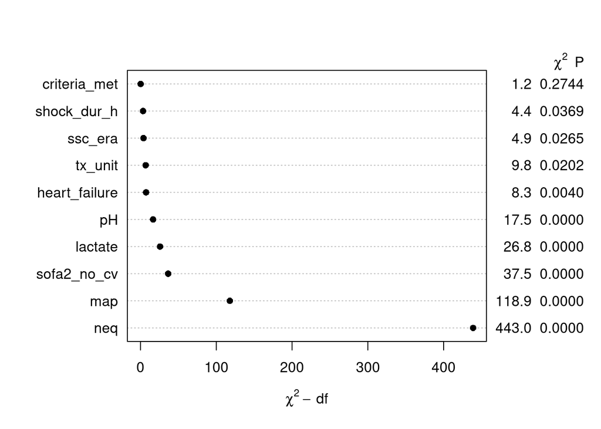

```r
plot(anova(avp_fit_rms, test="LR"))
```

Remove unnecessary objects created

```r
rm(avp_rms, dd, avp_fit_rms)
```

#### 12.2.6.2 Compare to Simple Model

Compare the selected multivariable model (`avp_m1_ns_logistic`) with a simple model that only includes `neq` with a spline term.

```r
lr_spec <-
  logistic_reg() |>
  set_engine("glm")

avp_m0_lr_rec_ns <-
  recipe(response ~ neq, data = avp) |>
  step_spline_natural(neq, deg_free = 5)

avp_m0_lr_preproc <- list(avp_m0_neq_only = avp_m0_lr_rec_ns,
                          avp_m1_multivar = avp_m1_lr_rec_ns
                          )

avp_m0_lr_model <-
  workflow_set(avp_m0_lr_preproc,
               list(logistic = logistic_reg(engine = "glm")),
               cross = FALSE
               )

set.seed(2026)
train_cv <- vfold_cv(avp, v = 10, repeats = 5, strata = response)
class_metrics <- metric_set(roc_auc, brier_class)
keep_pred <- control_resamples(save_pred = TRUE, save_workflow = FALSE)

avp_m0_lr_model_fit <-
  avp_m0_lr_model |>
  workflow_map("fit_resamples", seed = 2026, verbose = TRUE,
               resamples = train_cv, metrics = class_metrics,
               control = keep_pred
               )
```

```
i 1 of 2 resampling: avp_m0_neq_only_logistic
```

```
✔ 1 of 2 resampling: avp_m0_neq_only_logistic (11.6s)
```

```
i 2 of 2 resampling: avp_m1_multivar_logistic
```

```
✔ 2 of 2 resampling: avp_m1_multivar_logistic (26s)
```

```r
avp_m0_lr_preds <-
  collect_predictions(avp_m0_lr_model_fit, summarize = FALSE)

avp_m0_lr_mets <-
  collect_metrics(avp_m0_lr_model_fit) |>
  # Compute 95% Wald CIs across the 50 resamples
  mutate(
    conf.low.95 = mean - qt(0.975, df = 10*5-1) * std_err,
    conf.high.95 = mean + qt(0.975, df = 10*5-1) * std_err,
    mean_ci = sprintf("%.3f (%.3f, %.3f)", mean, conf.low.95, conf.high.95)
  ) |>
  select(wflow_id, .metric, mean, conf.low.95, conf.high.95, mean_ci) |>
  pivot_wider(
    names_from = .metric,
    values_from = c(mean_ci, mean, conf.low.95, conf.high.95)
    )

avp_m0_lr_mets |>
  select(wflow_id, mean_ci_roc_auc, mean_ci_brier_class) |>
  gt() |>
  tab_header(
    title = "Vasopressin Final Model Performance vs. NE Alone",
    subtitle = "Using 10-fold Cross-Validation (5 repeats). Presented as mean (95% CI)."
    ) |>
  cols_label(
    wflow_id = "Model",
    mean_ci_roc_auc = "AUROC",
    mean_ci_brier_class = "Brier Score",
    ) |>
  cols_align(
    align = "left",
    columns = c(wflow_id)
    ) |>
  cols_align(
    align = "center",
    columns = c(mean_ci_roc_auc, mean_ci_brier_class)
    )
```

Vasopressin Final Model Performance vs. NE Alone

Using 10-fold Cross-Validation (5 repeats). Presented as mean (95% CI).

| Model | AUROC | Brier Score |
| --- | --- | --- |
| avp_m0_neq_only_logistic | 0.636 (0.629, 0.643) | 0.214 (0.213, 0.215) |
| avp_m1_multivar_logistic | 0.700 (0.695, 0.706) | 0.202 (0.201, 0.203) |

The multivariable model has substantially better metrics than the simple model using `neq` alone. Using additional patient information beyond relying on norepinephrine dose alone provides meaningful improvement in the prediction of vasopressin response.

Show a non-stylized plot (autoplot) of the AUROC comparison.

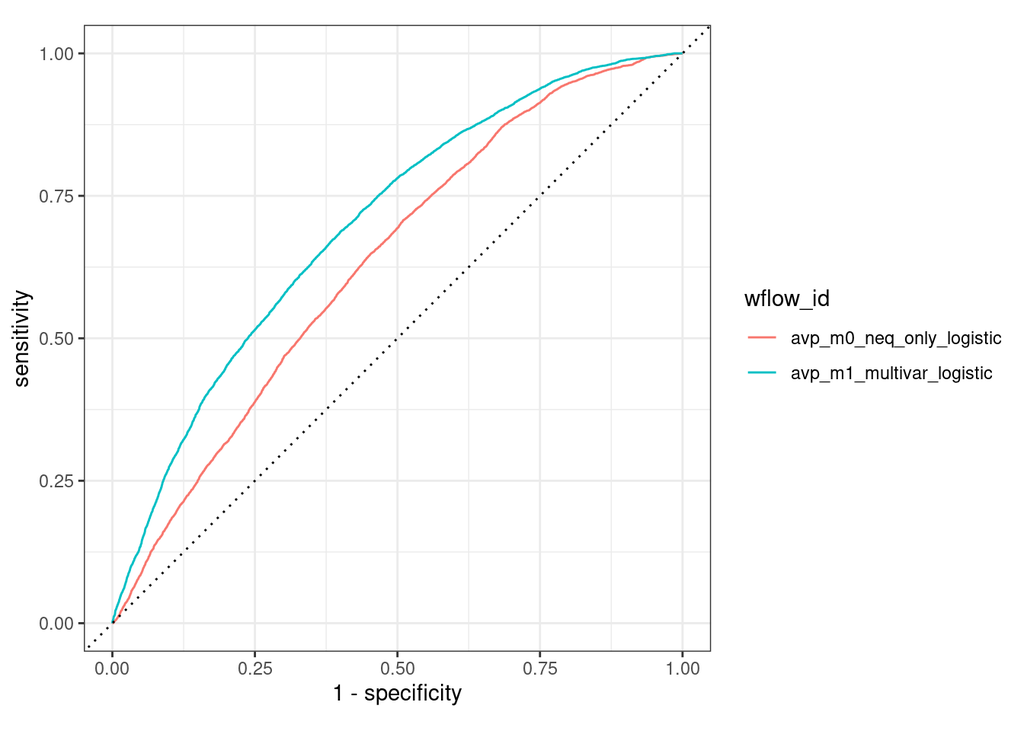

```r
avp_m0_lr_preds |>
  group_by(wflow_id) |>
  roc_curve(response, .pred_Response) |>
  autoplot()
```

The ROC curves are separated across essentially the entire plot range, with the multivariable model showing consistently better predictive discrimination than the univariable model only including norepinephrine dose (with a spline term).

Potential interpretation for manuscript: “Although norepinephrine dose is commonly used to estimate the likelihood of vasopressin response, a model based on norepinephrine dose alone demonstrated substantially lower discrimination (AUROC 0.636) and worse overall predictive performance (Brier score 0.214) than the multivariable model (AUROC 0.700, Brier score 0.202).”

## 12.3 Epinephrine

This section will build and evaluate prediction models for response after initiation of epinephrine as the first adjunctive vasopressor. The same approaches as for vasopressin models will be used here with less annotation. For more annotation regarding the rationale for model building and evaluation steps see Section 12.2.

### 12.3.1 Logistic Regression

Here, use logistic regression to generate prediction models using two approaches: 1) main effects (additive) only, and 2) non-linear effects of predictors.

The two models will be built in one `workflow_set()`. First, generate a Spearman’s $\rho^2$ rank correlation plot to assess for potential predictor transformation (non-linear effects).

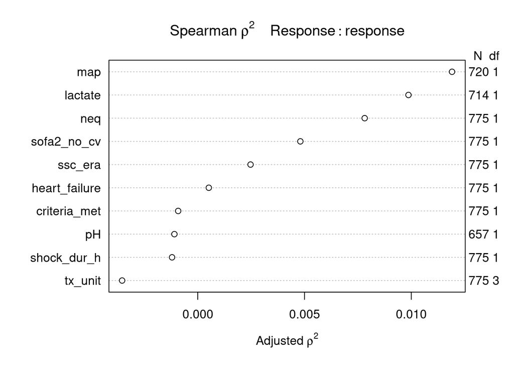

```r
plot(spearman2(response ~ ., data = epi |> select(-c(age, sex, race_eth))))
```

```r
invisible(pdf("epi_spearman.pdf"))
plot(spearman2(response ~ ., data = epi |> select(-c(age, sex, race_eth))),
     main = ""
     )
title(main = expression("Epinephrine Spearman " * rho^2))
invisible(dev.off())
```

The Spearman’s $\rho^2$ rank correlation plot shows that `map` has the highest potential to improve model fit with a non-linear transformation. Because this is a quantitative variable, introduce a natural spline with 3 knots (4 df) to spend all of the available degrees of freedom (12 df in the main effects model and 15 total available). Notably, all of the predictors have a relatively low $\rho^2$ value, therefore the non-linear model is not expected to substantially improve fit.

As noted in Section 11.5, there are missing data in the same three variables as for vasopressin. Therefore, the same imputation approach will be used.

```r
# Main effects recipe
epi_m1_lr_rec_main <-
  recipe(response ~ ., data = epi) |>
  # Declare age, sex, and race_eth in a bystander role to keep it in the
  # resampling dataset for future use in fairness checks
  update_role(age, sex, race_eth, new_role = "bystander") |>
  # Single (linear regression) imputation for missing quantitatitve predictors
  step_impute_linear(
    map,
    impute_with = vars(heart_failure, tx_unit, ssc_era, criteria_met,
                       sofa2_no_cv, neq, shock_dur_h
                       )
                     ) |>
  step_impute_linear(
    lactate,
    impute_with = vars(heart_failure, tx_unit, ssc_era, criteria_met,
                       sofa2_no_cv, neq, shock_dur_h, map
                       )
    ) |>
  step_impute_linear(
    pH,
    impute_with = vars(heart_failure, tx_unit, ssc_era, criteria_met,
                       sofa2_no_cv, neq, shock_dur_h, map, lactate
                       )
    )

# Non-linear effects recipe
epi_m1_lr_rec_ns <-
  recipe(response ~ ., data = epi) |>
  update_role(age, sex, race_eth, new_role = "bystander") |>
  step_impute_linear(
    map,
    impute_with = vars(heart_failure, tx_unit, ssc_era, criteria_met,
                       sofa2_no_cv, neq, shock_dur_h,
                       )
                     ) |>
  step_impute_linear(
    lactate,
    impute_with = vars(heart_failure, tx_unit, ssc_era, criteria_met,
                       sofa2_no_cv, neq, shock_dur_h, map,
                       )
    ) |>
  step_impute_linear(
    pH,
    impute_with = vars(heart_failure, tx_unit, ssc_era, criteria_met,
                       sofa2_no_cv, neq, shock_dur_h, map, lactate,
                       )
    ) |>
  # Add natural spline with 3 knots (4 df) for map
  step_spline_natural(map, deg_free = 4)

# Set up pre-processing and model workflow_set()
epi_m1_lr_preproc <- list(
  epi_m1_main = epi_m1_lr_rec_main,
  epi_m1_ns = epi_m1_lr_rec_ns
  )

epi_m1_lr_models <-
  workflow_set(epi_m1_lr_preproc,
               list(logistic = logistic_reg(engine = "glm")),
               cross = FALSE)

# Resample each model in the set with 10-fold CV (5 repeats)
set.seed(2026)
train_cv <- vfold_cv(epi, v = 10, repeats = 5, strata = response)
class_metrics <- metric_set(roc_auc, brier_class)
keep_pred <- control_resamples(save_pred = TRUE, save_workflow = FALSE)

epi_m1_lr_models_fit <-
  epi_m1_lr_models |>
  workflow_map("fit_resamples", seed = 2026, verbose = TRUE,
               resamples = train_cv, metrics = class_metrics,
               control = keep_pred
               )
```

```
i 1 of 2 resampling: epi_m1_main_logistic
```

```
✔ 1 of 2 resampling: epi_m1_main_logistic (18.3s)
```

```
i 2 of 2 resampling: epi_m1_ns_logistic
```

```
✔ 2 of 2 resampling: epi_m1_ns_logistic (19.7s)
```

```r
# Collect predictions
epi_m1_lr_preds <-
  collect_predictions(epi_m1_lr_models_fit, summarize = FALSE)

# Collect then show the metrics
epi_m1_lr_mets <-
  collect_metrics(epi_m1_lr_models_fit) |>
  mutate(
    conf.low.95 = mean - qt(0.975, df = 10*5-1) * std_err,
    conf.high.95 = mean + qt(0.975, df = 10*5-1) * std_err,
    mean_ci = sprintf("%.3f (%.3f, %.3f)", mean, conf.low.95, conf.high.95)
  ) |>
  select(wflow_id, .metric, mean, conf.low.95, conf.high.95, mean_ci) |>
  pivot_wider(
    names_from = .metric,
    values_from = c(mean_ci, mean, conf.low.95, conf.high.95)
    )

epi_m1_lr_mets |>
  select(wflow_id, mean_ci_roc_auc, mean_ci_brier_class) |>
  gt() |>
  tab_header(
    title = "Epinephrine m1 (Logistic Regression) Metric Comparison",
    subtitle = "Using 10-fold Cross-Validation (5 repeats). Presented as mean (95% CI)."
    ) |>
  cols_label(
    wflow_id = "Model",
    mean_ci_roc_auc = "AUROC",
    mean_ci_brier_class = "Brier Score",
    ) |>
  cols_align(
    align = "left",
    columns = c(wflow_id)
    ) |>
  cols_align(
    align = "center",
    columns = c(mean_ci_roc_auc, mean_ci_brier_class)
    )
```

Epinephrine m1 (Logistic Regression) Metric Comparison

Using 10-fold Cross-Validation (5 repeats). Presented as mean (95% CI).

| Model | AUROC | Brier Score |
| --- | --- | --- |
| epi_m1_main_logistic | 0.589 (0.571, 0.607) | 0.203 (0.201, 0.206) |
| epi_m1_ns_logistic | 0.589 (0.569, 0.609) | 0.204 (0.201, 0.207) |

The two logistic regression modeling approaches had essentially the same discrimination (AUROC) and overall performance (Brier score). The performance of both models was better than chance but not impressive.

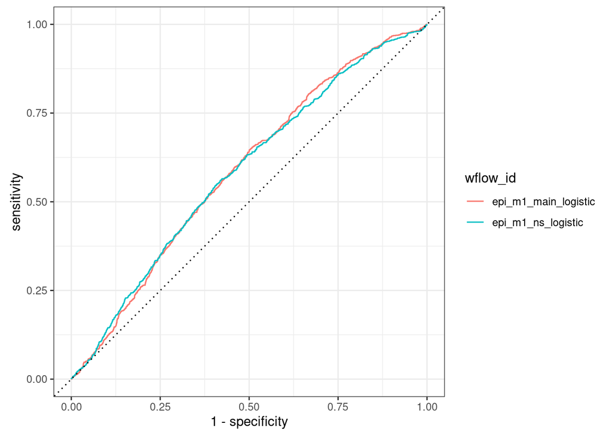

```r
epi_m1_lr_preds |>
  group_by(wflow_id) |>
  roc_curve(response, .pred_Response) |>
  autoplot()
```

The two curves have a lot of overlap. The non-linear (spline) model is slightly better at lower values and the main effects model is slightly better at higher values.

### 12.3.2 Machine Learning

#### 12.3.2.1 Regularized (Elastic Net)

Fit regularized (elastic net) models.

```r
epi_m2_rec_main <- epi_m1_lr_rec_main |>
  step_dummy(all_nominal_predictors()) |>
  step_normalize(all_numeric_predictors())

epi_m2_rec_ns <- epi_m1_lr_rec_ns |>
  step_dummy(all_nominal_predictors()) |>
  step_normalize(all_numeric_predictors())

epi_m2_glmnet_preproc <- list(
  epi_m2_main = epi_m2_rec_main,
  epi_m2_ns = epi_m2_rec_ns
  )

epi_m2_glmnet_models <-
  workflow_set(epi_m2_glmnet_preproc,
               list(glmnet = logistic_reg(
                 engine = "glmnet",
                 mode = "classification",
                 penalty = tune(),     # lambda
                 mixture = tune()      # alpha
                 )),
               cross = TRUE
               )

set.seed(2026)
train_cv <- vfold_cv(epi, v = 10, repeats = 5, strata = response)
class_metrics <- metric_set(roc_auc, brier_class)
keep_pred <- control_resamples(save_pred = TRUE, save_workflow = FALSE)

pen_grid <- grid_space_filling(
  penalty(range = c(-5, 0)), # log10 scale, reasonable range for elastic net
  mixture(range = c(0, 1)),  # default
  size = 30
  )

epi_m2_glmnet_models_fit <-
  epi_m2_glmnet_models |>
  workflow_map("tune_grid", seed = 2026, verbose = TRUE,
               resamples = train_cv, grid = pen_grid,
               metrics = class_metrics, control = keep_pred
               )
```

```
i 1 of 2 tuning:     epi_m2_main_glmnet
```

```
✔ 1 of 2 tuning:     epi_m2_main_glmnet (1m 40.5s)
```

```
i 2 of 2 tuning:     epi_m2_ns_glmnet
```

```
✔ 2 of 2 tuning:     epi_m2_ns_glmnet (1m 45s)
```

```r
workflow_ids <- epi_m2_glmnet_models_fit$wflow_id

# Loop over workflows to finalize, fit, and collect results
epi_m2_glmnet_final_fit <- map(workflow_ids, function(wf_id) {

  # Extract tuning results for this workflow
  wf_result <- extract_workflow_set_result(epi_m2_glmnet_models_fit, id = wf_id)

  # Get best parameters by AUROC
  best_params <- select_best(wf_result, metric = "roc_auc")

  # Extract the workflow object itself
  wf <- extract_workflow(epi_m2_glmnet_models_fit, id = wf_id)

  # Finalize the workflow with best hyperparameters
  final_wf <- finalize_workflow(
    wf,
    best_params
  )

  # Fit the final workflow to the training set
  final_fit <- fit(final_wf, data = epi)

  # Collect resampling metrics for this workflow from tuning
  cv_metrics <- collect_metrics(wf_result) |>
    filter(penalty == best_params$penalty,
           mixture == best_params$mixture)

  # Collect predictions for the best parameters
  cv_preds <- collect_predictions(wf_result, summarize = TRUE) |>
    filter(penalty == best_params$penalty,
           mixture == best_params$mixture)

  # Return as a list
  list(
    workflow_id = wf_id,
    best_params = best_params,
    final_workflow = final_wf,
    final_fit = final_fit,
    cv_metrics = cv_metrics,
    cv_predictions = cv_preds
  )
})

# Name the list elements by workflow
names(epi_m2_glmnet_final_fit) <- workflow_ids
rm(workflow_ids)
```

Show elastic net hyperparameters resulting in the best fit.

```r
imap_dfr(epi_m2_glmnet_final_fit,
         ~ .x$best_params |> mutate(wflow_id = .y)
         ) |>
  select(wflow_id, penalty, mixture) |>
  gt() |>
  tab_header(
    title = "Epinephrine m2 Elastic Net Best Hyperparameters",
    subtitle = "Using 10-fold Cross-Validation (5 repeats)"
    ) |>
  cols_label(
    wflow_id = "Model",
    penalty = "Penalty (lambda [λ])",
    mixture = "Mixture (alpha [α])"
    ) |>
  fmt_number(decimals = 4) |>
  cols_align(
    align = "left",
    columns = c(wflow_id)
    ) |>
  cols_align(
    align = "center",
    columns = c(penalty, mixture)
    )
```

Epinephrine m2 Elastic Net Best Hyperparameters

Using 10-fold Cross-Validation (5 repeats)

| Model | Penalty (lambda [λ]) | Mixture (alpha [α]) |
| --- | --- | --- |
| epi_m2_main_glmnet | 0.0085 | 0.8966 |
| epi_m2_ns_glmnet | 0.0189 | 0.7241 |

Collect metrics and display table (comparing to the logistic regression model fits).

```r
epi_m2_glmnet_mets <-
 epi_m2_glmnet_final_fit |> map(function(x) {
    x$cv_metrics |>
    mutate(wflow_id = x$workflow_id)
  }) |>
  list_rbind() |>
  mutate(
    conf.low.95 = mean - qt(0.975, df = 10*5-1) * std_err,
    conf.high.95 = mean + qt(0.975, df = 10*5-1) * std_err,
    mean_ci = sprintf("%.3f (%.3f, %.3f)", mean, conf.low.95, conf.high.95)
  ) |>
  select(wflow_id, .metric, mean, conf.low.95, conf.high.95, mean_ci) |>
  pivot_wider(
    names_from = .metric,
    values_from = c(mean_ci, mean, conf.low.95, conf.high.95)
    )

bind_rows(epi_m1_lr_mets, epi_m2_glmnet_mets)  |>
  select(wflow_id, mean_ci_roc_auc, mean_ci_brier_class) |>
  gt() |>
  tab_header(
    title = "Epinephrine m2 (Elastic Net) Metric Comparison",
    subtitle = "Using 10-fold Cross-Validation (5 repeats). Presented as mean (95% CI)."
    ) |>
  cols_label(
    wflow_id = "Model",
    mean_ci_roc_auc = "AUROC",
    mean_ci_brier_class = "Brier Score",
    ) |>
  cols_align(
    align = "left",
    columns = c(wflow_id)
    ) |>
  cols_align(
    align = "center",
    columns = c(mean_ci_roc_auc, mean_ci_brier_class)
    )
```

Epinephrine m2 (Elastic Net) Metric Comparison

Using 10-fold Cross-Validation (5 repeats). Presented as mean (95% CI).

| Model | AUROC | Brier Score |
| --- | --- | --- |
| epi_m1_main_logistic | 0.589 (0.571, 0.607) | 0.203 (0.201, 0.206) |
| epi_m1_ns_logistic | 0.589 (0.569, 0.609) | 0.204 (0.201, 0.207) |
| epi_m2_main_glmnet | 0.595 (0.578, 0.611) | 0.201 (0.199, 0.203) |
| epi_m2_ns_glmnet | 0.597 (0.579, 0.615) | 0.201 (0.199, 0.202) |

The regularized (elastic net) models performed slightly better than the logistic regression models.

#### 12.3.2.2 Random Forest

Fit a random forest model.

```r
epi_m3_rf_rec <-
  recipe(response ~ ., data = epi) |>
  # Declare age, sex, and race_eth in a bystander role to keep it in the
  # resampling dataset for future use in fairness checks
  update_role(age, sex, race_eth, new_role = "bystander") |>
  # Single (linear regression) imputation for missing quantitative predictors
  step_impute_linear(
    map,
    impute_with = vars(heart_failure, tx_unit, ssc_era, criteria_met,
                       sofa2_no_cv, neq, shock_dur_h
                       )
                     ) |>
  step_impute_linear(
    lactate,
    impute_with = vars(heart_failure, tx_unit, ssc_era, criteria_met,
                       sofa2_no_cv, neq, shock_dur_h, map
                       )
    ) |>
  step_impute_linear(
    pH,
    impute_with = vars(heart_failure, tx_unit, ssc_era, criteria_met,
                       sofa2_no_cv, neq, shock_dur_h, map, lactate
                       )
    )

epi_m3_rf_preproc <- list(epi_m3_rf = epi_m3_rf_rec)

epi_m3_rf_models <-
  workflow_set(epi_m3_rf_preproc,
               list(ranger = rand_forest(
                 engine = "ranger",
                 mode = "classification",
                 trees = 1000,      # Default is 500, 1000 is better
                 mtry = tune(),     # Number of randomly selected predictors
                 min_n = tune()     # Minimum node size
                 )),
               cross = TRUE
               )

set.seed(2026)
train_cv <- vfold_cv(epi, v = 10, repeats = 5, strata = response)
class_metrics <- metric_set(roc_auc, brier_class)
keep_pred <- control_resamples(save_pred = TRUE, save_workflow = FALSE)

# Prep recipe and determine predictor count
epi_m3_rf_rec_prep <- prep(epi_m3_rf_rec)

x_train <- bake(epi_m3_rf_rec_prep, new_data = NULL) |>
  select(-c(response, age, sex, race_eth))

p <- ncol(x_train) # p == 10

rf_param_set <- parameters(
  mtry(range = c(1L, 10L)), #sqrt(p) ~= 3, (p / 2) == 5, which is too narrow
  min_n(range = c(2L, 50L))
)

initial_candidates <- grid_space_filling(
  rf_param_set,
  size = 30
)

race_ctrl <- control_race(
  save_pred = TRUE,
  save_workflow = TRUE,
  parallel_over = "resamples",
  verbose = FALSE
)

epi_m3_rf_model_fit <-
  epi_m3_rf_models |>
  workflow_map(
    "tune_race_anova", seed = 2026, resamples = train_cv,
    grid = initial_candidates, metrics = class_metrics, control = race_ctrl
  )

# Get workflow IDs
workflow_ids <- epi_m3_rf_model_fit$wflow_id

# Finalize, fit, and collect results for the workflow
epi_m3_rf_final_fit <- map(workflow_ids, function(wf_id) {
  # Extract tuning (race) results for this workflow
  wf_result <- extract_workflow_set_result(
    epi_m3_rf_model_fit,
    id = wf_id
    )
  # Select best hyperparameters by AUROC
  best_params <- select_best(wf_result, metric = "roc_auc")
  # Extract the workflow itself
  wf <- extract_workflow(epi_m3_rf_model_fit, id = wf_id)
  # Finalize workflow with best hyperparameters
  final_wf <- finalize_workflow(wf, best_params)
  # Fit finalized workflow to derivation data
  final_fit <- fit(final_wf, data = epi)
  # Collect CV metrics for the selected configuration
  cv_metrics <- collect_metrics(wf_result) |>
    filter(.config == best_params$.config)
  # Collect CV predictions for the selected configuration
  cv_predictions <- collect_predictions(wf_result) |>
    filter(.config == best_params$.config)
  # Return results
  list(
    workflow_id     = wf_id,
    best_params     = best_params,
    final_workflow  = final_wf,
    final_fit       = final_fit,
    cv_metrics      = cv_metrics,
    cv_predictions  = cv_predictions
    )
})

names(epi_m3_rf_final_fit) <- map_chr(epi_m3_rf_final_fit, "workflow_id")
```

Show hyperparameters resulting in the best fit.

```r
imap_dfr(epi_m3_rf_final_fit,
         ~ .x$best_params |> mutate(workflow_id = .y)
         ) |>
  select(workflow_id, mtry, min_n) |>
  gt() |>
  tab_header(
    title = "Random Forest Best Hyperparameters",
    subtitle = "Using 10-fold Cross-Validation (5 repeats)"
    ) |>
  cols_label(
    workflow_id = "Model",
    mtry = "Random Variables at Split (mtry)",
    min_n = "Min Terminal Node Size (min_n)"
    ) |>
  fmt_number(decimals = 0) |>
  cols_align(
    align = "left",
    columns = c(workflow_id)
    ) |>
  cols_align(
    align = "center",
    columns = c(mtry, min_n)
    )
```

Random Forest Best Hyperparameters

Using 10-fold Cross-Validation (5 repeats)

| Model | Random Variables at Split (mtry) | Min Terminal Node Size (min_n) |
| --- | --- | --- |
| epi_m3_rf_ranger | 2 | 48 |

Collect and display metrics for model.

```r
epi_m3_rf_mets <-
 epi_m3_rf_final_fit |> map(function(x) {
    x$cv_metrics |>
    mutate(wflow_id = x$workflow_id)
  }) |>
  list_rbind() |>
  mutate(
    conf.low.95 = mean - qt(0.975, df = 10*5-1) * std_err,
    conf.high.95 = mean + qt(0.975, df = 10*5-1) * std_err,
    mean_ci = sprintf("%.3f (%.3f, %.3f)", mean, conf.low.95, conf.high.95)
  ) |>
  select(wflow_id, .metric, mean, conf.low.95, conf.high.95, mean_ci) |>
  pivot_wider(
    names_from = .metric,
    values_from = c(mean_ci, mean, conf.low.95, conf.high.95)
    )

bind_rows(epi_m1_lr_mets,
          epi_m2_glmnet_mets,
          epi_m3_rf_mets)  |>
  select(wflow_id, mean_ci_roc_auc, mean_ci_brier_class) |>
  gt() |>
  tab_header(
    title = "Epinephrine m3 (Random Forest) Metric Comparison",
    subtitle = "Using 10-fold Cross-Validation (5 repeats). Presented as mean (95% CI)."
    ) |>
  cols_label(
    wflow_id = "Model",
    mean_ci_roc_auc = "AUROC",
    mean_ci_brier_class = "Brier Score",
    ) |>
  cols_align(
    align = "left",
    columns = c(wflow_id)
    ) |>
  cols_align(
    align = "center",
    columns = c(mean_ci_roc_auc, mean_ci_brier_class)
    )
```

Epinephrine m3 (Random Forest) Metric Comparison

Using 10-fold Cross-Validation (5 repeats). Presented as mean (95% CI).

| Model | AUROC | Brier Score |
| --- | --- | --- |
| epi_m1_main_logistic | 0.589 (0.571, 0.607) | 0.203 (0.201, 0.206) |
| epi_m1_ns_logistic | 0.589 (0.569, 0.609) | 0.204 (0.201, 0.207) |
| epi_m2_main_glmnet | 0.595 (0.578, 0.611) | 0.201 (0.199, 0.203) |
| epi_m2_ns_glmnet | 0.597 (0.579, 0.615) | 0.201 (0.199, 0.202) |
| epi_m3_rf_ranger | 0.590 (0.574, 0.605) | 0.201 (0.199, 0.203) |

The random forest model performed similarly to the logistic regression models and slightly worse than the elastic net model.

#### 12.3.2.3 Boosted Trees

Generate a boosted tree model.

```r
epi_m4_xgb_rec <-
  recipe(response ~ ., data = epi) |>
  update_role(age, sex, race_eth, new_role = "bystander") |>
  step_impute_linear(
    map,
    impute_with = vars(
      heart_failure, tx_unit, ssc_era,
      criteria_met, sofa2_no_cv,
      neq, shock_dur_h
    )
  ) |>
  step_impute_linear(
    lactate,
    impute_with = vars(
      heart_failure, tx_unit, ssc_era,
      criteria_met, sofa2_no_cv,
      neq, shock_dur_h, map
    )
  ) |>
  step_impute_linear(
    pH,
    impute_with = vars(
      heart_failure, tx_unit, ssc_era,
      criteria_met, sofa2_no_cv,
      neq, shock_dur_h, map, lactate
    )
  ) |>
  # Dummy code nominal predictors
  step_dummy(all_nominal_predictors())

epi_m4_xgb_preproc <- list(epi_m4_boost = epi_m4_xgb_rec)

epi_m4_xgb_model <-
  workflow_set(epi_m4_xgb_preproc,
               list(xgboost = boost_tree(
                 trees = 1000,              # Number of trees
                 tree_depth = tune(),       # Tree depth: # of "interactions"
                 min_n = tune(),            # Minimum node size
                 loss_reduction = tune(),   # Reduction in the loss function required to split further
                 sample_size = tune(),      # Proportion of data exposed to fitting routine
                 mtry = tune(),             # Random predictors at each split
                 learn_rate = tune()        # Rate at which the boosting algorithm adapts
                 ) |>
                   set_engine("xgboost") |>
                   set_mode("classification")
                 ),
               cross = FALSE
               )

set.seed(2026)
train_cv <- vfold_cv(epi, v = 10, repeats = 5, strata = response)
class_metrics <- metric_set(roc_auc, brier_class)
keep_pred <- control_resamples(save_pred = TRUE, save_workflow = FALSE)

# Prep recipe and determine post-dummy predictor count
epi_m4_xgb_rec_prep <- prep(epi_m4_xgb_rec)

x_train <- bake(epi_m4_xgb_rec_prep, new_data = NULL) |>
  select(-c(response, age, sex, race_eth))

p <- ncol(x_train) # p == 10

# Select parameters (particularly depth) based p==10 and RF optimal parameters
xgb_params <- parameters(
  tree_depth(range = c(1L, 6L)),
  min_n(range = c(2L, 50L)),
  learn_rate(range = c(-3, -0.5)),
  loss_reduction(),
  sample_prop(range = c(0.5, 1.0)),
  finalize(mtry(), x_train)
  )

initial_candidates <- grid_space_filling(
  xgb_params,
  size = 30
  )

race_ctrl <- control_race(
  save_pred = TRUE,
  save_workflow = TRUE,
  parallel_over = "resamples",
  verbose = FALSE
  )

epi_m4_xgb_model_fit <-
  epi_m4_xgb_model |>
  workflow_map(
    "tune_race_anova",
    seed = 2026,
    resamples = train_cv,
    grid = initial_candidates,
    metrics = class_metrics,
    control = race_ctrl
    )

workflow_ids <- epi_m4_xgb_model_fit$wflow_id

# Finalize, fit, and collect results the workflow
epi_m4_xgb_final_fit <- map(workflow_ids, function(wf_id) {
  # Extract tuning (race) results for this workflow
  wf_result <- extract_workflow_set_result(
    epi_m4_xgb_model_fit,
    id = wf_id
    )
  # Select best hyperparameters by AUROC
  best_params <- select_best(wf_result, metric = "roc_auc")
  # Extract the workflow itself
  wf <- extract_workflow(epi_m4_xgb_model_fit, id = wf_id)
  # Finalize workflow with best hyperparameters
  final_wf <- finalize_workflow(wf, best_params)
  # Fit finalized workflow to derivation data
  final_fit <- fit(final_wf, data = epi)
  # Collect CV metrics for the selected configuration
  cv_metrics <- collect_metrics(wf_result) |>
    filter(.config == best_params$.config)
  # Collect CV predictions for the selected configuration
  cv_predictions <- collect_predictions(wf_result) |>
    filter(.config == best_params$.config)
  # Return results
  list(
    workflow_id     = wf_id,
    best_params     = best_params,
    final_workflow  = final_wf,
    final_fit       = final_fit,
    cv_metrics      = cv_metrics,
    cv_predictions  = cv_predictions
    )
})

names(epi_m4_xgb_final_fit) <- map_chr(epi_m4_xgb_final_fit, "workflow_id")
```

Show hyperparameters resulting in the best fit.

```r
imap_dfr(epi_m4_xgb_final_fit,
         ~ .x$best_params |> mutate(wflow_id = .y)
         ) |>
  mutate(trees = 1000) |>
  select(wflow_id, trees, tree_depth, min_n, learn_rate, loss_reduction,
         sample_size, mtry
         ) |>
  gt() |>
  fmt_number(columns = c(learn_rate, loss_reduction, sample_size),
             decimals = 3
             ) |>
  tab_header(
    title = "Gradient Boosted Model Best Hyperparameters",
    subtitle = "Using 10-fold Cross-Validation (5 repeats)"
    ) |>
  cols_label(
    wflow_id = "Model",
    trees = "Trees",
    tree_depth = "Tree Depth",
    min_n = "Node Size",
    learn_rate = "Learn Rate",
    loss_reduction = "Min Loss Reduction",
    sample_size = "Proportion of data exposed",
    mtry = "Predictors at Splits",
    ) |>
  cols_align(
    align = "left",
    columns = c(wflow_id)
    ) |>
  cols_align(
    align = "center",
    columns = c(trees, tree_depth, min_n, learn_rate, loss_reduction,
                sample_size, mtry
                )
    )
```

Gradient Boosted Model Best Hyperparameters

Using 10-fold Cross-Validation (5 repeats)

| Model | Trees | Tree Depth | Node Size | Learn Rate | Min Loss Reduction | Proportion of data exposed | Predictors at Splits |
| --- | --- | --- | --- | --- | --- | --- | --- |
| epi_m4_boost_xgboost | 1000 | 2 | 13 | 0.006 | 0.000 | 0.638 | 3 |

Optimal parameters are not at tuning boundaries. The algorithm preferred shallow trees with iterative small improvements (over aggressive boosting), which is consistent with the random forest findings.

Collect and display metrics for model.

```r
epi_m4_xgb_mets <-
 epi_m4_xgb_final_fit |> map(function(x) {
    x$cv_metrics |>
    mutate(wflow_id = x$workflow_id)
  }) |>
  list_rbind() |>
  mutate(
    conf.low.95 = mean - qt(0.975, df = 10*5-1) * std_err,
    conf.high.95 = mean + qt(0.975, df = 10*5-1) * std_err,
    mean_ci = sprintf("%.3f (%.3f, %.3f)", mean, conf.low.95, conf.high.95)
  ) |>
  select(wflow_id, .metric, mean, conf.low.95, conf.high.95, mean_ci) |>
  pivot_wider(
    names_from = .metric,
    values_from = c(mean_ci, mean, conf.low.95, conf.high.95)
    )

bind_rows(epi_m1_lr_mets,
          epi_m2_glmnet_mets,
          epi_m3_rf_mets,
          epi_m4_xgb_mets
          )  |>
  select(wflow_id, mean_ci_roc_auc, mean_ci_brier_class) |>
  gt() |>
  tab_header(
    title = "Epinephrine m4 (XGBoost) Metric Comparison",
    subtitle = "Using 10-fold Cross-Validation (5 repeats). Presented as mean (95% CI)."
    ) |>
  cols_label(
    wflow_id = "Model",
    mean_ci_roc_auc = "AUROC",
    mean_ci_brier_class = "Brier Score",
    ) |>
  cols_align(
    align = "left",
    columns = c(wflow_id)
    ) |>
  cols_align(
    align = "center",
    columns = c(mean_ci_roc_auc, mean_ci_brier_class)
    )
```

Epinephrine m4 (XGBoost) Metric Comparison

Using 10-fold Cross-Validation (5 repeats). Presented as mean (95% CI).

| Model | AUROC | Brier Score |
| --- | --- | --- |
| epi_m1_main_logistic | 0.589 (0.571, 0.607) | 0.203 (0.201, 0.206) |
| epi_m1_ns_logistic | 0.589 (0.569, 0.609) | 0.204 (0.201, 0.207) |
| epi_m2_main_glmnet | 0.595 (0.578, 0.611) | 0.201 (0.199, 0.203) |
| epi_m2_ns_glmnet | 0.597 (0.579, 0.615) | 0.201 (0.199, 0.202) |
| epi_m3_rf_ranger | 0.590 (0.574, 0.605) | 0.201 (0.199, 0.203) |
| epi_m4_boost_xgboost | 0.619 (0.605, 0.633) | 0.198 (0.196, 0.200) |

The XGBoost performed better than each of the previous models.

### 12.3.3 Discrimination/Accuracy Comparison

Now, show the discrimination and accuracy metrics for all models.

```r
(epi_disc_perf_mets <- bind_rows(epi_m1_lr_mets,
          epi_m2_glmnet_mets,
          epi_m3_rf_mets,
          epi_m4_xgb_mets
          )  |>
  select(wflow_id, mean_ci_roc_auc, mean_ci_brier_class) |>
  gt() |>
  tab_header(
    title = "Epinephrine Models Discrimination/Overall Performance Metric Comparison",
    subtitle = "Using 10-fold Cross-Validation (5 repeats). Presented as mean (95% CI)."
    ) |>
  cols_label(
    wflow_id = "Model",
    mean_ci_roc_auc = "AUROC",
    mean_ci_brier_class = "Brier Score",
    ) |>
  cols_align(
    align = "left",
    columns = c(wflow_id)
    ) |>
  cols_align(
    align = "center",
    columns = c(mean_ci_roc_auc, mean_ci_brier_class)
    ))
```

Epinephrine Models Discrimination/Overall Performance Metric Comparison

Using 10-fold Cross-Validation (5 repeats). Presented as mean (95% CI).

| Model | AUROC | Brier Score |
| --- | --- | --- |
| epi_m1_main_logistic | 0.589 (0.571, 0.607) | 0.203 (0.201, 0.206) |
| epi_m1_ns_logistic | 0.589 (0.569, 0.609) | 0.204 (0.201, 0.207) |
| epi_m2_main_glmnet | 0.595 (0.578, 0.611) | 0.201 (0.199, 0.203) |
| epi_m2_ns_glmnet | 0.597 (0.579, 0.615) | 0.201 (0.199, 0.202) |
| epi_m3_rf_ranger | 0.590 (0.574, 0.605) | 0.201 (0.199, 0.203) |
| epi_m4_boost_xgboost | 0.619 (0.605, 0.633) | 0.198 (0.196, 0.200) |

The XGBoost model (`epi_m4_boost_xgboost`) had the best performance and the logistic regression models had the worst performance. Will carry forward the XGBoost model for calibration assessment prior to final model selection.

Export comparison table to Word

```r
gtsave(
  data = epi_disc_perf_mets,
  filename = "epi_disc_perf_metrics.docx"
)
```

### 12.3.4 Calibration

Use the same calibration approach as in Section 12.2.4 that was used for vasopressin.

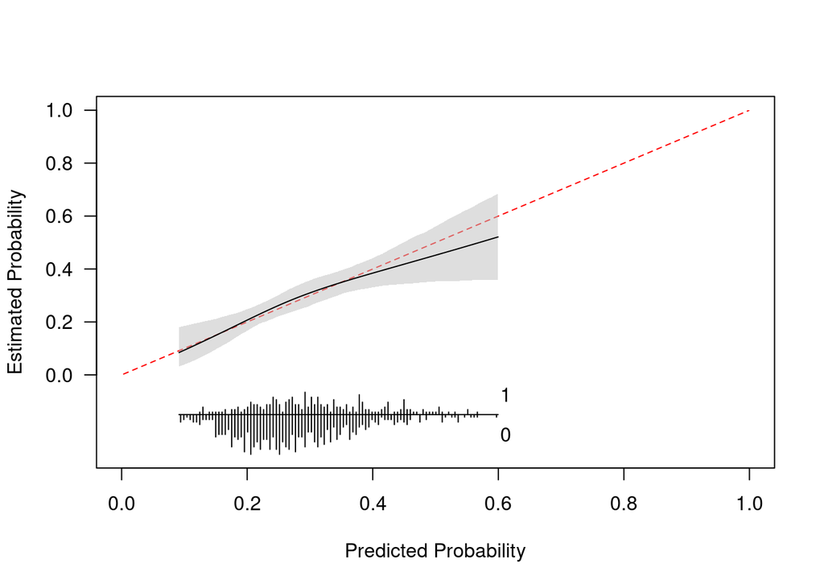

```r
epi_m4_xgb_preds <- epi_m4_xgb_final_fit[[1]]$cv_predictions

epi_m4_xgb_preds_cv <- epi_m4_xgb_preds |>
  group_by(.row) |>
  summarise(
    response = first(response),
    .pred_Response = mean(.pred_Response),
    .groups = "drop"
  ) |>
  mutate(
    response_num = if_else(response == "Response", 1, 0)
  )

set.seed(2026)
epi_xgb_cal <- pmcalibration(
  y = epi_m4_xgb_preds_cv$response_num,
  p = epi_m4_xgb_preds_cv$.pred_Response,
  ci = "boot", # n = 1000 replicates is the default
  smooth = "rcs",
  nk = 3 # 5 knots is default, 3 has less bias
  )
```

```r
invisible(pdf("epi_xgboost_calibration.pdf"))
par(mfrow = c(1, 1),
    cex.axis = 1.4, cex.lab = 1.8, cex.main = 2,
    mar = c(5.1, 5.5, 1.4, 1.6), # bottom, left, top, right
    mgp = c(3.5, 1, 0)
    )
plot(epi_xgb_cal)
invisible(dev.off())
```

The calibration of the epinephrine XGBoost model is good, with some over-prediction at higher probabilities (above ~0.4) where data are sparse.

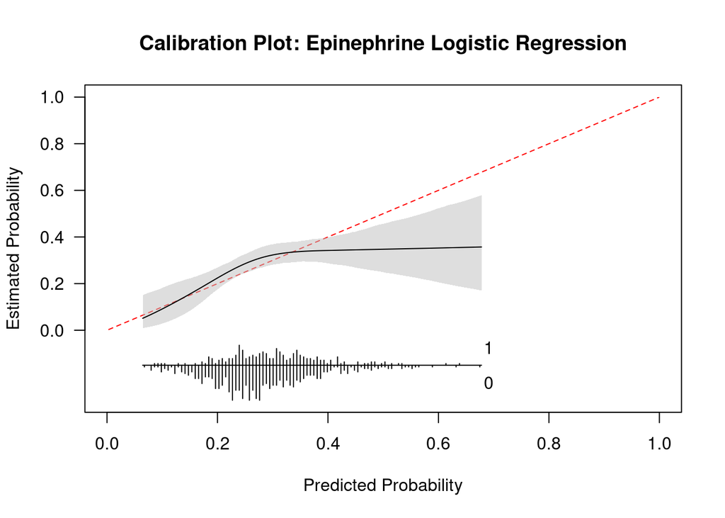

```r
epi_m1_lr_preds_cv <- epi_m1_lr_preds |>
  filter(wflow_id == "epi_m1_main_logistic") |>
  group_by(.row) |>
  summarise(
    response = first(response),
    .pred_Response = mean(.pred_Response),
    .groups = "drop"
  ) |>
  mutate(
    response_num = if_else(response == "Response", 1, 0)
  )

set.seed(2026)
epi_lr_cal <- pmcalibration(
  y = epi_m1_lr_preds_cv$response_num,
  p = epi_m1_lr_preds_cv$.pred_Response,
  ci = "boot", # n = 1000 replicates is the default
  smooth = "rcs",
  nk = 3 # 5 knots is default, 3 has less bias
  )
plot(epi_lr_cal)
title("Calibration Plot: Epinephrine Logistic Regression")
```

```r
par(mfrow = c(1, 1))
invisible(dev.copy(pdf, "epi_logistic_calibration.pdf"))
invisible(dev.off())
```

Calibration with the main effects logistic regression model appears worse than the XGBoost model, but it is challenging to assess the upper range because of few observations.

Save the two epinephrine calibration plots as a panel figure.

```r
invisible(ragg::agg_tiff("epi_calibration_panel.tiff",
                         width = 11, height = 5, units = "in",
                         res = 600, compression = "lzw"
                         ))

par(mfrow = c(1, 2), pty = "s")

plot(epi_lr_cal)
title("Epinephrine Logistic Regression (Main)")

plot(epi_xgb_cal)
title("Epinephrine XGBoost")

par(mfrow = c(1, 1))
invisible(dev.off())
```

Show the quantitative calibration metrics for comparison.

```r
(epi_cal_metrics_tbl <-
   bind_rows(
    as_tibble(epi_lr_cal$metrics, rownames = "metric") |>
      mutate(model = "Logistic (main)"),
    as_tibble(epi_xgb_cal$metrics, rownames = "metric") |>
      mutate(model = "XGBoost")
  ) |>
  select(model, metric, value) |>
  pivot_wider(
    names_from = metric,
    values_from = value
  ) |>
  rename(
    Model = model,
    `Eavg (ICI)` = Eavg
  ) |>
  gt() |>
  tab_header(
    title = "Epinephrine Models Calibration Metrics"
  ) |>
  fmt_number(
    columns = c(`Eavg (ICI)`, E50, E90, Emax, ECI),
    decimals = 4
  ) |>
  cols_align(
    align = "center"
  ))
```

Epinephrine Models Calibration Metrics

| Model | Eavg (ICI) | E50 | E90 | Emax | ECI |
| --- | --- | --- | --- | --- | --- |
| Logistic (main) | 0.0352 | 0.0300 | 0.0626 | 0.3208 | 0.2720 |
| XGBoost | 0.0114 | 0.0095 | 0.0221 | 0.0785 | 0.0257 |

Calibration is better for the epinephrine XGBoost model.

Export comparison table to Word

```r
gtsave(
  data = epi_cal_metrics_tbl,
  filename = "epi_cal_metric_comparison.docx"
)
```

### 12.3.5 Decision Curve Analysis

Extract predictions from the XGBoost and logistic regression models, then combine.

```r
# Extract the out-of-fold predictions for each model
# Then average predictions across the 5 CV repeats using .row
# Logistic model
epi_lr_dca <- epi_m1_lr_preds |>
  filter(wflow_id == "epi_m1_main_logistic") |>
  group_by(.row) |>
  summarise(
    response = first(response),
    p_logistic = mean(.pred_Response),
    .groups = "drop"
  )

# XGBoost model
epi_xgb_dca <- epi_m4_xgb_final_fit[[1]]$cv_predictions |>
  group_by(.row) |>
  summarise(
    p_xgb = mean(.pred_Response),
    .groups = "drop"
  )

# Combine
epi_dca_data <- epi_lr_dca |>
  left_join(epi_xgb_dca, by = ".row")
```

Then run DCA and plot.

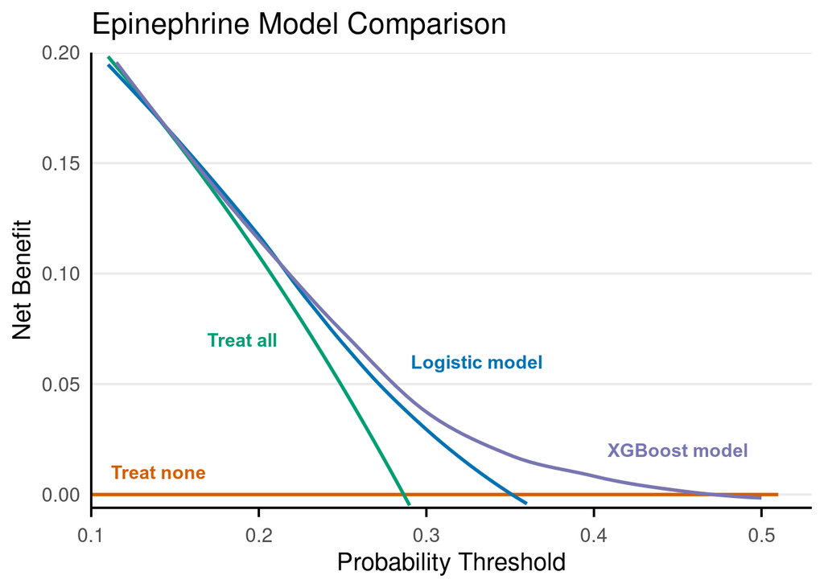

```r
epi_dca <- dca(
  response == "Response" ~ p_logistic + p_xgb,
  data = epi_dca_data
  )

(epi_dca_plot <-
    ggplot(as_tibble(epi_dca) |>
             filter(net_benefit >= -0.006 &
                      net_benefit <= 0.2 &
                      threshold <=0.51
                    ) |>
             mutate(label = fct_relevel(label, "Treat None", "Treat All",
                                        "p_logistic", "p_xgb"
                                        )),
           aes(x = threshold,
               y = net_benefit,
               color = label,
               group = label)) +
    geom_smooth(method = loess, formula = y ~ x, se = FALSE, linewidth = 1) +
    scale_color_manual(values = c(
      "p_logistic" = "#0072B2",
      "p_xgb" = "#7876B1FF",
      "Treat All" = "#009E73",
      "Treat None" = "#D55E00"
      ),
      labels = c(
        "p_logistic" = "Logistic regression",
        "p_xgb" = "XGBoost",
        "Treat All" = "Treat all",
        "Treat None" = "Treat none"
      )) +
    scale_y_continuous(
      limits = c(-0.006, 0.2),
      expand = expansion(add = c(0, 0))
      ) +
    scale_x_continuous(
      limits = c(0.1, 0.51),
      breaks = seq(0,0.5, by = 0.1),
      expand = expansion(add = c(0, 0.02))
      ) +
    labs(
      title = "Epinephrine Model Comparison",
      x = "Probability Threshold",
      y = "Net Benefit",
      color = NULL
      ) +
    annotate("text", x = 0.33, y = 0.06, label = "Logistic model",
             color = "#0072B2", family = "Arial", fontface = "bold",
             size = 4
             ) +
    annotate("text", x = 0.45, y = 0.02, label = "XGBoost model",
             color = "#7876B1FF", family = "Arial", fontface = "bold",
             size = 4
             ) +
    annotate("text", x = 0.19, y = 0.07, label = "Treat all",
             color = "#009E73", family = "Arial", fontface = "bold",
             size = 4
             ) +
    annotate("text", x = 0.14, y = 0.01, label = "Treat none",
             color = "#D55E00", family = "Arial", fontface = "bold",
             size = 4
             ) +
    theme_minimal(base_size = 15) +
    theme(
      legend.position = "none",
      panel.grid.minor = element_blank(),
      panel.grid.major.x = element_blank(),
      axis.line.x = element_line(),
      axis.line.y = element_line(),
      axis.ticks.x = element_line(),
      axis.ticks.length = unit(0.2, "cm")
    ))
```

Both models are better than “Treat none” and “Treat all” in the probability threshold range from about 0.2 to 0.35, the XGBoost model has higher net benefit than the logistic regression model. The XGBoost model has higher net benefit than the “Treat none” model from probability thresholds about 0.2 to about 0.45.

Obtain exact threshold values for positive net benefit with logistic regression and XGBoost models.

```r
as_tibble(epi_dca) |>
  select(threshold, label, net_benefit) |>
  pivot_wider(names_from = label, values_from = net_benefit) |>
  filter(!is.na(p_logistic), !is.na(p_xgb),
         !is.na(`Treat All`), !is.na(`Treat None`)
         ) |>
  summarise(
    min_prob_thresh_lr = min(threshold[p_logistic > `Treat All` + 0.001 &
                                         p_logistic > `Treat None` + 0.001]
                             ),
    max_prob_thresh_lr = max(threshold[p_logistic > `Treat All` + 0.001 &
                                         p_logistic > `Treat None` + 0.001]
                             ),
    min_prob_thresh_xgb = min(threshold[p_xgb > `Treat All` + 0.001 &
                                         p_xgb > `Treat None` + 0.001]
                             ),
    max_prob_thresh_xgb = max(threshold[p_xgb > `Treat All` + 0.001 &
                                         p_xgb > `Treat None` + 0.001]
                             )
  )
```

```
# A tibble: 1 × 4
  min_prob_thresh_lr max_prob_thresh_lr min_prob_thresh_xgb
               <dbl>              <dbl>               <dbl>
1               0.16               0.34                0.11
# ℹ 1 more variable: max_prob_thresh_xgb <dbl>
```

The epinephrine response logistic regression model had higher net benefit than the “Treat all” and “Treat none” curves at threshold probabilities from 0.16 to 0.34. The epinephrine response XGBoost model had higher net benefit than the “Treat all” and “Treat none” curves at threshold probabilities from 0.11 to 0.46 (nearly double the number of threshold probability values compared with the logistic regression model).

Save DCA plot

```r
ggsave(
  "epi_dca_compare.tiff",
  plot = epi_dca_plot,
  device = ragg::agg_tiff,
  width = dev.size("in")[1],
  height = dev.size("in")[2],
  units = "in",
  dpi = 600,
  compression = "lzw"
)
```